# Does adding temp * julian date interaction improve model fit for results?

## Objectives:

1. Add interaction between julian date and max temp to model for each response: growth, survival, cort, provisioning
2. Determine whether that interaction improves the fit of the model
3. Determine whether adding that interaction changes the results (probably will need to make a table)
4. Describe the direction of interaction for each response

### Growth

#### WEBL

```r
prior_model <- lmerTest::lmer(gweight ~ meanmaxtempI_scaled * habitat + meanmintempI_scaled * habitat + age_scaled + juliandate_scaled + year_fct + (1|attempt_id),data = dplyr::filter(g,Species == "WEBL",!is.na(meanmaxtempI),!is.na(meanmintempI)) %>%
  mutate(across(c(gweight,meanmaxtempI,meanmintempI,juliandate,brood_size,age),
                                                  ~ scale(.x)[,1],
                                                   .names = "{.col}_scaled"),
                                           meanmaxtempI_scaled_sq = meanmaxtempI_scaled * meanmaxtempI_scaled))

g_lintemp <- lmerTest::lmer(gweight ~ meanmaxtempI_scaled * habitat + meanmintempI_scaled * habitat + age_scaled + meanmaxtempI_scaled * juliandate_scaled + year_fct + (1|attempt_id),data = dplyr::filter(g,Species == "WEBL",!is.na(meanmaxtempI),!is.na(meanmintempI)) %>%
  mutate(across(c(gweight,meanmaxtempI,meanmintempI,juliandate,brood_size,age),
                                                  ~ scale(.x)[,1],
                                                   .names = "{.col}_scaled"),
                                           meanmaxtempI_scaled_sq = meanmaxtempI_scaled * meanmaxtempI_scaled))

g_lintemp_addmax <- lmerTest::lmer(gweight ~ meanmaxtempI_scaled + meanmintempI_scaled * habitat + age_scaled + meanmaxtempI_scaled * juliandate_scaled + year_fct + (1|attempt_id),data = dplyr::filter(g,Species == "WEBL",!is.na(meanmaxtempI),!is.na(meanmintempI)) %>%
  mutate(across(c(gweight,meanmaxtempI,meanmintempI,juliandate,brood_size,age),
                                                  ~ scale(.x)[,1],
                                                   .names = "{.col}_scaled"),
                                           meanmaxtempI_scaled_sq = meanmaxtempI_scaled * meanmaxtempI_scaled))

g_lintemp_addmin <- lmerTest::lmer(gweight ~ meanmaxtempI_scaled * habitat + meanmintempI_scaled + age_scaled + meanmaxtempI_scaled * juliandate_scaled + year_fct + (1|attempt_id),data = dplyr::filter(g,Species == "WEBL",!is.na(meanmaxtempI),!is.na(meanmintempI)) %>%
  mutate(across(c(gweight,meanmaxtempI,meanmintempI,juliandate,brood_size,age),
                                                  ~ scale(.x)[,1],
                                                   .names = "{.col}_scaled"),
                                           meanmaxtempI_scaled_sq = meanmaxtempI_scaled * meanmaxtempI_scaled))

g_lintemp_noint <- lmerTest::lmer(gweight ~ meanmaxtempI_scaled + meanmintempI_scaled + habitat + age_scaled + meanmaxtempI_scaled * juliandate_scaled + year_fct + (1|attempt_id),data = dplyr::filter(g,Species == "WEBL",!is.na(meanmaxtempI),!is.na(meanmintempI)) %>%
  mutate(across(c(gweight,meanmaxtempI,meanmintempI,juliandate,brood_size,age),
                                                  ~ scale(.x)[,1],
                                                   .names = "{.col}_scaled"),
                                           meanmaxtempI_scaled_sq = meanmaxtempI_scaled * meanmaxtempI_scaled))

c1 <- anova(g_lintemp,g_lintemp_addmin,g_lintemp_noint) %>% tibble() %>% mutate(Model = c("no interaction","single interaction","both interacting"),.before = npar)
```

```
G3;refitting model(s) with ML (instead of REML)
g
```

```r
c2 <- anova(g_lintemp,g_lintemp_addmax,g_lintemp_noint) %>% tibble() %>% mutate(Model = c("no interaction","single interaction","both interacting"),.before = npar)
```

```
G3;refitting model(s) with ML (instead of REML)
g
```

```r
(int_tab_growth_webl <- bind_rows(c1,c2) %>%
  as.tibble() %>%
  mutate(across(where(is.numeric),~round(.x,digits = 4)),
         P = `Pr(>Chisq)`) %>%
  dplyr::select(Model,AIC,Chisq,P) %>%
  mutate(max_or_min = c(rep("Max temp",times = 3),rep("Min temp",times = 3)),
         across(c(AIC,Chisq), ~ round(.x, digits = 2)),
         P = if_else(P < 0.001,"<0.001",as.character(P))) %>%
  group_by(max_or_min) %>% gt())
```

| Model | AIC | Chisq | P |
| --- | --- | --- | --- |
| Max temp |  |  |  |
| no interaction | 794.26 | NA | NA |
| single interaction | 772.23 | 28.04 | <0.001 |
| both interacting | 754.48 | 23.75 | <0.001 |
| Min temp |  |  |  |
| no interaction | 794.26 | NA | NA |
| single interaction | 789.06 | 11.20 | 0.0107 |
| both interacting | 754.48 | 40.59 | <0.001 |

```r
summary(g_lintemp)
```

```
Linear mixed model fit by REML. t-tests use Satterthwaite's method ['lmerModLmerTest']
Formula: gweight ~ meanmaxtempI_scaled * habitat + meanmintempI_scaled *
    habitat + age_scaled + meanmaxtempI_scaled * juliandate_scaled +      year_fct + (1 | attempt_id)
   Data: dplyr::filter(g, Species == "WEBL", !is.na(meanmaxtempI), !is.na(meanmintempI)) %>%
    mutate(across(c(gweight, meanmaxtempI, meanmintempI, juliandate,
        brood_size, age), ~scale(.x)[, 1], .names = "{.col}_scaled"),
        meanmaxtempI_scaled_sq = meanmaxtempI_scaled * meanmaxtempI_scaled)

REML criterion at convergence: 756.8

Scaled residuals:
    Min      1Q  Median      3Q     Max
-2.8745 -0.5725  0.0013  0.6288  2.6105

Random effects:
 Groups     Name        Variance Std.Dev.
 attempt_id (Intercept) 0.4867   0.6976
 Residual               0.1929   0.4392
Number of obs: 438, groups:  attempt_id, 85

Fixed effects:
                                        Estimate Std. Error         df t value Pr(>|t|)
(Intercept)                             1.763042   0.197818  54.097387   8.912 3.37e-12 ***
meanmaxtempI_scaled                     0.914179   0.184623 327.266126   4.952 1.18e-06 ***
habitatOrchard                          0.047645   0.215058  51.771999   0.222 0.825541
habitatGrassland                        0.029385   0.265560  59.641235   0.111 0.912262
habitatRow crop                        -0.273612   0.237549  47.864111  -1.152 0.255118
meanmintempI_scaled                    -0.900892   0.205663 202.804917  -4.380 1.90e-05 ***
age_scaled                             -0.559397   0.031812 420.785344 -17.585  < 2e-16 ***
juliandate_scaled                      -0.161913   0.097565  71.993854  -1.660 0.101359
year_fct2022                            0.005082   0.195659  51.774858   0.026 0.979378
year_fct2023                            0.048130   0.229296  54.316569   0.210 0.834527
meanmaxtempI_scaled:habitatOrchard     -0.507216   0.234034 330.697411  -2.167 0.030927 *
meanmaxtempI_scaled:habitatGrassland   -1.105991   0.220279 332.023227  -5.021 8.41e-07 ***
meanmaxtempI_scaled:habitatRow crop    -1.529207   0.245209 277.044610  -6.236 1.67e-09 ***
habitatOrchard:meanmintempI_scaled      0.999487   0.257304 192.457635   3.884 0.000141 ***
habitatGrassland:meanmintempI_scaled    1.470341   0.297500 267.611469   4.942 1.36e-06 ***
habitatRow crop:meanmintempI_scaled     1.111948   0.265576 137.150598   4.187 5.03e-05 ***
meanmaxtempI_scaled:juliandate_scaled  -0.164348   0.051470 334.740947  -3.193 0.001541 **
---
Signif. codes:  0 '***' 0.001 '**' 0.01 '*' 0.05 '.' 0.1 ' ' 1
```

```
G3;
Correlation matrix not shown by default, as p = 17 > 12.
Use print(x, correlation=TRUE)  or
    vcov(x)        if you need it

g
```

```r
check_collinearity(g_lintemp_noint)
```

```
# Check for Multicollinearity

Low Correlation

                                  Term  VIF   VIF 95% CI Increased SE Tolerance Tolerance 95% CI
                   meanmaxtempI_scaled 2.30 [2.01, 2.67]         1.52      0.44     [0.37, 0.50]
                   meanmintempI_scaled 2.60 [2.26, 3.02]         1.61      0.39     [0.33, 0.44]
                               habitat 1.32 [1.20, 1.51]         1.15      0.76     [0.66, 0.83]
                            age_scaled 1.11 [1.04, 1.30]         1.05      0.90     [0.77, 0.96]
                     juliandate_scaled 1.85 [1.64, 2.14]         1.36      0.54     [0.47, 0.61]
                              year_fct 1.28 [1.17, 1.47]         1.13      0.78     [0.68, 0.85]
 meanmaxtempI_scaled:juliandate_scaled 1.13 [1.05, 1.31]         1.06      0.89     [0.76, 0.95]
```

```r
anova(g_lintemp,prior_model)
```

```
G3;refitting model(s) with ML (instead of REML)
g
```

```
Data: dplyr::filter(g, Species == "WEBL", !is.na(meanmaxtempI), !is.na(meanmintempI)) %>%  ...
Models:
prior_model: gweight ~ meanmaxtempI_scaled * habitat + meanmintempI_scaled * habitat + age_scaled + juliandate_scaled + year_fct + (1 | attempt_id)
g_lintemp: gweight ~ meanmaxtempI_scaled * habitat + meanmintempI_scaled * habitat + age_scaled + meanmaxtempI_scaled * juliandate_scaled + year_fct + (1 | attempt_id)
            npar    AIC    BIC  logLik deviance  Chisq Df Pr(>Chisq)
prior_model   18 762.11 835.59 -363.05   726.11
g_lintemp     19 754.48 832.04 -358.24   716.48 9.6316  1   0.001913 **
---
Signif. codes:  0 '***' 0.001 '**' 0.01 '*' 0.05 '.' 0.1 ' ' 1
```

```r
g_lintemp_webl <- g_lintemp
```

For WEBL growth, adding the interaction improves fit.

Do the results change?

##### Comparing temp trend and significance across land covers without and with temp * julian date interaction

```r
weblgrowthtrendmax_prior <- emtrends(prior_model,specs = ~ habitat, var = c("meanmaxtempI_scaled")) %>% test() %>%
   mutate(across(where(is.numeric), ~ round(.x, digits = 3)),
          df = round(df),
          p.value = if_else(p.value == 0.000,"<0.001",as.character(p.value))) %>%
   rename(Habitat = "habitat", `Max temp trend` = "meanmaxtempI_scaled.trend",Df = "df", `T-ratio` = "t.ratio", P = "p.value") %>%
   mutate(Model = "No temp * juliandate int") %>%
  gt()

weblgrowthtrendmax <- emtrends(g_lintemp,specs = ~ habitat, var = c("meanmaxtempI_scaled")) %>% test() %>%
   mutate(across(where(is.numeric), ~ round(.x, digits = 3)),
          df = round(df),
          p.value = if_else(p.value == 0.000,"<0.001",as.character(p.value))) %>%
   rename(Habitat = "habitat", `Max temp trend` = "meanmaxtempI_scaled.trend",Df = "df", `T-ratio` = "t.ratio", P = "p.value") %>%
    mutate(Model = "interaction") %>%
  gt()
```

##### Plot of growth without interaction

```
G3;Data points may overlap. Use the `jitter` argument to add some amount of random variation to the
  location of data points and avoid overplotting.
gScale for colour is already present.
```

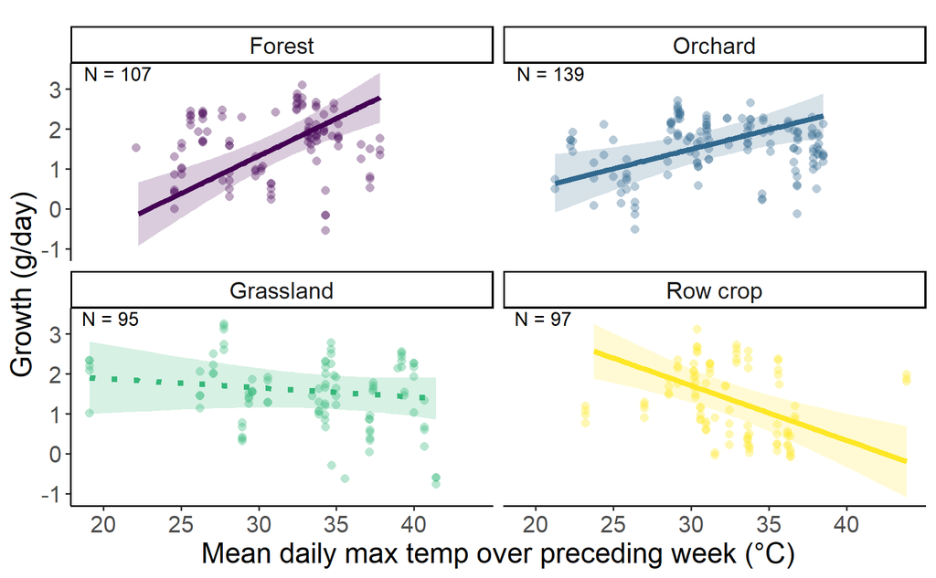

```r
samp <- g_lintemp@frame %>% group_by(habitat) %>% summarize(count = n())



dat_text_webl <- data.frame(
  label = paste("N =",samp$count),
  group   = factor(c("Forest","Orchard","Grassland","Row crop"))
)





data_webl = dplyr::filter(g,Species == "WEBL",!is.na(meanmaxtempI),!is.na(meanmintempI)) %>%
  mutate(across(c(gweight,meanmaxtempI,meanmintempI,juliandate,brood_size,age),
                                                  ~ scale(.x)[,1],
                                                   .names = "{.col}_scaled"),
                                           meanmaxtempI_scaled_sq = meanmaxtempI_scaled * meanmaxtempI_scaled)


mean_temp_webl <- mean(data_webl %>% pull(meanmaxtempI))
sd_temp_webl <- sd(data_webl %>% pull(meanmaxtempI))


temp_trans_webl <- trans_new("temp_trans_webl",
                          transform = function(x){(x * sd_temp_webl) + mean_temp_webl},
                          inverse = function(x){x})

(fig2_webl <- predict_response(prior_model,terms = c("meanmaxtempI_scaled [all]","habitat"),bias_correction = TRUE) %>%
   plot(line_size = 1.5,alpha = .2,show_data = TRUE,limit_range = TRUE) +
    aes(linetype = .data[["group"]]) +
    theme_classic() +
   facet_wrap(~ group, ncol = 2) +
    xlab("Mean daily max temp over preceding week (\u00b0C)") +
    ylab("Growth (g/day)") +
   scale_fill_viridis(discrete = TRUE) +
    scale_color_viridis(discrete = TRUE) +
    scale_linetype_manual(values = c("Forest" = "solid","Orchard" = "solid","Grassland" = "dotted","Row crop" = "solid")) +
    theme(text = element_text(size = 16)) +
    labs(title = element_blank()) +
    scale_x_continuous(trans = temp_trans_webl,
                       breaks = c((20-mean_temp_webl)/sd_temp_webl,
                                  (25-mean_temp_webl)/sd_temp_webl,
                                  (30-mean_temp_webl)/sd_temp_webl,
                                  (35-mean_temp_webl)/sd_temp_webl,
                                  (40-mean_temp_webl)/sd_temp_webl),
                       # breaks = c(20,30,40,50),
                       # labels = c("20","30","40","50"),
                       # limits = c((15-mean(g$meanmaxtempI,na.rm = TRUE))/sd(g$meanmaxtempI,na.rm = TRUE),
                       #            (55-mean(g$meanmaxtempI,na.rm = TRUE))/sd(g$meanmaxtempI,na.rm = TRUE))
                       # limits = c(18,5)
                       ) +
   #ylim(-5,5) +
   geom_text(data = dat_text_webl, mapping = aes(x = -Inf, y = Inf,label = label),hjust = -.2, vjust = 1.2,inherit.aes = FALSE) +
    theme(legend.position = "none")
   )
```

##### Plot of growth with interaction

```
G3;Data points may overlap. Use the `jitter` argument to add some amount of random variation to the
  location of data points and avoid overplotting.
gScale for colour is already present.
```

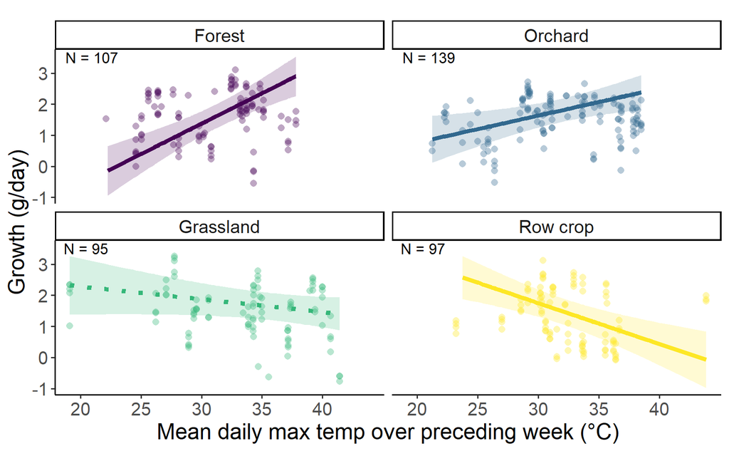

```r
(fig2_webl <- predict_response(g_lintemp,terms = c("meanmaxtempI_scaled [all]","habitat"),bias_correction = TRUE) %>%
   plot(line_size = 1.5,alpha = .2,show_data = TRUE,limit_range = TRUE) +
    aes(linetype = .data[["group"]]) +
    theme_classic() +
   facet_wrap(~ group, ncol = 2) +
    xlab("Mean daily max temp over preceding week (\u00b0C)") +
    ylab("Growth (g/day)") +
   scale_fill_viridis(discrete = TRUE) +
    scale_color_viridis(discrete = TRUE) +
    scale_linetype_manual(values = c("Forest" = "solid","Orchard" = "solid","Grassland" = "dotted","Row crop" = "solid")) +
    theme(text = element_text(size = 16)) +
    labs(title = element_blank()) +
    scale_x_continuous(trans = temp_trans_webl,
                       breaks = c((20-mean_temp_webl)/sd_temp_webl,
                                  (25-mean_temp_webl)/sd_temp_webl,
                                  (30-mean_temp_webl)/sd_temp_webl,
                                  (35-mean_temp_webl)/sd_temp_webl,
                                  (40-mean_temp_webl)/sd_temp_webl),
                       # breaks = c(20,30,40,50),
                       # labels = c("20","30","40","50"),
                       # limits = c((15-mean(g$meanmaxtempI,na.rm = TRUE))/sd(g$meanmaxtempI,na.rm = TRUE),
                       #            (55-mean(g$meanmaxtempI,na.rm = TRUE))/sd(g$meanmaxtempI,na.rm = TRUE))
                       # limits = c(18,5)
                       ) +
   #ylim(-5,5) +
   geom_text(data = dat_text_webl, mapping = aes(x = -Inf, y = Inf,label = label),hjust = -.2, vjust = 1.2,inherit.aes = FALSE) +
    theme(legend.position = "none")
   )
```

##### Visualize temp * juliandate interaction

```
G3;Data points may overlap. Use the `jitter` argument to add some amount of random variation to the
  location of data points and avoid overplotting.
g
```

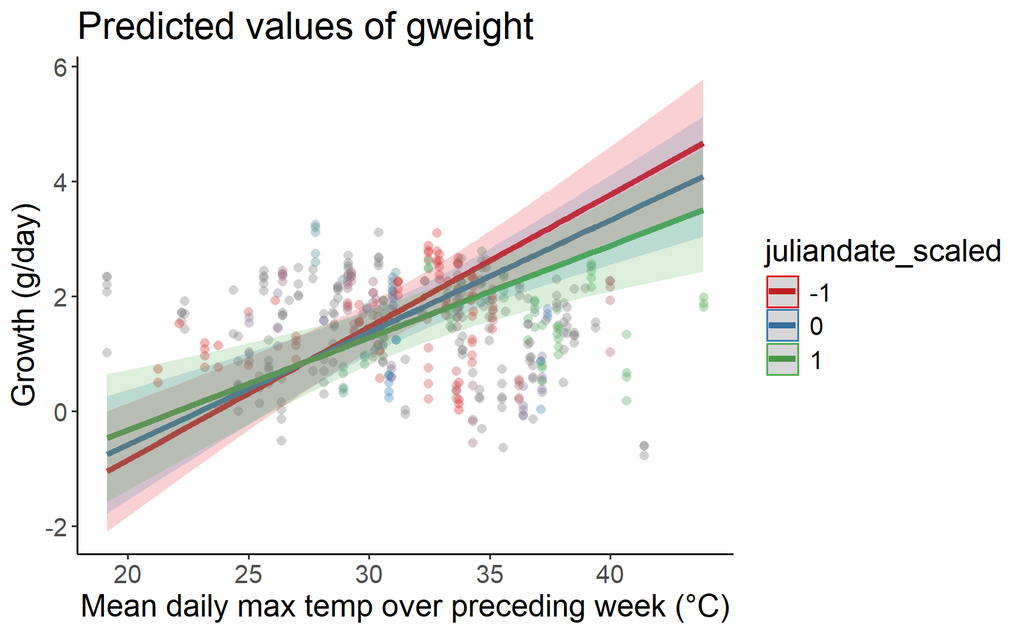

```r
(plott <- predict_response(g_lintemp,terms = c("meanmaxtempI_scaled [all]","juliandate_scaled"),bias_correction = TRUE) %>%
    plot(line_size = 1.5,alpha = .2,show_data = TRUE,limit_range = TRUE) +
    # aes(linetype = .data[["group"]]) +
    theme_classic() +
    # facet_wrap(~ group, ncol = 2) +
    xlab("Mean daily max temp over preceding week (\u00b0C)") +
    ylab("Growth (g/day)") +
    # scale_fill_viridis(discrete = TRUE) +
    # scale_color_viridis(discrete = TRUE) +
    # scale_linetype_manual(values = c("Forest" = "solid","Orchard" = "solid","Grassland" = "dotted","Row crop" = "solid")) +
    theme(text = element_text(size = 16)) +
    # labs(title = element_blank()) +
    scale_x_continuous(trans = temp_trans_webl,
                       breaks = c((20-mean_temp_webl)/sd_temp_webl,
                                  (25-mean_temp_webl)/sd_temp_webl,
                                  (30-mean_temp_webl)/sd_temp_webl,
                                  (35-mean_temp_webl)/sd_temp_webl,
                                  (40-mean_temp_webl)/sd_temp_webl),
                       # breaks = c(20,30,40,50),
                       # labels = c("20","30","40","50"),
                       # limits = c((15-mean(g$meanmaxtempI,na.rm = TRUE))/sd(g$meanmaxtempI,na.rm = TRUE),
                       #            (55-mean(g$meanmaxtempI,na.rm = TRUE))/sd(g$meanmaxtempI,na.rm = TRUE))
                       # limits = c(18,5)
    ) #+
    #ylim(-5,5) +
    # geom_text(data = dat_text_webl, mapping = aes(x = -Inf, y = Inf,label = label),hjust = -.2, vjust = 1.2,inherit.aes = FALSE) +
    # theme(legend.position = "none")
)
```

#### Conclusion: for WEBL growth, the interaction improves fit, but does not change growth results. In addition, the direction of interaction is opposite that expected: later in the season, hotter temps are worse for growth than in earlier season.

#### TRES

```r
prior_model <- lmerTest::lmer(gweight ~ meanmaxtempI_scaled * habitat + meanmintempI_scaled + age_scaled + juliandate_scaled + year_fct + (1|attempt_id),data = dplyr::filter(g,Species == "TRES",!is.na(meanmaxtempI),meanmaxtempI < 45,!is.na(meanmintempI)) %>%
  mutate(across(c(gweight,meanmaxtempI,meanmintempI,juliandate,brood_size,age),
                                                  ~ scale(.x)[,1],
                                                   .names = "{.col}_scaled"),
                                           meanmaxtempI_scaled_sq = meanmaxtempI_scaled * meanmaxtempI_scaled))

g_lintemp <- lmerTest::lmer(gweight ~ meanmaxtempI_scaled * habitat + meanmintempI_scaled * habitat + age_scaled + meanmaxtempI_scaled * juliandate_scaled + year_fct + (1|attempt_id),data = dplyr::filter(g,Species == "TRES",!is.na(meanmaxtempI),meanmaxtempI < 45,!is.na(meanmintempI)) %>%
  mutate(across(c(gweight,meanmaxtempI,meanmintempI,juliandate,brood_size,age),
                                                  ~ scale(.x)[,1],
                                                   .names = "{.col}_scaled"),
                                           meanmaxtempI_scaled_sq = meanmaxtempI_scaled * meanmaxtempI_scaled))

g_lintemp_addmax <- lmerTest::lmer(gweight ~ meanmaxtempI_scaled + meanmintempI_scaled * habitat + age_scaled + meanmaxtempI_scaled * juliandate_scaled + year_fct + (1|attempt_id),data = dplyr::filter(g,Species == "TRES",!is.na(meanmaxtempI),meanmaxtempI < 45,!is.na(meanmintempI)) %>%
  mutate(across(c(gweight,meanmaxtempI,meanmintempI,juliandate,brood_size,age),
                                                  ~ scale(.x)[,1],
                                                   .names = "{.col}_scaled"),
                                           meanmaxtempI_scaled_sq = meanmaxtempI_scaled * meanmaxtempI_scaled))

g_lintemp_addmin <- lmerTest::lmer(gweight ~ meanmaxtempI_scaled * habitat + meanmintempI_scaled + age_scaled + meanmaxtempI_scaled * juliandate_scaled + year_fct + (1|attempt_id),data = dplyr::filter(g,Species == "TRES",!is.na(meanmaxtempI),meanmaxtempI < 45,!is.na(meanmintempI)) %>%
  mutate(across(c(gweight,meanmaxtempI,meanmintempI,juliandate,brood_size,age),
                                                  ~ scale(.x)[,1],
                                                   .names = "{.col}_scaled"),
                                           meanmaxtempI_scaled_sq = meanmaxtempI_scaled * meanmaxtempI_scaled))

g_lintemp_noint <- lmerTest::lmer(gweight ~ meanmaxtempI_scaled + meanmintempI_scaled + habitat + age_scaled + meanmaxtempI_scaled * juliandate_scaled + year_fct + (1|attempt_id),data = dplyr::filter(g,Species == "TRES",!is.na(meanmaxtempI),meanmaxtempI < 45,!is.na(meanmintempI)) %>%
  mutate(across(c(gweight,meanmaxtempI,meanmintempI,juliandate,brood_size,age),
                                                  ~ scale(.x)[,1],
                                                   .names = "{.col}_scaled"),
                                           meanmaxtempI_scaled_sq = meanmaxtempI_scaled * meanmaxtempI_scaled))

c1 <- anova(g_lintemp,g_lintemp_addmin,g_lintemp_noint) %>% tibble() %>% mutate(Model = c("no interaction","single interaction","both interacting"),.before = npar)
```

```
G3;refitting model(s) with ML (instead of REML)
g
```

```r
c2 <- anova(g_lintemp,g_lintemp_addmax,g_lintemp_noint) %>% tibble() %>% mutate(Model = c("no interaction","single interaction","both interacting"),.before = npar)
```

```
G3;refitting model(s) with ML (instead of REML)
g
```

```r
(int_tab_growth_tres <- bind_rows(c1,c2) %>%
  as.tibble() %>%
  mutate(across(where(is.numeric),~round(.x,digits = 4)),
         P = `Pr(>Chisq)`) %>%
  dplyr::select(Model,AIC,Chisq,P) %>%
  mutate(max_or_min = c(rep("Max temp",times = 3),rep("Min temp",times = 3)),
         across(c(AIC,Chisq), ~ round(.x, digits = 2)),
         P = if_else(P < 0.001,"<0.001",as.character(P))) %>%
  group_by(max_or_min) %>% gt())
```

| Model | AIC | Chisq | P |
| --- | --- | --- | --- |
| Max temp |  |  |  |
| no interaction | 513.03 | NA | NA |
| single interaction | 478.45 | 40.58 | <0.001 |
| both interacting | 479.69 | 4.76 | 0.1904 |
| Min temp |  |  |  |
| no interaction | 513.03 | NA | NA |
| single interaction | 506.20 | 12.83 | 0.005 |
| both interacting | 479.69 | 32.51 | <0.001 |

```r
check_collinearity(g_lintemp_noint)
```

```
# Check for Multicollinearity

Low Correlation

                                  Term  VIF   VIF 95% CI Increased SE Tolerance Tolerance 95% CI
                   meanmaxtempI_scaled 2.04 [1.77, 2.40]         1.43      0.49     [0.42, 0.57]
                   meanmintempI_scaled 2.03 [1.76, 2.39]         1.42      0.49     [0.42, 0.57]
                               habitat 1.46 [1.30, 1.70]         1.21      0.69     [0.59, 0.77]
                            age_scaled 1.15 [1.06, 1.36]         1.07      0.87     [0.74, 0.94]
                     juliandate_scaled 1.41 [1.26, 1.64]         1.19      0.71     [0.61, 0.79]
                              year_fct 1.22 [1.12, 1.43]         1.11      0.82     [0.70, 0.90]
 meanmaxtempI_scaled:juliandate_scaled 1.17 [1.08, 1.38]         1.08      0.85     [0.72, 0.93]
```

```r
summary(g_lintemp_noint)
```

```
Linear mixed model fit by REML. t-tests use Satterthwaite's method ['lmerModLmerTest']
Formula: gweight ~ meanmaxtempI_scaled + meanmintempI_scaled + habitat +
    age_scaled + meanmaxtempI_scaled * juliandate_scaled + year_fct +      (1 | attempt_id)
   Data: dplyr::filter(g, Species == "TRES", !is.na(meanmaxtempI), meanmaxtempI <
    45, !is.na(meanmintempI)) %>% mutate(across(c(gweight, meanmaxtempI,
    meanmintempI, juliandate, brood_size, age), ~scale(.x)[,
    1], .names = "{.col}_scaled"), meanmaxtempI_scaled_sq = meanmaxtempI_scaled *      meanmaxtempI_scaled)

REML criterion at convergence: 521.7

Scaled residuals:
     Min       1Q   Median       3Q      Max
-2.77827 -0.53100  0.06156  0.49655  2.84200

Random effects:
 Groups     Name        Variance Std.Dev.
 attempt_id (Intercept) 0.1815   0.4260
 Residual               0.1774   0.4211
Number of obs: 347, groups:  attempt_id, 66

Fixed effects:
                                       Estimate Std. Error        df t value Pr(>|t|)
(Intercept)                             1.15264    0.20429  54.51447   5.642 6.19e-07 ***
meanmaxtempI_scaled                    -0.07990    0.06002 163.05828  -1.331   0.1850
meanmintempI_scaled                    -0.06395    0.07426  67.91584  -0.861   0.3922
habitatOrchard                          0.44707    0.24486  51.60549   1.826   0.0737 .
habitatGrassland                        0.04514    0.20986  56.02929   0.215   0.8305
habitatRow crop                         0.20571    0.21127  53.10778   0.974   0.3346
age_scaled                             -0.26283    0.03470 295.04507  -7.575 4.64e-13 ***
juliandate_scaled                      -0.02811    0.06836  63.70594  -0.411   0.6823
year_fct2022                            0.05051    0.13821  49.78715   0.365   0.7163
year_fct2023                            0.24889    0.16521  51.42231   1.506   0.1381
meanmaxtempI_scaled:juliandate_scaled  -0.02782    0.04725 230.11645  -0.589   0.5566
---
Signif. codes:  0 '***' 0.001 '**' 0.01 '*' 0.05 '.' 0.1 ' ' 1

Correlation of Fixed Effects:
            (Intr) mnmxI_ mnmnI_ hbttOr hbttGr hbttRc ag_scl jlndt_ y_2022 y_2023
mnmxtmpI_sc  0.240
mnmntmpI_sc -0.197 -0.574
habttOrchrd -0.628 -0.029  0.025
hbttGrsslnd -0.840 -0.367  0.299  0.586
habittRwcrp -0.758 -0.192  0.070  0.576  0.743
age_scaled   0.131  0.241 -0.268 -0.086 -0.136 -0.077
julndt_scld  0.073 -0.043 -0.317  0.030 -0.073 -0.064 -0.063
yer_fct2022 -0.363  0.047  0.017  0.064  0.022 -0.022 -0.155  0.035
yer_fct2023 -0.383  0.141 -0.017  0.032  0.121  0.051  0.017 -0.241  0.436
mnmxtmpI_:_ -0.195 -0.301  0.150  0.062  0.141  0.180 -0.040 -0.145 -0.088 -0.016
```

```r
g_lintemp_addmin_tres <- g_lintemp_addmin

(anova(g_lintemp_addmin,prior_model))
```

```
G3;refitting model(s) with ML (instead of REML)
g
```

```
Data: dplyr::filter(g, Species == "TRES", !is.na(meanmaxtempI), meanmaxtempI <  ...
Models:
prior_model: gweight ~ meanmaxtempI_scaled * habitat + meanmintempI_scaled + age_scaled + juliandate_scaled + year_fct + (1 | attempt_id)
g_lintemp_addmin: gweight ~ meanmaxtempI_scaled * habitat + meanmintempI_scaled + age_scaled + meanmaxtempI_scaled * juliandate_scaled + year_fct + (1 | attempt_id)
                 npar    AIC    BIC  logLik deviance  Chisq Df Pr(>Chisq)
prior_model        15 476.59 534.33 -223.29   446.59
g_lintemp_addmin   16 478.45 540.04 -223.23   446.45 0.1375  1     0.7107
```

For TRES growth, same model is significant. Interaction is not significant. Adding the interaction does not improve fit.

Do the results change?

##### Comparing temp trend and significance across land covers without and with temp * julian date interaction

```r
tresgrowthtrendmax_prior <- emtrends(prior_model,specs = ~ habitat, var = c("meanmaxtempI_scaled")) %>% test() %>%
   mutate(across(where(is.numeric), ~ round(.x, digits = 3)),
          df = round(df),
          p.value = if_else(p.value == 0.000,"<0.001",as.character(p.value))) %>%
   rename(Habitat = "habitat", `Max temp trend` = "meanmaxtempI_scaled.trend",Df = "df", `T-ratio` = "t.ratio", P = "p.value") %>%
   mutate(Model = "No temp * juliandate int") %>%
  gt()

tresgrowthtrendmax <- emtrends(g_lintemp_addmin,specs = ~ habitat, var = c("meanmaxtempI_scaled")) %>% test() %>%
   mutate(across(where(is.numeric), ~ round(.x, digits = 3)),
          df = round(df),
          p.value = if_else(p.value == 0.000,"<0.001",as.character(p.value))) %>%
   rename(Habitat = "habitat", `Max temp trend` = "meanmaxtempI_scaled.trend",Df = "df", `T-ratio` = "t.ratio", P = "p.value") %>%
    mutate(Model = "interaction") %>%
  gt()

(trend_comp <- tresgrowthtrendmax_prior %>% rbind(tresgrowthtrendmax) %>% gt())
```

[output not shown]

##### Plot of growth without interaction

```
G3;Data points may overlap. Use the `jitter` argument to add some amount of random variation to the
  location of data points and avoid overplotting.
gScale for colour is already present.
```

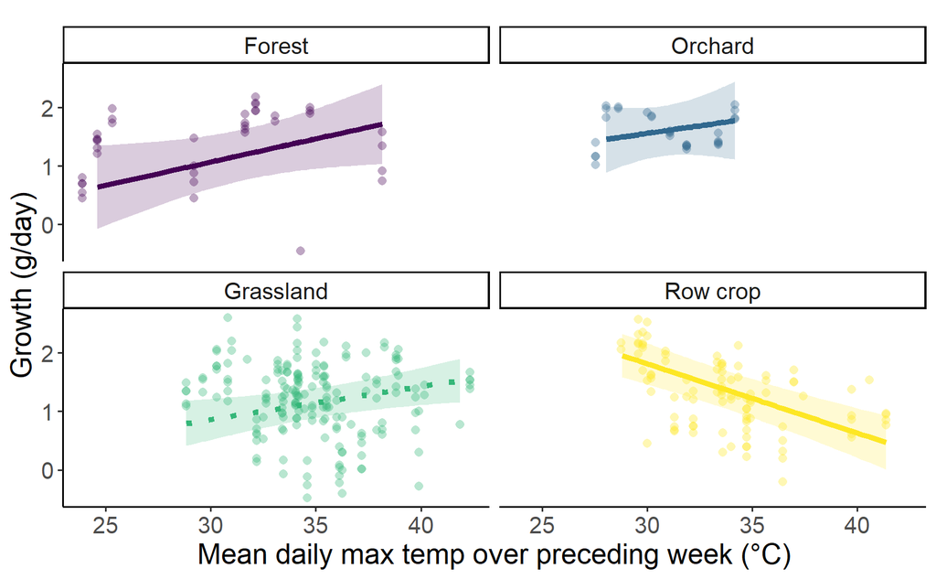

```r
samp <- g_lintemp_addmin@frame %>% group_by(habitat) %>% summarize(count = n())


dat_text_tres <- data.frame(
  label = paste("N =",samp$count),
  group   = factor(c("Forest","Orchard","Grassland","Row crop"))
)

data_tres = dplyr::filter(g,Species == "TRES",!is.na(meanmaxtempI),meanmaxtempI < 45,!is.na(meanmintempI)) %>%
  mutate(across(c(gweight,meanmaxtempI,meanmintempI,juliandate,brood_size,age),
                                                  ~ scale(.x)[,1],
                                                   .names = "{.col}_scaled"),
                                           meanmaxtempI_scaled_sq = meanmaxtempI_scaled * meanmaxtempI_scaled)


mean_temp_tres <- mean(data_tres %>% pull(meanmaxtempI))
sd_temp_tres <- sd(data_tres %>% pull(meanmaxtempI))


temp_trans_tres <- trans_new("temp_trans",
                          transform = function(x){(x * sd_temp_tres) + mean_temp_tres},
                          inverse = function(x){x})


(fig2_tres <- predict_response(prior_model,terms = c("meanmaxtempI_scaled [all]","habitat"),bias_correction = TRUE) %>%
   plot(line_size = 1.5,alpha = .2,show_data = TRUE,limit_range = TRUE) +
    aes(linetype = .data[["group"]]) +
    theme_classic() +
   facet_wrap(~ group, ncol = 2) +
    xlab("Mean daily max temp over preceding week (\u00b0C)") +
    ylab("Growth (g/day)") +
   scale_fill_viridis(discrete = TRUE) +
    scale_color_viridis(discrete = TRUE) +
    scale_linetype_manual(values = c("Forest" = "solid","Orchard" = "solid","Grassland" = "dotted","Row crop" = "solid")) +
    theme(text = element_text(size = 16)) +
    labs(title = element_blank()) +
    scale_x_continuous(trans = temp_trans_tres,
                       breaks = c((20-mean_temp_tres)/sd_temp_tres,
                                  (25-mean_temp_tres)/sd_temp_tres,
                                  (30-mean_temp_tres)/sd_temp_tres,
                                  (35-mean_temp_tres)/sd_temp_tres,
                                  (40-mean_temp_tres)/sd_temp_tres),
                       # breaks = c(20,30,40,50),
                       # labels = c("20","30","40","50"),
                       # limits = c((15-mean(g$meanmaxtempI,na.rm = TRUE))/sd(g$meanmaxtempI,na.rm = TRUE),
                       #            (55-mean(g$meanmaxtempI,na.rm = TRUE))/sd(g$meanmaxtempI,na.rm = TRUE))
                       # limits = c(18,5)
                       ) +
   #ylim(-5,5) +
   #geom_text(data = dat_text_tres, mapping = aes(x = -Inf, y = Inf,label = label),hjust = -.2, vjust = 1.2,inherit.aes = FALSE) +
    theme(legend.position = "none")
   )
```

##### Plot of growth with interaction

```
G3;Data points may overlap. Use the `jitter` argument to add some amount of random variation to the
  location of data points and avoid overplotting.
gScale for colour is already present.
```

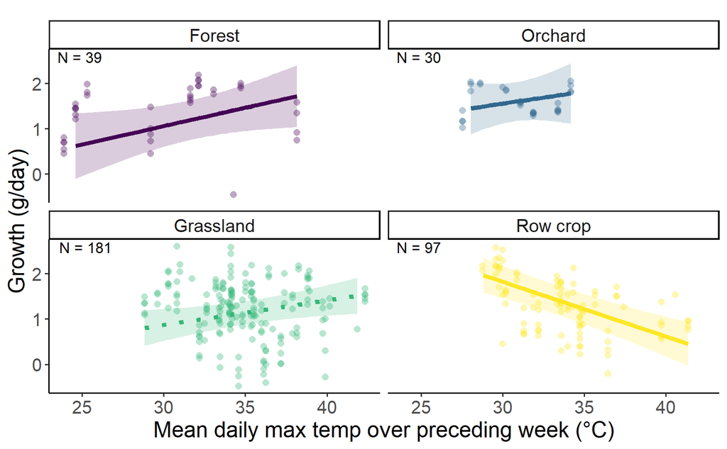

```r
(fig2_tres <- predict_response(g_lintemp_addmin,terms = c("meanmaxtempI_scaled [all]","habitat"),bias_correction = TRUE) %>%
   plot(line_size = 1.5,alpha = .2,show_data = TRUE,limit_range = TRUE) +
    aes(linetype = .data[["group"]]) +
    theme_classic() +
   facet_wrap(~ group, ncol = 2) +
    xlab("Mean daily max temp over preceding week (\u00b0C)") +
    ylab("Growth (g/day)") +
   scale_fill_viridis(discrete = TRUE) +
    scale_color_viridis(discrete = TRUE) +
    scale_linetype_manual(values = c("Forest" = "solid","Orchard" = "solid","Grassland" = "dotted","Row crop" = "solid")) +
    theme(text = element_text(size = 16)) +
    labs(title = element_blank()) +
    scale_x_continuous(trans = temp_trans_tres,
                       breaks = c((20-mean_temp_tres)/sd_temp_tres,
                                  (25-mean_temp_tres)/sd_temp_tres,
                                  (30-mean_temp_tres)/sd_temp_tres,
                                  (35-mean_temp_tres)/sd_temp_tres,
                                  (40-mean_temp_tres)/sd_temp_tres),
                       # breaks = c(20,30,40,50),
                       # labels = c("20","30","40","50"),
                       # limits = c((15-mean(g$meanmaxtempI,na.rm = TRUE))/sd(g$meanmaxtempI,na.rm = TRUE),
                       #            (55-mean(g$meanmaxtempI,na.rm = TRUE))/sd(g$meanmaxtempI,na.rm = TRUE))
                       # limits = c(18,5)
                       ) +
   #ylim(-5,5) +
   geom_text(data = dat_text_tres, mapping = aes(x = -Inf, y = Inf,label = label),hjust = -.2, vjust = 1.2,inherit.aes = FALSE) +
    theme(legend.position = "none")
   )
```

##### Visualize temp * juliandate interaction

```
G3;Data points may overlap. Use the `jitter` argument to add some amount of random variation to the
  location of data points and avoid overplotting.
g
```

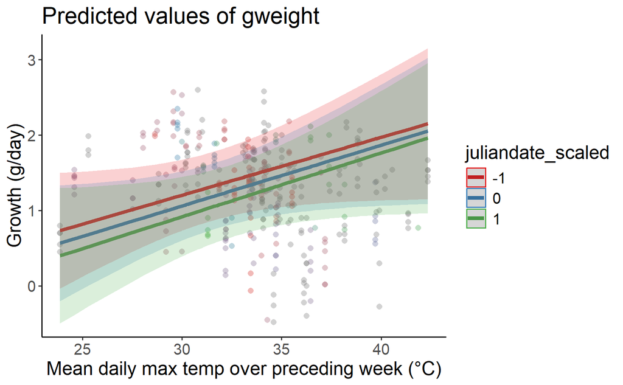

```r
(plott <- predict_response(g_lintemp_addmin,terms = c("meanmaxtempI_scaled [all]","juliandate_scaled"),bias_correction = TRUE) %>%
    plot(line_size = 1.5,alpha = .2,show_data = TRUE,limit_range = TRUE) +
    # aes(linetype = .data[["group"]]) +
    theme_classic() +
    # facet_wrap(~ group, ncol = 2) +
    xlab("Mean daily max temp over preceding week (\u00b0C)") +
    ylab("Growth (g/day)") +
    # scale_fill_viridis(discrete = TRUE) +
    # scale_color_viridis(discrete = TRUE) +
    # scale_linetype_manual(values = c("Forest" = "solid","Orchard" = "solid","Grassland" = "dotted","Row crop" = "solid")) +
    theme(text = element_text(size = 16)) +
    # labs(title = element_blank()) +
    scale_x_continuous(trans = temp_trans_tres,
                       breaks = c((20-mean_temp_tres)/sd_temp_tres,
                                  (25-mean_temp_tres)/sd_temp_tres,
                                  (30-mean_temp_tres)/sd_temp_tres,
                                  (35-mean_temp_tres)/sd_temp_tres,
                                  (40-mean_temp_tres)/sd_temp_tres),
                       # breaks = c(20,30,40,50),
                       # labels = c("20","30","40","50"),
                       # limits = c((15-mean(g$meanmaxtempI,na.rm = TRUE))/sd(g$meanmaxtempI,na.rm = TRUE),
                       #            (55-mean(g$meanmaxtempI,na.rm = TRUE))/sd(g$meanmaxtempI,na.rm = TRUE))
                       # limits = c(18,5)
    ) #+
    #ylim(-5,5) +
    # geom_text(data = dat_text_tres, mapping = aes(x = -Inf, y = Inf,label = label),hjust = -.2, vjust = 1.2,inherit.aes = FALSE) +
    # theme(legend.position = "none")
)
```

#### Conclusion: for TRES growth, the interaction neither improves fit nor changes the results. There does not appear to be an interaction between juliandate and max temperature for TRES growth.

### Survival

#### WEBL

```r
prior_model <- glm(cbind(nest_fledged,clutch_size - nest_fledged) ~ meanmaxt_nestpd_scaled * habitat + meanmint_nestpd_scaled + juliandate_hatch_scaled + year_fct + site,
                            family = binomial(link = "logit"),
                            data = dplyr::filter(s,
                                                 Species == "WEBL",
                                                 !is.na(nest_fledged),
                                                 !is.na(clutch_size)) %>%
                              mutate(across(c(meanmaxt_nestpd,meanmint_nestpd,juliandate_hatch),
                                            ~ scale(.x)[,1],
                                            .names = "{.col}_scaled")
                              )
)

s_nestpd_WEBL <- glm(cbind(nest_fledged,clutch_size - nest_fledged) ~ meanmaxt_nestpd_scaled * habitat + meanmint_nestpd_scaled * habitat + meanmaxt_nestpd_scaled * juliandate_hatch_scaled + year_fct + site,
                     family = binomial(link = "logit"),
                     data = dplyr::filter(s,
                                          Species == "WEBL",
                                          !is.na(nest_fledged),
                                          !is.na(clutch_size)) %>%
                       mutate(across(c(meanmaxt_nestpd,meanmint_nestpd,juliandate_hatch),
                                     ~ scale(.x)[,1],
                                     .names = "{.col}_scaled")
                       )
)

s_nestpd_WEBL_addmax <- glm(cbind(nest_fledged,clutch_size - nest_fledged) ~ meanmaxt_nestpd_scaled + meanmint_nestpd_scaled * habitat + meanmaxt_nestpd_scaled * juliandate_hatch_scaled + year_fct + site,
                            family = binomial(link = "logit"),
                            data = dplyr::filter(s,
                                                 Species == "WEBL",
                                                 !is.na(nest_fledged),
                                                 !is.na(clutch_size)) %>%
                              mutate(across(c(meanmaxt_nestpd,meanmint_nestpd,juliandate_hatch),
                                            ~ scale(.x)[,1],
                                            .names = "{.col}_scaled")
                              )
)

s_nestpd_WEBL_addmin <- glm(cbind(nest_fledged,clutch_size - nest_fledged) ~ meanmaxt_nestpd_scaled * habitat + meanmint_nestpd_scaled + meanmaxt_nestpd_scaled * juliandate_hatch_scaled + year_fct + site,
                            family = binomial(link = "logit"),
                            data = dplyr::filter(s,
                                                 Species == "WEBL",
                                                 !is.na(nest_fledged),
                                                 !is.na(clutch_size)) %>%
                              mutate(across(c(meanmaxt_nestpd,meanmint_nestpd,juliandate_hatch),
                                            ~ scale(.x)[,1],
                                            .names = "{.col}_scaled")
                              )
)
s_nestpd_WEBL_noint <- glm(cbind(nest_fledged,clutch_size - nest_fledged) ~ meanmaxt_nestpd_scaled + meanmint_nestpd_scaled + habitat + meanmaxt_nestpd_scaled * juliandate_hatch_scaled + year_fct + site,
                           family = binomial(link = "logit"),
                           data = dplyr::filter(s,
                                                Species == "WEBL",
                                                !is.na(nest_fledged),
                                                !is.na(clutch_size)) %>%
                             mutate(across(c(meanmaxt_nestpd,meanmint_nestpd,juliandate_hatch),
                                           ~ scale(.x)[,1],
                                           .names = "{.col}_scaled")
                             )
)

c1 <- anova(s_nestpd_WEBL,s_nestpd_WEBL_addmin,s_nestpd_WEBL_noint,test="Chisq") %>% tibble() %>%
  rename(Chisq = Deviance) %>%
  mutate(AIC = c(AIC(s_nestpd_WEBL),AIC(s_nestpd_WEBL_addmin),AIC(s_nestpd_WEBL_noint)),.before = Df) %>%
  mutate(Model = c("no interaction","single interaction","both interacting"),.before = Df)

c2 <- anova(s_nestpd_WEBL,s_nestpd_WEBL_addmax,s_nestpd_WEBL_noint,test="Chisq") %>% tibble() %>%
  rename(Chisq = Deviance) %>%
  mutate(AIC = c(AIC(s_nestpd_WEBL),
                 AIC(s_nestpd_WEBL_addmax),
                 AIC(s_nestpd_WEBL_noint)),.before = Df) %>%
  mutate(Model = c("no interaction","single interaction","both interacting"),.before = Df)

(int_tab_survival_nestpd_webl <- bind_rows(c1,c2) %>%
    as_tibble() %>%
    mutate(across(where(is.numeric),~round(.x,digits = 4)),
           P = `Pr(>Chi)`) %>%
    dplyr::select(Model,AIC,Chisq,P) %>%
    mutate(max_or_min = c(rep("Max temp",times = 3),rep("Min temp",times = 3)),
           across(c(Chisq), ~ round(.x, digits = 2)),
           P = if_else(P < 0.001,"<0.001",as.character(P))) %>%
    group_by(max_or_min) %>% gt())
```

| Model | AIC | Chisq | P |
| --- | --- | --- | --- |
| Max temp |  |  |  |
| no interaction | 319.0342 | NA | NA |
| single interaction | 320.0632 | -7.03 | 0.071 |
| both interacting | 314.9549 | -0.89 | 0.8274 |
| Min temp |  |  |  |
| no interaction | 319.0342 | NA | NA |
| single interaction | 319.7139 | -6.68 | 0.0828 |
| both interacting | 314.9549 | -1.24 | 0.7432 |

```r
# gtsave(int_tab_survival_nestpd_webl,"figures/int_tab_survival_nestpd_webl.html")



#Conclusion: For nest attempt overall, land cover interacts with either max or min temp but not both together. It looks like the max temp interaction model is slightly more explanatory so we'll go with that.


summary(s_nestpd_WEBL_addmin)
```

```
Call:
glm(formula = cbind(nest_fledged, clutch_size - nest_fledged) ~
    meanmaxt_nestpd_scaled * habitat + meanmint_nestpd_scaled +
        meanmaxt_nestpd_scaled * juliandate_hatch_scaled + year_fct +
        site, family = binomial(link = "logit"), data = dplyr::filter(s,
    Species == "WEBL", !is.na(nest_fledged), !is.na(clutch_size)) %>%
    mutate(across(c(meanmaxt_nestpd, meanmint_nestpd, juliandate_hatch),
        ~scale(.x)[, 1], .names = "{.col}_scaled")))

Coefficients:
                                                Estimate Std. Error z value Pr(>|z|)
(Intercept)                                     0.000244   0.433466   0.001 0.999551
meanmaxt_nestpd_scaled                         -0.645886   0.337151  -1.916 0.055401 .
habitatOrchard                                  1.700254   0.441699   3.849 0.000118 ***
habitatGrassland                                2.610218   0.522510   4.996 5.87e-07 ***
habitatRow crop                                 1.512034   0.409349   3.694 0.000221 ***
meanmint_nestpd_scaled                          0.452489   0.263654   1.716 0.086122 .
juliandate_hatch_scaled                        -0.016409   0.274881  -0.060 0.952399
year_fct2022                                   -0.239180   0.415544  -0.576 0.564897
year_fct2023                                   -1.130950   0.474165  -2.385 0.017073 *
sitePG                                          0.435061   0.357239   1.218 0.223283
siteRR                                          0.334349   0.381945   0.875 0.381365
siteWI                                         -0.708859   0.563649  -1.258 0.208527
meanmaxt_nestpd_scaled:habitatOrchard           0.082738   0.309438   0.267 0.789174
meanmaxt_nestpd_scaled:habitatGrassland         0.340118   0.404784   0.840 0.400771
meanmaxt_nestpd_scaled:habitatRow crop         -0.034385   0.440675  -0.078 0.937806
meanmaxt_nestpd_scaled:juliandate_hatch_scaled -0.185452   0.161162  -1.151 0.249849
---
Signif. codes:  0 '***' 0.001 '**' 0.01 '*' 0.05 '.' 0.1 ' ' 1

(Dispersion parameter for binomial family taken to be 1)

    Null deviance: 282.86  on 83  degrees of freedom
Residual deviance: 206.66  on 68  degrees of freedom
AIC: 320.06

Number of Fisher Scoring iterations: 4
```

```r
anova(s_nestpd_WEBL_addmin, prior_model)
```

```
Analysis of Deviance Table

Model 1: cbind(nest_fledged, clutch_size - nest_fledged) ~ meanmaxt_nestpd_scaled *
    habitat + meanmint_nestpd_scaled + meanmaxt_nestpd_scaled *
    juliandate_hatch_scaled + year_fct + site
Model 2: cbind(nest_fledged, clutch_size - nest_fledged) ~ meanmaxt_nestpd_scaled *
    habitat + meanmint_nestpd_scaled + juliandate_hatch_scaled +
    year_fct + site
  Resid. Df Resid. Dev Df Deviance Pr(>Chi)
1        68     206.66
2        69     207.98 -1  -1.3199   0.2506
```

Interaction does not improve model fit for survival.

Do the results change?

##### Comparing temp trend and significance across land covers without and with temp * julian date interaction

```r
(weblsurvival_nestpd_trendmax_prior <- emtrends(prior_model,specs = pairwise ~ habitat, var = c("meanmaxt_nestpd_scaled")) %>% test() %>% pluck("emtrends") %>%
   mutate(across(where(is.numeric), ~ round(.x, digits = 3)),
          df = round(df),
          p.value = if_else(p.value == 0.000,"<0.001",as.character(p.value))) %>%
   rename(Habitat = "habitat", `Max temp trend` = "meanmaxt_nestpd_scaled.trend",Df = "df", `T-ratio` = "z.ratio", P = "p.value") %>%
   gt())
```

| Habitat | Max temp trend | SE | Df | T-ratio | P |
| --- | --- | --- | --- | --- | --- |
| Forest | -0.586 | 0.330 | Inf | -1.775 | 0.076 |
| Orchard | -0.586 | 0.348 | Inf | -1.683 | 0.092 |
| Grassland | -0.370 | 0.356 | Inf | -1.040 | 0.298 |
| Row crop | -0.747 | 0.439 | Inf | -1.703 | 0.088 |

```r
(weblsurvival_nestpd_trendmax <- emtrends(s_nestpd_WEBL_addmin,specs = pairwise ~ habitat, var = c("meanmaxt_nestpd_scaled")) %>% test() %>% pluck("emtrends") %>%
   mutate(across(where(is.numeric), ~ round(.x, digits = 3)),
          df = round(df),
          p.value = if_else(p.value == 0.000,"<0.001",as.character(p.value))) %>%
   rename(Habitat = "habitat", `Max temp trend` = "meanmaxt_nestpd_scaled.trend",Df = "df", `T-ratio` = "z.ratio", P = "p.value") %>%
   gt())
```

| Habitat | Max temp trend | SE | Df | T-ratio | P |
| --- | --- | --- | --- | --- | --- |
| Forest | -0.646 | 0.337 | Inf | -1.916 | 0.055 |
| Orchard | -0.563 | 0.348 | Inf | -1.618 | 0.106 |
| Grassland | -0.306 | 0.364 | Inf | -0.839 | 0.401 |
| Row crop | -0.680 | 0.442 | Inf | -1.538 | 0.124 |

Forest trend becomes slightly more significant with the addition of the interaction

##### Plot of survival without interaction

```
G3;Raw data not available.
gScale for colour is already present.
```

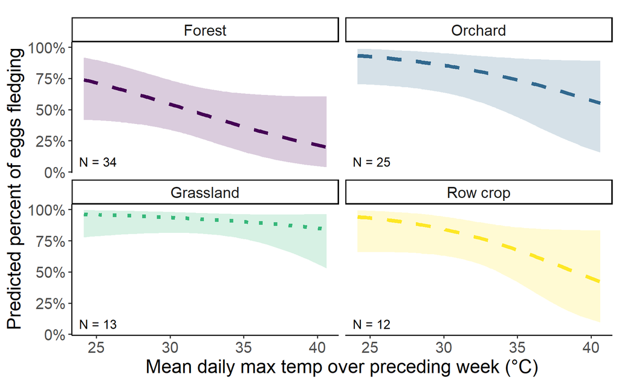

```r
data_webl = s_nestpd_WEBL_addmin$data


mean_temp_webl <- mean(data_webl %>% pull(meanmaxt_nestpd),na.rm = TRUE)
sd_temp_webl <- sd(data_webl %>% pull(meanmaxt_nestpd),na.rm = TRUE)


temp_trans_webl <- trans_new("temp_trans_webl",
                          transform = function(x){(x * sd_temp_webl) + mean_temp_webl},
                          inverse = function(x){x})

samp_webl <- data_webl %>% group_by(habitat) %>% summarize(count = n())
# samp %>% gt() %>% gtsave("../figures/ss_webl.html")


dat_text_webl <- data.frame(
  label = paste("N =",samp_webl$count),
  group   = factor(samp_webl$habitat)
)

(fig3_webl <- predict_response(prior_model,terms = c("meanmaxt_nestpd_scaled [all]","habitat")) %>%
   plot(line_size = 1.5,alpha = .2,show_data = TRUE,limit_range = TRUE) +
    aes(linetype = .data[["group"]]) +
    theme_classic() +
   facet_wrap(~ group, ncol = 2) +
    xlab("Mean daily max temp over preceding week (\u00b0C)") +
    ylab("Predicted percent of eggs fledging") +
   scale_fill_viridis(discrete = TRUE) +
    scale_color_viridis(discrete = TRUE) +
    theme(text = element_text(size = 16)) +
    labs(title = element_blank()) +
   scale_x_continuous(trans = temp_trans_webl,
                       breaks = c((20-mean_temp_webl)/sd_temp_webl,
                                  (25-mean_temp_webl)/sd_temp_webl,
                                  (30-mean_temp_webl)/sd_temp_webl,
                                  (35-mean_temp_webl)/sd_temp_webl,
                                  (40-mean_temp_webl)/sd_temp_webl#,
                                  #(45-mean_temp)/sd_temp
                                  ),
                       # breaks = c(20,30,40,50),
                       # labels = c("20","30","40","50"),
                       # limits = c((15-mean(g$meanmaxtempI,na.rm = TRUE))/sd(g$meanmaxtempI,na.rm = TRUE),
                       #            (55-mean(g$meanmaxtempI,na.rm = TRUE))/sd(g$meanmaxtempI,na.rm = TRUE))
                       # limits = c(18,5)
                       ) +
   # ylim(0,100) +
   scale_linetype_manual(values = c("Forest" = "dashed","Orchard" = "dashed","Grassland" = "dotted","Row crop" = "dashed")) +
   geom_text(data = dat_text_webl, mapping = aes(x = -Inf, y = -Inf,label = label),hjust = -.2,vjust = -.7,inherit.aes = FALSE) +
    theme(legend.position = "none")
   )
```

##### With interaction

```
G3;Raw data not available.
gScale for colour is already present.
```

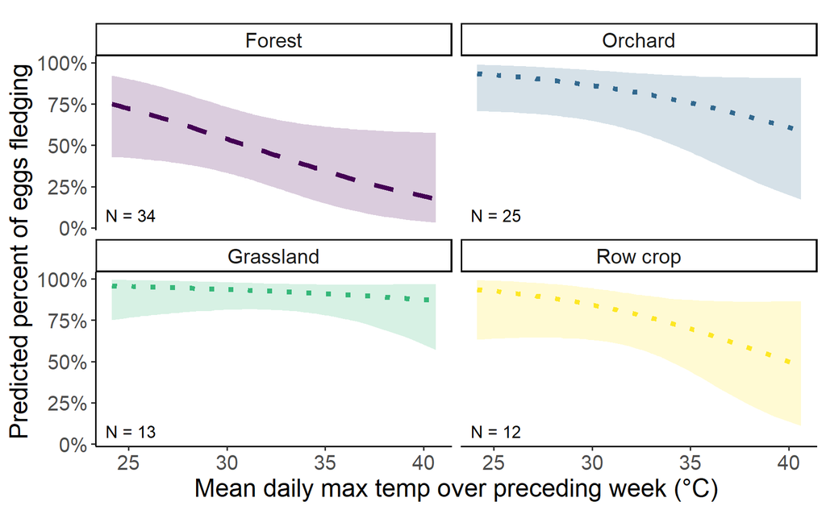

```r
(fig3_webl <- predict_response(s_nestpd_WEBL_addmin,terms = c("meanmaxt_nestpd_scaled [all]","habitat")) %>%
   plot(line_size = 1.5,alpha = .2,show_data = TRUE,limit_range = TRUE) +
    aes(linetype = .data[["group"]]) +
    theme_classic() +
   facet_wrap(~ group, ncol = 2) +
    xlab("Mean daily max temp over preceding week (\u00b0C)") +
    ylab("Predicted percent of eggs fledging") +
   scale_fill_viridis(discrete = TRUE) +
    scale_color_viridis(discrete = TRUE) +
    theme(text = element_text(size = 16)) +
    labs(title = element_blank()) +
   scale_x_continuous(trans = temp_trans_webl,
                       breaks = c((20-mean_temp_webl)/sd_temp_webl,
                                  (25-mean_temp_webl)/sd_temp_webl,
                                  (30-mean_temp_webl)/sd_temp_webl,
                                  (35-mean_temp_webl)/sd_temp_webl,
                                  (40-mean_temp_webl)/sd_temp_webl#,
                                  #(45-mean_temp)/sd_temp
                                  ),
                       # breaks = c(20,30,40,50),
                       # labels = c("20","30","40","50"),
                       # limits = c((15-mean(g$meanmaxtempI,na.rm = TRUE))/sd(g$meanmaxtempI,na.rm = TRUE),
                       #            (55-mean(g$meanmaxtempI,na.rm = TRUE))/sd(g$meanmaxtempI,na.rm = TRUE))
                       # limits = c(18,5)
                       ) +
   # ylim(0,100) +
   scale_linetype_manual(values = c("Forest" = "dashed","Orchard" = "dotted","Grassland" = "dotted","Row crop" = "dotted")) +
   geom_text(data = dat_text_webl, mapping = aes(x = -Inf, y = -Inf,label = label),hjust = -.2,vjust = -.7,inherit.aes = FALSE) +
    theme(legend.position = "none")
   )
```

##### Visualize direction of interaction

```
G3;Bias-correction is currently only supported for mixed or gee models. No bias-correction is applied.
gG3;Raw data not available.
g
```

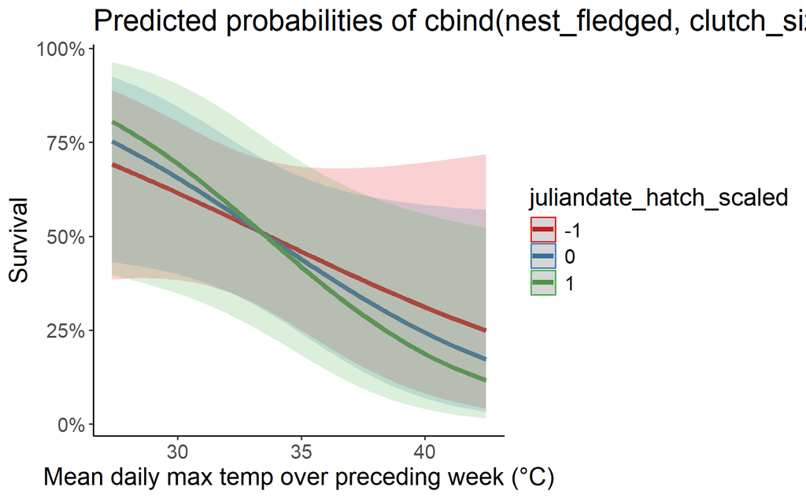

```r
(plott <- predict_response(s_nestpd_WEBL_addmin,terms = c("meanmaxt_nestpd_scaled [all]","juliandate_hatch_scaled"),bias_correction = TRUE) %>%
    plot(line_size = 1.5,alpha = .2,show_data = TRUE,limit_range = TRUE) +
    # aes(linetype = .data[["group"]]) +
    theme_classic() +
    # facet_wrap(~ group, ncol = 2) +
    xlab("Mean daily max temp over preceding week (\u00b0C)") +
    ylab("Survival") +
    # scale_fill_viridis(discrete = TRUE) +
    # scale_color_viridis(discrete = TRUE) +
    # scale_linetype_manual(values = c("Forest" = "solid","Orchard" = "solid","Grassland" = "dotted","Row crop" = "solid")) +
    theme(text = element_text(size = 16)) +
    # labs(title = element_blank()) +
    scale_x_continuous(trans = temp_trans_tres,
                       breaks = c((20-mean_temp_tres)/sd_temp_tres,
                                  (25-mean_temp_tres)/sd_temp_tres,
                                  (30-mean_temp_tres)/sd_temp_tres,
                                  (35-mean_temp_tres)/sd_temp_tres,
                                  (40-mean_temp_tres)/sd_temp_tres),
                       # breaks = c(20,30,40,50),
                       # labels = c("20","30","40","50"),
                       # limits = c((15-mean(g$meanmaxtempI,na.rm = TRUE))/sd(g$meanmaxtempI,na.rm = TRUE),
                       #            (55-mean(g$meanmaxtempI,na.rm = TRUE))/sd(g$meanmaxtempI,na.rm = TRUE))
                       # limits = c(18,5)
    ) #+
    #ylim(-5,5) +
    # geom_text(data = dat_text_tres, mapping = aes(x = -Inf, y = Inf,label = label),hjust = -.2, vjust = 1.2,inherit.aes = FALSE) +
    # theme(legend.position = "none")
)
```

#### TRES

```r
prior_model <- glm(cbind(nest_fledged,clutch_size - nest_fledged) ~ meanmaxt_nestpd_scaled + meanmint_nestpd_scaled + habitat + juliandate_hatch_scaled + year_fct + site,
                           family = binomial(link = "logit"),
                           data = dplyr::filter(s,
                                                Species == "TRES",
                                                !is.na(nest_fledged),
                                                !is.na(clutch_size)) %>%
                             mutate(across(c(meanmaxt_nestpd,meanmint_nestpd,juliandate_hatch),
                                           ~ scale(.x)[,1],
                                           .names = "{.col}_scaled")
                             )
)

s_nestpd_TRES <- glm(cbind(nest_fledged,clutch_size - nest_fledged) ~ meanmaxt_nestpd_scaled * habitat + meanmint_nestpd_scaled * habitat + meanmaxt_nestpd_scaled * juliandate_hatch_scaled + year_fct + site,
                     family = binomial(link = "logit"),
                     data = dplyr::filter(s,
                                          Species == "TRES",
                                          !is.na(nest_fledged),
                                          !is.na(clutch_size)) %>%
                       mutate(across(c(meanmaxt_nestpd,meanmint_nestpd,juliandate_hatch),
                                     ~ scale(.x)[,1],
                                     .names = "{.col}_scaled")
                       )
)

s_nestpd_TRES_addmax <- glm(cbind(nest_fledged,clutch_size - nest_fledged) ~ meanmaxt_nestpd_scaled + meanmint_nestpd_scaled * habitat + meanmaxt_nestpd_scaled * juliandate_hatch_scaled + year_fct + site,
                            family = binomial(link = "logit"),
                            data = dplyr::filter(s,
                                                 Species == "TRES",
                                                 !is.na(nest_fledged),
                                                 !is.na(clutch_size)) %>%
                              mutate(across(c(meanmaxt_nestpd,meanmint_nestpd,juliandate_hatch),
                                            ~ scale(.x)[,1],
                                            .names = "{.col}_scaled")
                              )
)

s_nestpd_TRES_addmin <- glm(cbind(nest_fledged,clutch_size - nest_fledged) ~ meanmaxt_nestpd_scaled * habitat + meanmint_nestpd_scaled + meanmaxt_nestpd_scaled * juliandate_hatch_scaled + year_fct + site,
                            family = binomial(link = "logit"),
                            data = dplyr::filter(s,
                                                 Species == "TRES",
                                                 !is.na(nest_fledged),
                                                 !is.na(clutch_size)) %>%
                              mutate(across(c(meanmaxt_nestpd,meanmint_nestpd,juliandate_hatch),
                                            ~ scale(.x)[,1],
                                            .names = "{.col}_scaled")
                              )
)
s_nestpd_TRES_noint <- glm(cbind(nest_fledged,clutch_size - nest_fledged) ~ meanmaxt_nestpd_scaled + meanmint_nestpd_scaled + habitat + meanmaxt_nestpd_scaled * juliandate_hatch_scaled + year_fct + site,
                           family = binomial(link = "logit"),
                           data = dplyr::filter(s,
                                                Species == "TRES",
                                                !is.na(nest_fledged),
                                                !is.na(clutch_size)) %>%
                             mutate(across(c(meanmaxt_nestpd,meanmint_nestpd,juliandate_hatch),
                                           ~ scale(.x)[,1],
                                           .names = "{.col}_scaled")
                             )
)

c1 <- anova(s_nestpd_TRES,s_nestpd_TRES_addmin,s_nestpd_TRES_noint,test="Chisq") %>% tibble() %>%
  rename(Chisq = Deviance) %>%
  mutate(AIC = c(AIC(s_nestpd_TRES),AIC(s_nestpd_TRES_addmin),AIC(s_nestpd_TRES_noint)),.before = Df) %>%
  mutate(Model = c("no interaction","single interaction","both interacting"),.before = Df)

c2 <- anova(s_nestpd_TRES,s_nestpd_TRES_addmax,s_nestpd_TRES_noint,test="Chisq") %>% tibble() %>%
  rename(Chisq = Deviance) %>%
  mutate(AIC = c(AIC(s_nestpd_TRES),
                 AIC(s_nestpd_TRES_addmax),
                 AIC(s_nestpd_TRES_noint)),.before = Df) %>%
  mutate(Model = c("no interaction","single interaction","both interacting"),.before = Df)

(int_tab_survival_nestpd_tres <- bind_rows(c1,c2) %>%
    as_tibble() %>%
    mutate(across(where(is.numeric),~round(.x,digits = 4)),
           P = `Pr(>Chi)`) %>%
    dplyr::select(Model,AIC,Chisq,P) %>%
    mutate(max_or_min = c(rep("Max temp",times = 3),rep("Min temp",times = 3)),
           across(c(Chisq), ~ round(.x, digits = 2)),
           P = if_else(P < 0.001,"<0.001",as.character(P))) %>%
    group_by(max_or_min) %>% gt())
```

| Model | AIC | Chisq | P |
| --- | --- | --- | --- |
| Max temp |  |  |  |
| no interaction | 238.4467 | NA | NA |
| single interaction | 233.4696 | -1.02 | 0.7957 |
| both interacting | 230.7602 | -3.29 | 0.349 |
| Min temp |  |  |  |
| no interaction | 238.4467 | NA | NA |
| single interaction | 234.8721 | -2.43 | 0.4889 |
| both interacting | 230.7602 | -1.89 | 0.596 |

```r
# gtsave(int_tab_survival_nestpd_tres,"figures/int_tab_survival_nestpd_tres.html")



#Conclusion: For nest attempt overall, land cover interacts with either max or min temp but not both together. It looks like the max temp interaction model is slightly more explanatory so we'll go with that.


summary(s_nestpd_TRES_noint)
```

```
Call:
glm(formula = cbind(nest_fledged, clutch_size - nest_fledged) ~
    meanmaxt_nestpd_scaled + meanmint_nestpd_scaled + habitat +
        meanmaxt_nestpd_scaled * juliandate_hatch_scaled + year_fct +
        site, family = binomial(link = "logit"), data = dplyr::filter(s,
    Species == "TRES", !is.na(nest_fledged), !is.na(clutch_size)) %>%
    mutate(across(c(meanmaxt_nestpd, meanmint_nestpd, juliandate_hatch),
        ~scale(.x)[, 1], .names = "{.col}_scaled")))

Coefficients:
                                               Estimate Std. Error z value Pr(>|z|)
(Intercept)                                    -0.16378    0.36465  -0.449  0.65332
meanmaxt_nestpd_scaled                          0.06783    0.21491   0.316  0.75230
meanmint_nestpd_scaled                          0.52303    0.28376   1.843  0.06530 .
habitatOrchard                                  0.82033    0.76985   1.066  0.28662
habitatGrassland                                1.61011    0.49921   3.225  0.00126 **
habitatRow crop                                 1.39421    0.42445   3.285  0.00102 **
juliandate_hatch_scaled                        -0.81095    0.28047  -2.891  0.00384 **
year_fct2022                                    0.34104    0.32428   1.052  0.29295
year_fct2023                                    1.01083    0.45742   2.210  0.02712 *
sitePG                                         -0.22248    0.39844  -0.558  0.57659
siteRR                                         -0.63973    0.40734  -1.570  0.11630
siteWI                                         -1.84477    0.92834  -1.987  0.04690 *
meanmaxt_nestpd_scaled:juliandate_hatch_scaled  0.52889    0.20394   2.593  0.00950 **
---
Signif. codes:  0 '***' 0.001 '**' 0.01 '*' 0.05 '.' 0.1 ' ' 1

(Dispersion parameter for binomial family taken to be 1)

    Null deviance: 185.30  on 67  degrees of freedom
Residual deviance: 135.27  on 55  degrees of freedom
AIC: 230.76

Number of Fisher Scoring iterations: 5
```

```r
anova(s_nestpd_TRES_noint, prior_model)
```

```
Analysis of Deviance Table

Model 1: cbind(nest_fledged, clutch_size - nest_fledged) ~ meanmaxt_nestpd_scaled +
    meanmint_nestpd_scaled + habitat + meanmaxt_nestpd_scaled *
    juliandate_hatch_scaled + year_fct + site
Model 2: cbind(nest_fledged, clutch_size - nest_fledged) ~ meanmaxt_nestpd_scaled +
    meanmint_nestpd_scaled + habitat + juliandate_hatch_scaled +
    year_fct + site
  Resid. Df Resid. Dev Df Deviance Pr(>Chi)
1        55     135.28
2        56     142.62 -1  -7.3425 0.006734 **
---
Signif. codes:  0 '***' 0.001 '**' 0.01 '*' 0.05 '.' 0.1 ' ' 1
```

Interaction improves model fit for survival - same model comes out of the comparison

Do the results change?

##### Comparing temp trend and significance across land covers without and with temp * julian date interaction

```r
(tressurvival_nestpd_trendmax_prior <- emtrends(prior_model,specs = pairwise ~ habitat, var = c("meanmaxt_nestpd_scaled")) %>% test() %>% pluck("emtrends") %>%
   mutate(across(where(is.numeric), ~ round(.x, digits = 3)),
          df = round(df),
          p.value = if_else(p.value == 0.000,"<0.001",as.character(p.value))) %>%
   rename(Habitat = "habitat", `Max temp trend` = "meanmaxt_nestpd_scaled.trend",Df = "df", `T-ratio` = "z.ratio", P = "p.value") %>%
   gt())
```

| Habitat | Max temp trend | SE | Df | T-ratio | P |
| --- | --- | --- | --- | --- | --- |
| Forest | -0.006 | 0.216 | Inf | -0.029 | 0.977 |
| Orchard | -0.006 | 0.216 | Inf | -0.029 | 0.977 |
| Grassland | -0.006 | 0.216 | Inf | -0.029 | 0.977 |
| Row crop | -0.006 | 0.216 | Inf | -0.029 | 0.977 |

```r
(tressurvival_nestpd_trendmax <- emtrends(s_nestpd_TRES_noint,specs = pairwise ~ habitat, var = c("meanmaxt_nestpd_scaled")) %>% test() %>% pluck("emtrends") %>%
   mutate(across(where(is.numeric), ~ round(.x, digits = 3)),
          df = round(df),
          p.value = if_else(p.value == 0.000,"<0.001",as.character(p.value))) %>%
   rename(Habitat = "habitat", `Max temp trend` = "meanmaxt_nestpd_scaled.trend",Df = "df", `T-ratio` = "z.ratio", P = "p.value") %>%
   gt())
```

| Habitat | Max temp trend | SE | Df | T-ratio | P |
| --- | --- | --- | --- | --- | --- |
| Forest | 0.068 | 0.215 | Inf | 0.316 | 0.752 |
| Orchard | 0.068 | 0.215 | Inf | 0.316 | 0.752 |
| Grassland | 0.068 | 0.215 | Inf | 0.316 | 0.752 |
| Row crop | 0.068 | 0.215 | Inf | 0.316 | 0.752 |

Basically no change - temp trend becomes slightly more positive with addition of interaction but is still very small in magnitude and not significant.

##### Plot of survival without interaction

```
G3;Raw data not available.
gScale for colour is already present.
```

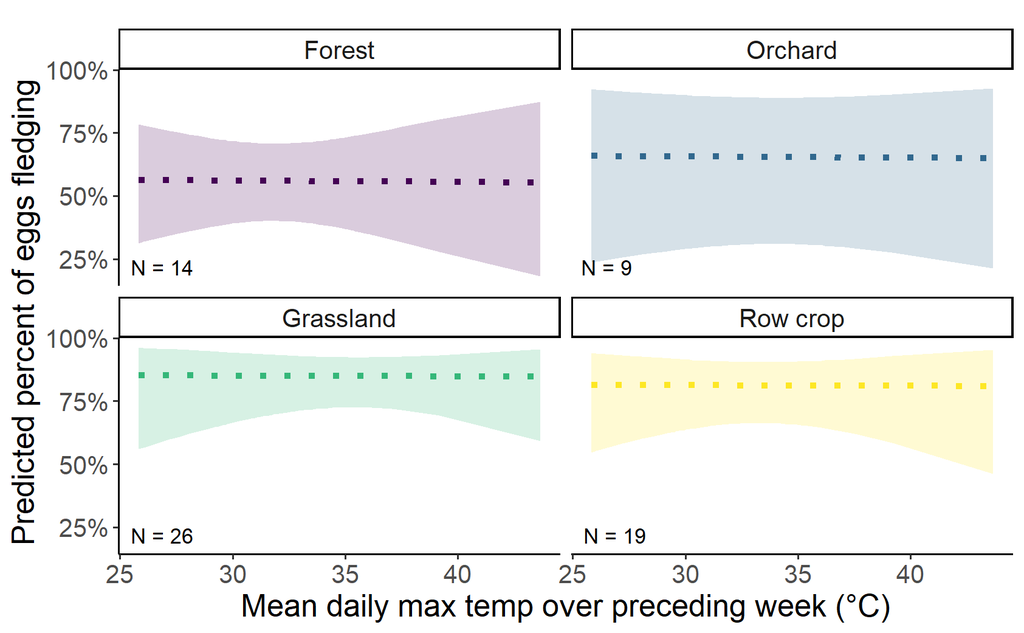

```r
data_tres = s_nestpd_TRES_noint$data


mean_temp_tres <- mean(data_tres %>% pull(meanmaxt_nestpd),na.rm = TRUE)
sd_temp_tres <- sd(data_tres %>% pull(meanmaxt_nestpd),na.rm = TRUE)


temp_trans_tres <- trans_new("temp_trans_tres",
                          transform = function(x){(x * sd_temp_tres) + mean_temp_tres},
                          inverse = function(x){x})

samp_tres <- data_tres %>% group_by(habitat) %>% summarize(count = n())
# samp %>% gt() %>% gtsave("../figures/ss_tres.html")


dat_text_tres <- data.frame(
  label = paste("N =",samp_tres$count),
  group   = factor(samp_tres$habitat)
)

(fig3_tres <- predict_response(prior_model,terms = c("meanmaxt_nestpd_scaled [all]","habitat")) %>%
   plot(line_size = 1.5,alpha = .2,show_data = TRUE,limit_range = TRUE) +
    aes(linetype = .data[["group"]]) +
    theme_classic() +
   facet_wrap(~ group, ncol = 2) +
    xlab("Mean daily max temp over preceding week (\u00b0C)") +
    ylab("Predicted percent of eggs fledging") +
   scale_fill_viridis(discrete = TRUE) +
    scale_color_viridis(discrete = TRUE) +
    theme(text = element_text(size = 16)) +
    labs(title = element_blank()) +
   scale_x_continuous(trans = temp_trans_tres,
                       breaks = c((20-mean_temp_tres)/sd_temp_tres,
                                  (25-mean_temp_tres)/sd_temp_tres,
                                  (30-mean_temp_tres)/sd_temp_tres,
                                  (35-mean_temp_tres)/sd_temp_tres,
                                  (40-mean_temp_tres)/sd_temp_tres#,
                                  #(45-mean_temp)/sd_temp
                                  ),
                       # breaks = c(20,30,40,50),
                       # labels = c("20","30","40","50"),
                       # limits = c((15-mean(g$meanmaxtempI,na.rm = TRUE))/sd(g$meanmaxtempI,na.rm = TRUE),
                       #            (55-mean(g$meanmaxtempI,na.rm = TRUE))/sd(g$meanmaxtempI,na.rm = TRUE))
                       # limits = c(18,5)
                       ) +
   # ylim(0,100) +
   scale_linetype_manual(values = c("Forest" = "dotted","Orchard" = "dotted","Grassland" = "dotted","Row crop" = "dotted")) +
   geom_text(data = dat_text_tres, mapping = aes(x = -Inf, y = -Inf,label = label),hjust = -.2,vjust = -.7,inherit.aes = FALSE) +
    theme(legend.position = "none")
   )
```

##### With interaction

```
G3;Raw data not available.
gScale for colour is already present.
```

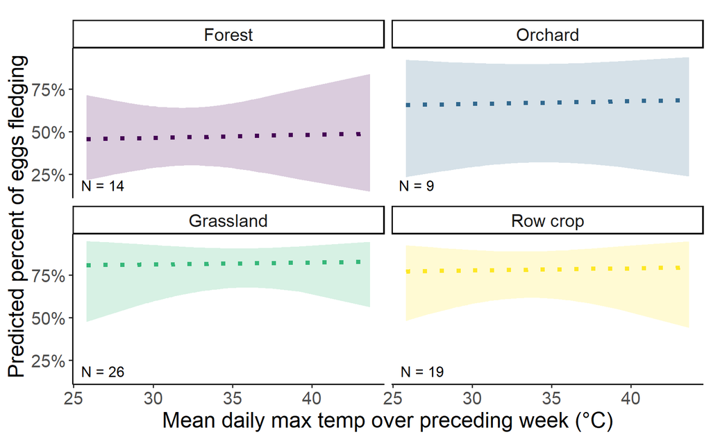

```r
(fig3_tres <- predict_response(s_nestpd_TRES_noint,terms = c("meanmaxt_nestpd_scaled [all]","habitat")) %>%
   plot(line_size = 1.5,alpha = .2,show_data = TRUE,limit_range = TRUE) +
    aes(linetype = .data[["group"]]) +
    theme_classic() +
   facet_wrap(~ group, ncol = 2) +
    xlab("Mean daily max temp over preceding week (\u00b0C)") +
    ylab("Predicted percent of eggs fledging") +
   scale_fill_viridis(discrete = TRUE) +
    scale_color_viridis(discrete = TRUE) +
    theme(text = element_text(size = 16)) +
    labs(title = element_blank()) +
   scale_x_continuous(trans = temp_trans_tres,
                       breaks = c((20-mean_temp_tres)/sd_temp_tres,
                                  (25-mean_temp_tres)/sd_temp_tres,
                                  (30-mean_temp_tres)/sd_temp_tres,
                                  (35-mean_temp_tres)/sd_temp_tres,
                                  (40-mean_temp_tres)/sd_temp_tres#,
                                  #(45-mean_temp)/sd_temp
                                  ),
                       # breaks = c(20,30,40,50),
                       # labels = c("20","30","40","50"),
                       # limits = c((15-mean(g$meanmaxtempI,na.rm = TRUE))/sd(g$meanmaxtempI,na.rm = TRUE),
                       #            (55-mean(g$meanmaxtempI,na.rm = TRUE))/sd(g$meanmaxtempI,na.rm = TRUE))
                       # limits = c(18,5)
                       ) +
   # ylim(0,100) +
   scale_linetype_manual(values = c("Forest" = "dotted","Orchard" = "dotted","Grassland" = "dotted","Row crop" = "dotted")) +
   geom_text(data = dat_text_tres, mapping = aes(x = -Inf, y = -Inf,label = label),hjust = -.2,vjust = -.7,inherit.aes = FALSE) +
    theme(legend.position = "none")
   )
```

##### Visualize direction of interaction

```
G3;Bias-correction is currently only supported for mixed or gee models. No bias-correction is applied.
gG3;Raw data not available.
g
```

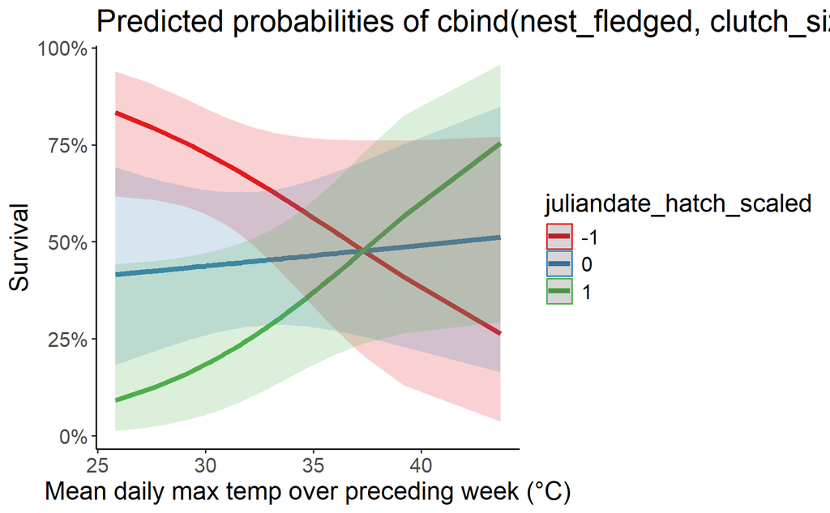

```r
(plott <- predict_response(s_nestpd_TRES_noint,terms = c("meanmaxt_nestpd_scaled [all]","juliandate_hatch_scaled"),bias_correction = TRUE) %>%
    plot(line_size = 1.5,alpha = .2,show_data = TRUE,limit_range = TRUE) +
    # aes(linetype = .data[["group"]]) +
    theme_classic() +
    # facet_wrap(~ group, ncol = 2) +
    xlab("Mean daily max temp over preceding week (\u00b0C)") +
    ylab("Survival") +
    # scale_fill_viridis(discrete = TRUE) +
    # scale_color_viridis(discrete = TRUE) +
    # scale_linetype_manual(values = c("Forest" = "solid","Orchard" = "solid","Grassland" = "dotted","Row crop" = "solid")) +
    theme(text = element_text(size = 16)) +
    # labs(title = element_blank()) +
    scale_x_continuous(trans = temp_trans_tres,
                       breaks = c((20-mean_temp_tres)/sd_temp_tres,
                                  (25-mean_temp_tres)/sd_temp_tres,
                                  (30-mean_temp_tres)/sd_temp_tres,
                                  (35-mean_temp_tres)/sd_temp_tres,
                                  (40-mean_temp_tres)/sd_temp_tres),
                       # breaks = c(20,30,40,50),
                       # labels = c("20","30","40","50"),
                       # limits = c((15-mean(g$meanmaxtempI,na.rm = TRUE))/sd(g$meanmaxtempI,na.rm = TRUE),
                       #            (55-mean(g$meanmaxtempI,na.rm = TRUE))/sd(g$meanmaxtempI,na.rm = TRUE))
                       # limits = c(18,5)
    ) #+
    #ylim(-5,5) +
    # geom_text(data = dat_text_tres, mapping = aes(x = -Inf, y = Inf,label = label),hjust = -.2, vjust = 1.2,inherit.aes = FALSE) +
    # theme(legend.position = "none")
)
```

#### Conclusion: for TRES survival, the interaction is improves fit but does not alter the overall findings re: survival. The interaction between temp and julian date is as expected: Earlier in the season, hot temps decrease survival more than hot temps later in the season.

### Baseline cort by prior week temp

#### WEBL

```r
g <- read_rds("../data/growth_cort_provis_manytempmeasures.rds") %>%
  mutate(year_fct = as.factor(year))

prior_model <- lmerTest::lmer(sqrt(cort_s1) ~ meanmaxtempI_scaled + habitat + meanmintempI_scaled + habitat + age_scaled + juliandate_scaled + year_fct + (1|attempt_id),data = dplyr::filter(g,Species == "WEBL",!is.na(meanmaxtempI),!is.na(meanmintempI)) %>%
                               mutate(across(c(gweight,meanmaxtempI,meanmintempI,juliandate,brood_size,age),
                                             ~ scale(.x)[,1],
                                             .names = "{.col}_scaled"),
                                      meanmaxtempI_scaled_sq = meanmaxtempI_scaled * meanmaxtempI_scaled))

s1_lintemp <- lmerTest::lmer(sqrt(cort_s1) ~ meanmaxtempI_scaled * habitat + meanmintempI_scaled * habitat + age_scaled + meanmaxtempI_scaled * juliandate_scaled + year_fct + (1|attempt_id),data = dplyr::filter(g,Species == "WEBL",!is.na(meanmaxtempI),!is.na(meanmintempI)) %>%
                               mutate(across(c(gweight,meanmaxtempI,meanmintempI,juliandate,brood_size,age),
                                             ~ scale(.x)[,1],
                                             .names = "{.col}_scaled"),
                                      meanmaxtempI_scaled_sq = meanmaxtempI_scaled * meanmaxtempI_scaled))

s1_lintemp_addmax <- lmerTest::lmer(sqrt(cort_s1) ~ meanmaxtempI_scaled + meanmintempI_scaled * habitat + age_scaled + meanmaxtempI_scaled * juliandate_scaled + year_fct + (1|attempt_id),data = dplyr::filter(g,Species == "WEBL",!is.na(meanmaxtempI),!is.na(meanmintempI)) %>%
                                      mutate(across(c(gweight,meanmaxtempI,meanmintempI,juliandate,brood_size,age),
                                                    ~ scale(.x)[,1],
                                                    .names = "{.col}_scaled"),
                                             meanmaxtempI_scaled_sq = meanmaxtempI_scaled * meanmaxtempI_scaled))

s1_lintemp_addmin <- lmerTest::lmer(sqrt(cort_s1) ~ meanmaxtempI_scaled * habitat + meanmintempI_scaled + age_scaled + meanmaxtempI_scaled * juliandate_scaled + year_fct + (1|attempt_id),data = dplyr::filter(g,Species == "WEBL",!is.na(meanmaxtempI),!is.na(meanmintempI)) %>%
                                      mutate(across(c(gweight,meanmaxtempI,meanmintempI,juliandate,brood_size,age),
                                                    ~ scale(.x)[,1],
                                                    .names = "{.col}_scaled"),
                                             meanmaxtempI_scaled_sq = meanmaxtempI_scaled * meanmaxtempI_scaled))

s1_lintemp_noint <- lmerTest::lmer(sqrt(cort_s1) ~ meanmaxtempI_scaled + meanmintempI_scaled + habitat + age_scaled + meanmaxtempI_scaled * juliandate_scaled + year_fct + (1|attempt_id),data = dplyr::filter(g,Species == "WEBL",!is.na(meanmaxtempI),!is.na(meanmintempI)) %>%
                                     mutate(across(c(gweight,meanmaxtempI,meanmintempI,juliandate,brood_size,age),
                                                   ~ scale(.x)[,1],
                                                   .names = "{.col}_scaled"),
                                            meanmaxtempI_scaled_sq = meanmaxtempI_scaled * meanmaxtempI_scaled))

c1 <- anova(s1_lintemp,s1_lintemp_addmin,s1_lintemp_noint) %>% tibble() %>% mutate(Model = c("no interaction","single interaction","both interacting"),.before = npar)
```

```
G3;refitting model(s) with ML (instead of REML)
g
```

```r
c2 <- anova(s1_lintemp,s1_lintemp_addmax,s1_lintemp_noint) %>% tibble() %>% mutate(Model = c("no interaction","single interaction","both interacting"),.before = npar)
```

```
G3;refitting model(s) with ML (instead of REML)
g
```

```r
(int_tab_s1_webl <- bind_rows(c1,c2) %>%
    as.tibble() %>%
    mutate(across(where(is.numeric),~round(.x,digits = 3)),
           P = `Pr(>Chisq)`) %>%
    dplyr::select(Model,AIC,Chisq,P) %>%
    mutate(max_or_min = c(rep("Max temp",times = 3),rep("Min temp",times = 3)),
           across(c(AIC,Chisq), ~ round(.x, digits = 2)),
           P = if_else(P < 0.001,"<0.001",as.character(P))) %>%
    group_by(max_or_min) %>% gt())
```

| Model | AIC | Chisq | P |
| --- | --- | --- | --- |
| Max temp |  |  |  |
| no interaction | 279.78 | NA | NA |
| single interaction | 280.19 | 5.59 | 0.133 |
| both interacting | 284.07 | 2.12 | 0.548 |
| Min temp |  |  |  |
| no interaction | 279.78 | NA | NA |
| single interaction | 285.07 | 0.71 | 0.871 |
| both interacting | 284.07 | 7.00 | 0.072 |

```r
# gtsave(int_tab_s1_webl,"figures/int_tab_s1_webl.html")

s1_webl <- s1_lintemp_noint

anova(s1_lintemp_noint,prior_model)
```

```
G3;refitting model(s) with ML (instead of REML)
g
```

```
Data: dplyr::filter(g, Species == "WEBL", !is.na(meanmaxtempI), !is.na(meanmintempI)) %>%  ...
Models:
prior_model: sqrt(cort_s1) ~ meanmaxtempI_scaled + habitat + meanmintempI_scaled + habitat + age_scaled + juliandate_scaled + year_fct + (1 | attempt_id)
s1_lintemp_noint: sqrt(cort_s1) ~ meanmaxtempI_scaled + meanmintempI_scaled + habitat + age_scaled + meanmaxtempI_scaled * juliandate_scaled + year_fct + (1 | attempt_id)
                 npar    AIC    BIC  logLik deviance  Chisq Df Pr(>Chisq)
prior_model        11 278.49 313.30 -128.24   256.49
s1_lintemp_noint   12 279.78 317.76 -127.89   255.78 0.7095  1     0.3996
```

Same conclusion here - noint is the most supported model, and the additon of the temp * julian date interaction doesn’t improve fit.

```r
(webls1trendmax_prior <- emtrends(prior_model,specs = ~ habitat, var = c("meanmaxtempI_scaled")) %>% test() %>%
    mutate(across(where(is.numeric), ~ round(.x, digits = 3)),
           df = round(df),
           p.value = if_else(p.value == 0.000,"<0.001",as.character(p.value))) %>%
    rename(Habitat = "habitat", `Max temp trend` = "meanmaxtempI_scaled.trend",Df = "df", `T-ratio` = "t.ratio", P = "p.value") %>%
    gt())
```

| Habitat | Max temp trend | SE | Df | T-ratio | P |
| --- | --- | --- | --- | --- | --- |
| Forest | 0.038 | 0.077 | 100 | 0.492 | 0.624 |
| Orchard | 0.038 | 0.077 | 100 | 0.492 | 0.624 |
| Grassland | 0.038 | 0.077 | 100 | 0.492 | 0.624 |
| Row crop | 0.038 | 0.077 | 100 | 0.492 | 0.624 |

```r
(webls1trendmax <- emtrends(s1_lintemp_noint,specs = ~ habitat, var = c("meanmaxtempI_scaled")) %>% test() %>%
    mutate(across(where(is.numeric), ~ round(.x, digits = 3)),
           df = round(df),
           p.value = if_else(p.value == 0.000,"<0.001",as.character(p.value))) %>%
    rename(Habitat = "habitat", `Max temp trend` = "meanmaxtempI_scaled.trend",Df = "df", `T-ratio` = "t.ratio", P = "p.value") %>%
    gt())
```

| Habitat | Max temp trend | SE | Df | T-ratio | P |
| --- | --- | --- | --- | --- | --- |
| Forest | 0.04 | 0.077 | 97 | 0.525 | 0.6 |
| Orchard | 0.04 | 0.077 | 97 | 0.525 | 0.6 |
| Grassland | 0.04 | 0.077 | 97 | 0.525 | 0.6 |
| Row crop | 0.04 | 0.077 | 97 | 0.525 | 0.6 |

Same results - very slightly positive and not significant. I don’t think I’m even going to graph that.

##### Visualization of the temp * julian date interaction

```
G3;Model has sqrt-transformed response. Back-transforming predictions to original response scale. Standard
  errors are still on the transformed scale.
gG3;Data points may overlap. Use the `jitter` argument to add some amount of random variation to the
  location of data points and avoid overplotting.
g
```

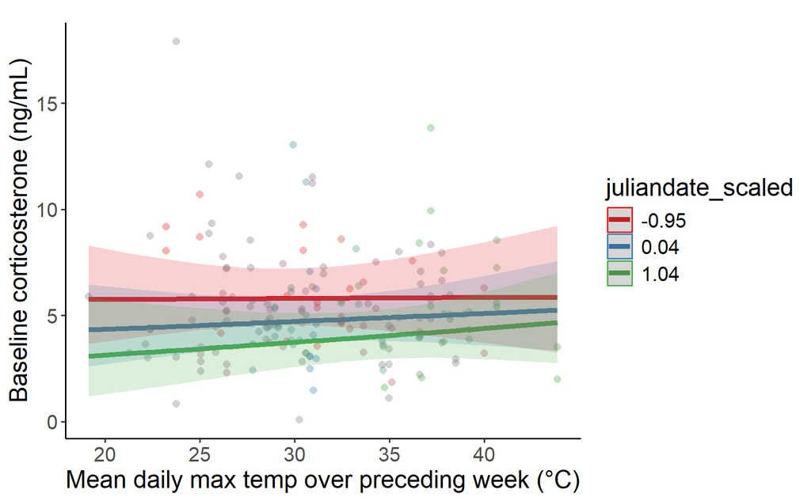

```r
samp_s1_webl <- s1_lintemp_noint@frame %>% group_by(habitat) %>% summarize(count = n())
# samp_s1_webl %>% gt() %>% gtsave("figures/ss_webl_s1.html")


dat_text_s1_webl <- data.frame(
  label = paste("N =",samp_s1_webl$count),
  group   = factor(c("Forest","Orchard","Grassland","Row crop"))
)





data_s1_webl = dplyr::filter(g,Species == "WEBL",!is.na(meanmaxtempI),!is.na(meanmintempI)) %>%
  mutate(across(c(gweight,meanmaxtempI,meanmintempI,juliandate,brood_size,age),
                ~ scale(.x)[,1],
                .names = "{.col}_scaled"),
         meanmaxtempI_scaled_sq = meanmaxtempI_scaled * meanmaxtempI_scaled)


mean_temp_s1_webl <- mean(data_s1_webl %>% pull(meanmaxtempI))
sd_temp_s1_webl <- sd(data_s1_webl %>% pull(meanmaxtempI))


temp_trans_s1_webl <- trans_new("temp_trans_s1_webl",
                                transform = function(x){(x * sd_temp_s1_webl) + mean_temp_s1_webl},
                                inverse = function(x){x})

(figs2_webl <- ggpredict(s1_lintemp_noint,terms = c("meanmaxtempI_scaled [all]","juliandate_scaled"),bias_correction = TRUE) %>%
    plot(line_size = 1.5,alpha = .2,show_data = TRUE,limit_range = TRUE) +
    # aes(linetype = .data[["group"]]) +
    theme_classic() +
    # facet_wrap(~ group, ncol = 2) +
    xlab("Mean daily max temp over preceding week (\u00b0C)") +
    ylab("Baseline corticosterone (ng/mL)") +
    #scale_fill_viridis(discrete = TRUE) +
    #scale_color_viridis(discrete = TRUE) +
    theme(text = element_text(size = 16)) +
    labs(title = element_blank()) +
    scale_x_continuous(trans = temp_trans_s1_webl,
                       breaks = c((20-mean_temp_s1_webl)/sd_temp_s1_webl,
                                  (25-mean_temp_s1_webl)/sd_temp_s1_webl,
                                  (30-mean_temp_s1_webl)/sd_temp_s1_webl,
                                  (35-mean_temp_s1_webl)/sd_temp_s1_webl,
                                  (40-mean_temp_s1_webl)/sd_temp_s1_webl),
                       # breaks = c(20,30,40,50),
                       # labels = c("20","30","40","50"),
                       # limits = c((15-mean(g$meanmaxtempI,na.rm = TRUE))/sd(g$meanmaxtempI,na.rm = TRUE),
                       #            (55-mean(g$meanmaxtempI,na.rm = TRUE))/sd(g$meanmaxtempI,na.rm = TRUE))
                       # limits = c(18,5)
    ) #+
    # scale_linetype_manual(values = c("dotted","dotted","dotted","dotted")) +
    #ylim(-5,5) +
    #geom_text(data = dat_text_s1_webl, mapping = aes(x = -Inf, y = Inf,label = label),hjust = -.2, vjust = 1.2,inherit.aes = FALSE) +
    #theme(legend.position = "none")
)
```

##### Conclusion: juliandate * temp interaction neither adds to the fit nor changes the results.

#### TRES

```r
prior_model <- lmerTest::lmer(sqrt(cort_s1) ~ meanmaxtempI_scaled + meanmintempI_scaled * habitat + age_scaled + juliandate_scaled + year_fct + (1|attempt_id),data = dplyr::filter(g,Species == "TRES",!is.na(meanmaxtempI),!is.na(meanmintempI)) %>%
                                      mutate(across(c(gweight,meanmaxtempI,meanmintempI,juliandate,brood_size,age),
                                                    ~ scale(.x)[,1],
                                                    .names = "{.col}_scaled"),
                                             meanmaxtempI_scaled_sq = meanmaxtempI_scaled * meanmaxtempI_scaled))

s1_lintemp <- lmerTest::lmer(sqrt(cort_s1) ~ meanmaxtempI_scaled * habitat + meanmintempI_scaled * habitat + age_scaled + meanmaxtempI_scaled * juliandate_scaled + year_fct + (1|attempt_id),data = dplyr::filter(g,Species == "TRES",!is.na(meanmaxtempI),!is.na(meanmintempI)) %>%
                               mutate(across(c(gweight,meanmaxtempI,meanmintempI,juliandate,brood_size,age),
                                             ~ scale(.x)[,1],
                                             .names = "{.col}_scaled"),
                                      meanmaxtempI_scaled_sq = meanmaxtempI_scaled * meanmaxtempI_scaled))

s1_lintemp_addmax <- lmerTest::lmer(sqrt(cort_s1) ~ meanmaxtempI_scaled + meanmintempI_scaled * habitat + age_scaled + meanmaxtempI_scaled * juliandate_scaled + year_fct + (1|attempt_id),data = dplyr::filter(g,Species == "TRES",!is.na(meanmaxtempI),!is.na(meanmintempI)) %>%
                                      mutate(across(c(gweight,meanmaxtempI,meanmintempI,juliandate,brood_size,age),
                                                    ~ scale(.x)[,1],
                                                    .names = "{.col}_scaled"),
                                             meanmaxtempI_scaled_sq = meanmaxtempI_scaled * meanmaxtempI_scaled))

s1_lintemp_addmin <- lmerTest::lmer(sqrt(cort_s1) ~ meanmaxtempI_scaled * habitat + meanmintempI_scaled + age_scaled + meanmaxtempI_scaled * juliandate_scaled + year_fct + (1|attempt_id),data = dplyr::filter(g,Species == "TRES",!is.na(meanmaxtempI),!is.na(meanmintempI)) %>%
                                      mutate(across(c(gweight,meanmaxtempI,meanmintempI,juliandate,brood_size,age),
                                                    ~ scale(.x)[,1],
                                                    .names = "{.col}_scaled"),
                                             meanmaxtempI_scaled_sq = meanmaxtempI_scaled * meanmaxtempI_scaled))

s1_lintemp_noint <- lmerTest::lmer(sqrt(cort_s1) ~ meanmaxtempI_scaled + meanmintempI_scaled + habitat + age_scaled + meanmaxtempI_scaled * juliandate_scaled + year_fct + (1|attempt_id),data = dplyr::filter(g,Species == "TRES",!is.na(meanmaxtempI),!is.na(meanmintempI)) %>%
                                     mutate(across(c(gweight,meanmaxtempI,meanmintempI,juliandate,brood_size,age),
                                                   ~ scale(.x)[,1],
                                                   .names = "{.col}_scaled"),
                                            meanmaxtempI_scaled_sq = meanmaxtempI_scaled * meanmaxtempI_scaled))

c1 <- anova(s1_lintemp,s1_lintemp_addmin,s1_lintemp_noint) %>% tibble() %>% mutate(Model = c("no interaction","single interaction","both interacting"),.before = npar)
```

```
G3;refitting model(s) with ML (instead of REML)
g
```

```r
c2 <- anova(s1_lintemp,s1_lintemp_addmax,s1_lintemp_noint) %>% tibble() %>% mutate(Model = c("no interaction","single interaction","both interacting"),.before = npar)
```

```
G3;refitting model(s) with ML (instead of REML)
g
```

```r
(int_tab_s1_tres <- bind_rows(c1,c2) %>%
    as.tibble() %>%
    mutate(across(where(is.numeric),~round(.x,digits = 3)),
           P = `Pr(>Chisq)`) %>%
    dplyr::select(Model,AIC,Chisq,P) %>%
    mutate(max_or_min = c(rep("Max temp",times = 3),rep("Min temp",times = 3)),
           across(c(AIC,Chisq), ~ round(.x, digits = 2)),
           P = if_else(P < 0.001,"<0.001",as.character(P))) %>%
    group_by(max_or_min) %>% gt())
```

| Model | AIC | Chisq | P |
| --- | --- | --- | --- |
| Max temp |  |  |  |
| no interaction | 197.59 | NA | NA |
| single interaction | 203.28 | 0.31 | 0.958 |
| both interacting | 193.99 | 15.29 | 0.002 |
| Min temp |  |  |  |
| no interaction | 197.59 | NA | NA |
| single interaction | 191.64 | 11.95 | 0.008 |
| both interacting | 193.99 | 3.65 | 0.302 |

```r
#gtsave(int_tab_s1_tres,"figures/int_tab_s1_tres.html")

s1_tres <- s1_lintemp_addmax

anova(s1_lintemp_addmax,prior_model)
```

```
G3;refitting model(s) with ML (instead of REML)
g
```

```
Data: dplyr::filter(g, Species == "TRES", !is.na(meanmaxtempI), !is.na(meanmintempI)) %>%  ...
Models:
prior_model: sqrt(cort_s1) ~ meanmaxtempI_scaled + meanmintempI_scaled * habitat + age_scaled + juliandate_scaled + year_fct + (1 | attempt_id)
s1_lintemp_addmax: sqrt(cort_s1) ~ meanmaxtempI_scaled + meanmintempI_scaled * habitat + age_scaled + meanmaxtempI_scaled * juliandate_scaled + year_fct + (1 | attempt_id)
                  npar    AIC    BIC  logLik deviance  Chisq Df Pr(>Chisq)
prior_model         14 190.32 227.48 -81.161   162.32
s1_lintemp_addmax   15 191.64 231.45 -80.821   161.64 0.6794  1     0.4098
```

Same model results, and temp * julian date does not add to model fit

```r
(tress1trendmax_prior <- emtrends(prior_model,specs = ~ habitat, var = c("meanmaxtempI_scaled")) %>% test() %>%
    mutate(across(where(is.numeric), ~ round(.x, digits = 3)),
           df = round(df),
           p.value = if_else(p.value == 0.000,"<0.001",as.character(p.value))) %>%
    rename(Habitat = "habitat", `Max temp trend` = "meanmaxtempI_scaled.trend",Df = "df", `T-ratio` = "t.ratio", P = "p.value") %>%
    gt())
```

| Habitat | Max temp trend | SE | Df | T-ratio | P |
| --- | --- | --- | --- | --- | --- |
| Forest | 0.155 | 0.119 | 32 | 1.309 | 0.2 |
| Orchard | 0.155 | 0.119 | 32 | 1.309 | 0.2 |
| Grassland | 0.155 | 0.119 | 32 | 1.309 | 0.2 |
| Row crop | 0.155 | 0.119 | 32 | 1.309 | 0.2 |

```r
(tress1trendmax <- emtrends(s1_lintemp_addmax,specs = ~ habitat, var = c("meanmaxtempI_scaled")) %>% test() %>%
    mutate(across(where(is.numeric), ~ round(.x, digits = 3)),
           df = round(df),
           p.value = if_else(p.value == 0.000,"<0.001",as.character(p.value))) %>%
    rename(Habitat = "habitat", `Max temp trend` = "meanmaxtempI_scaled.trend",Df = "df", `T-ratio` = "t.ratio", P = "p.value") %>%
    gt())
```

| Habitat | Max temp trend | SE | Df | T-ratio | P |
| --- | --- | --- | --- | --- | --- |
| Forest | 0.182 | 0.125 | 26 | 1.458 | 0.157 |
| Orchard | 0.182 | 0.125 | 26 | 1.458 | 0.157 |
| Grassland | 0.182 | 0.125 | 26 | 1.458 | 0.157 |
| Row crop | 0.182 | 0.125 | 26 | 1.458 | 0.157 |

No difference between models.

##### Without interaction

```
G3;Model has sqrt-transformed response. Back-transforming predictions to original response scale. Standard
  errors are still on the transformed scale.
gG3;Data points may overlap. Use the `jitter` argument to add some amount of random variation to the
  location of data points and avoid overplotting.
g
```

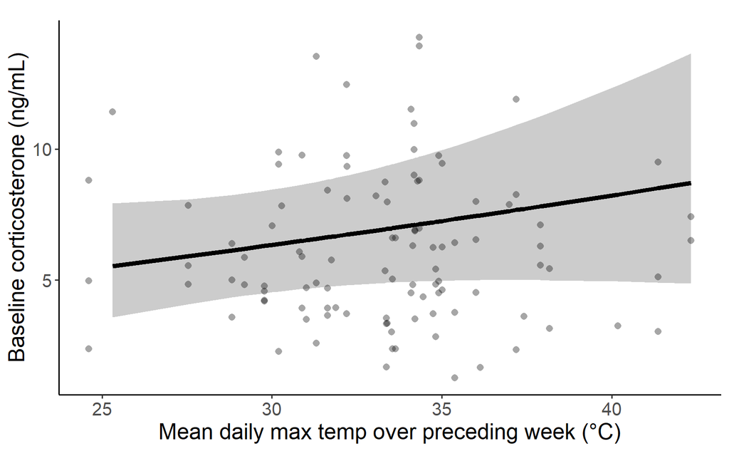

```r
samp_s1_tres <- s1_lintemp_addmax@frame %>% group_by(habitat) %>% summarize(count = n())
# samp %>% gt() %>% gtsave("figures/ss_tres_s1.html")


dat_text_s1_tres <- data.frame(
  label = paste("N =",samp_s1_tres$count),
  group   = factor(c("Forest","Orchard","Grassland","Row crop"))
)

data_s1_tres = dplyr::filter(g,Species == "TRES",!is.na(meanmaxtempI),!is.na(meanmintempI)) %>%
  mutate(across(c(gweight,meanmaxtempI,meanmintempI,juliandate,brood_size,age),
                ~ scale(.x)[,1],
                .names = "{.col}_scaled"),
         meanmaxtempI_scaled_sq = meanmaxtempI_scaled * meanmaxtempI_scaled)


mean_temp_s1_tres <- mean(data_s1_tres %>% pull(meanmaxtempI))
sd_temp_s1_tres <- sd(data_s1_tres %>% pull(meanmaxtempI))


temp_trans_s1_tres <- trans_new("temp_trans_s1_tres",
                                transform = function(x){(x * sd_temp_s1_tres) + mean_temp_s1_tres},
                                inverse = function(x){x})

(figs2_tres <- ggpredict(prior_model,terms = c("meanmaxtempI_scaled [all]"),bias_correction = TRUE) %>%
    plot(line_size = 1.5,alpha = .2,show_data = TRUE,limit_range = TRUE) +
    # aes(linetype = .data[["group"]]) +
    theme_classic() +
    # facet_wrap(~ group, ncol = 2) +
    xlab("Mean daily max temp over preceding week (\u00b0C)") +
    ylab("Baseline corticosterone (ng/mL)") +
    # scale_fill_viridis(discrete = TRUE) +
    # scale_color_viridis(discrete = TRUE) +
    theme(text = element_text(size = 16)) +
    labs(title = element_blank()) +
    scale_x_continuous(trans = temp_trans_s1_tres,
                       breaks = c((20-mean_temp_s1_tres)/sd_temp_s1_tres,
                                  (25-mean_temp_s1_tres)/sd_temp_s1_tres,
                                  (30-mean_temp_s1_tres)/sd_temp_s1_tres,
                                  (35-mean_temp_s1_tres)/sd_temp_s1_tres,
                                  (40-mean_temp_s1_tres)/sd_temp_s1_tres),
                       # breaks = c(20,30,40,50),
                       # labels = c("20","30","40","50"),
                       # limits = c((15-mean(g$meanmaxtempI,na.rm = TRUE))/sd(g$meanmaxtempI,na.rm = TRUE),
                       #            (55-mean(g$meanmaxtempI,na.rm = TRUE))/sd(g$meanmaxtempI,na.rm = TRUE))
                       # limits = c(18,5)
    ) +
    # scale_linetype_manual(values = c("dotted","dotted","dotted","dotted")) +
    #ylim(-5,5) +
    # geom_text(data = dat_text_s1_tres, mapping = aes(x = -Inf, y = Inf,label = label),hjust = -.2, vjust = 1.2,inherit.aes = FALSE) +
    theme(legend.position = "none")
)
```

##### With interaction

```
G3;Model has sqrt-transformed response. Back-transforming predictions to original response scale. Standard
  errors are still on the transformed scale.
gG3;Data points may overlap. Use the `jitter` argument to add some amount of random variation to the
  location of data points and avoid overplotting.
g
```

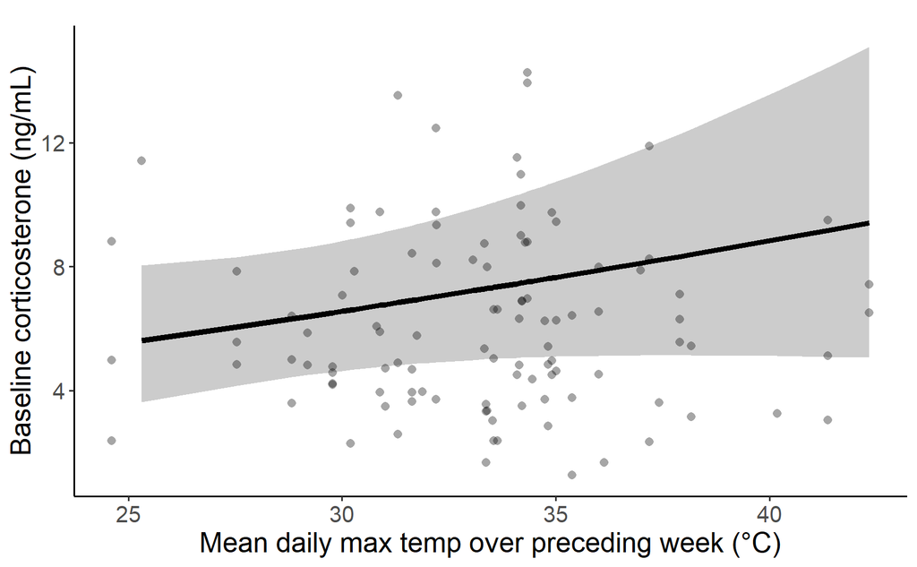

```r
samp_s1_tres <- s1_lintemp_addmax@frame %>% group_by(habitat) %>% summarize(count = n())
# samp %>% gt() %>% gtsave("figures/ss_tres_s1.html")


dat_text_s1_tres <- data.frame(
  label = paste("N =",samp_s1_tres$count),
  group   = factor(c("Forest","Orchard","Grassland","Row crop"))
)

data_s1_tres = dplyr::filter(g,Species == "TRES",!is.na(meanmaxtempI),!is.na(meanmintempI)) %>%
  mutate(across(c(gweight,meanmaxtempI,meanmintempI,juliandate,brood_size,age),
                ~ scale(.x)[,1],
                .names = "{.col}_scaled"),
         meanmaxtempI_scaled_sq = meanmaxtempI_scaled * meanmaxtempI_scaled)


mean_temp_s1_tres <- mean(data_s1_tres %>% pull(meanmaxtempI))
sd_temp_s1_tres <- sd(data_s1_tres %>% pull(meanmaxtempI))


temp_trans_s1_tres <- trans_new("temp_trans_s1_tres",
                                transform = function(x){(x * sd_temp_s1_tres) + mean_temp_s1_tres},
                                inverse = function(x){x})

(figs2_tres <- ggpredict(s1_lintemp_addmax,terms = c("meanmaxtempI_scaled [all]"),bias_correction = TRUE) %>%
    plot(line_size = 1.5,alpha = .2,show_data = TRUE,limit_range = TRUE) +
    # aes(linetype = .data[["group"]]) +
    theme_classic() +
    # facet_wrap(~ group, ncol = 2) +
    xlab("Mean daily max temp over preceding week (\u00b0C)") +
    ylab("Baseline corticosterone (ng/mL)") +
    # scale_fill_viridis(discrete = TRUE) +
    # scale_color_viridis(discrete = TRUE) +
    theme(text = element_text(size = 16)) +
    labs(title = element_blank()) +
    scale_x_continuous(trans = temp_trans_s1_tres,
                       breaks = c((20-mean_temp_s1_tres)/sd_temp_s1_tres,
                                  (25-mean_temp_s1_tres)/sd_temp_s1_tres,
                                  (30-mean_temp_s1_tres)/sd_temp_s1_tres,
                                  (35-mean_temp_s1_tres)/sd_temp_s1_tres,
                                  (40-mean_temp_s1_tres)/sd_temp_s1_tres),
                       # breaks = c(20,30,40,50),
                       # labels = c("20","30","40","50"),
                       # limits = c((15-mean(g$meanmaxtempI,na.rm = TRUE))/sd(g$meanmaxtempI,na.rm = TRUE),
                       #            (55-mean(g$meanmaxtempI,na.rm = TRUE))/sd(g$meanmaxtempI,na.rm = TRUE))
                       # limits = c(18,5)
    ) +
    # scale_linetype_manual(values = c("dotted","dotted","dotted","dotted")) +
    #ylim(-5,5) +
    # geom_text(data = dat_text_s1_tres, mapping = aes(x = -Inf, y = Inf,label = label),hjust = -.2, vjust = 1.2,inherit.aes = FALSE) +
    theme(legend.position = "none")
)
```

##### Visualize interaction

```
G3;Model has sqrt-transformed response. Back-transforming predictions to original response scale. Standard
  errors are still on the transformed scale.
gG3;Data points may overlap. Use the `jitter` argument to add some amount of random variation to the
  location of data points and avoid overplotting.
g
```

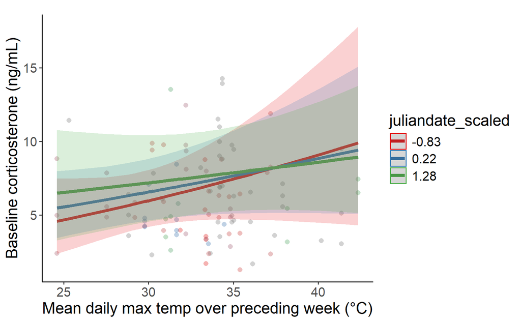

```r
(figs2_tres <- ggpredict(s1_lintemp_addmax,terms = c("meanmaxtempI_scaled [all]","juliandate_scaled"),bias_correction = TRUE) %>%
    plot(line_size = 1.5,alpha = .2,show_data = TRUE,limit_range = TRUE) +
    # aes(linetype = .data[["group"]]) +
    theme_classic() +
    # facet_wrap(~ group, ncol = 2) +
    xlab("Mean daily max temp over preceding week (\u00b0C)") +
    ylab("Baseline corticosterone (ng/mL)") +
    # scale_fill_viridis(discrete = TRUE) +
    # scale_color_viridis(discrete = TRUE) +
    theme(text = element_text(size = 16)) +
    labs(title = element_blank()) +
    scale_x_continuous(trans = temp_trans_s1_tres,
                       breaks = c((20-mean_temp_s1_tres)/sd_temp_s1_tres,
                                  (25-mean_temp_s1_tres)/sd_temp_s1_tres,
                                  (30-mean_temp_s1_tres)/sd_temp_s1_tres,
                                  (35-mean_temp_s1_tres)/sd_temp_s1_tres,
                                  (40-mean_temp_s1_tres)/sd_temp_s1_tres),
                       # breaks = c(20,30,40,50),
                       # labels = c("20","30","40","50"),
                       # limits = c((15-mean(g$meanmaxtempI,na.rm = TRUE))/sd(g$meanmaxtempI,na.rm = TRUE),
                       #            (55-mean(g$meanmaxtempI,na.rm = TRUE))/sd(g$meanmaxtempI,na.rm = TRUE))
                       # limits = c(18,5)
    ) #+
    # scale_linetype_manual(values = c("dotted","dotted","dotted","dotted")) +
    #ylim(-5,5) +
    # geom_text(data = dat_text_s1_tres, mapping = aes(x = -Inf, y = Inf,label = label),hjust = -.2, vjust = 1.2,inherit.aes = FALSE) +
    #theme(legend.position = "none")
)
```

##### Interaction is not significant, does not add to fit, does not change results.

### Abs difference cort by prior week temp

#### WEBL

```r
prior_model <- lmerTest::lmer(sqrt(abs_change_cort) ~ meanmaxtempI_scaled * habitat + meanmintempI_scaled * habitat + age_scaled + juliandate_scaled + year_fct + (1|attempt_id),data = dplyr::filter(g,Species == "WEBL",!is.na(meanmaxtempI),!is.na(meanmintempI)) %>%
                                mutate(across(c(gweight,meanmaxtempI,meanmintempI,juliandate,brood_size,age),
                                              ~ scale(.x)[,1],
                                              .names = "{.col}_scaled"),
                                       meanmaxtempI_scaled_sq = meanmaxtempI_scaled * meanmaxtempI_scaled))
```

```
G2;H2;Warningh in sqrt(abs_change_cort) : NaNs producedg
G2;H2;Warningh in sqrt(abs_change_cort) : NaNs producedg
G2;H2;Warningh in sqrt(abs_change_cort) : NaNs producedg
G2;H2;Warningh in sqrt(abs_change_cort) : NaNs producedg
G2;H2;Warningh in sqrt(abs_change_cort) : NaNs producedg
G2;H2;Warningh in sqrt(abs_change_cort) : NaNs producedg
```

```r
abs_lintemp <- lmerTest::lmer(sqrt(abs_change_cort) ~ meanmaxtempI_scaled * habitat + meanmintempI_scaled * habitat + age_scaled + meanmaxtempI_scaled * juliandate_scaled + year_fct + (1|attempt_id),data = dplyr::filter(g,Species == "WEBL",!is.na(meanmaxtempI),!is.na(meanmintempI)) %>%
                                mutate(across(c(gweight,meanmaxtempI,meanmintempI,juliandate,brood_size,age),
                                              ~ scale(.x)[,1],
                                              .names = "{.col}_scaled"),
                                       meanmaxtempI_scaled_sq = meanmaxtempI_scaled * meanmaxtempI_scaled))
```

```
G2;H2;Warningh in sqrt(abs_change_cort) : NaNs producedg
G2;H2;Warningh in sqrt(abs_change_cort) : NaNs producedg
G2;H2;Warningh in sqrt(abs_change_cort) : NaNs producedg
G2;H2;Warningh in sqrt(abs_change_cort) : NaNs producedg
G2;H2;Warningh in sqrt(abs_change_cort) : NaNs producedg
G2;H2;Warningh in sqrt(abs_change_cort) : NaNs producedg
```

```r
abs_lintemp_addmax <- lmerTest::lmer(sqrt(abs_change_cort) ~ meanmaxtempI_scaled + meanmintempI_scaled * habitat + age_scaled + meanmaxtempI_scaled * juliandate_scaled + year_fct + (1|attempt_id),data = dplyr::filter(g,Species == "WEBL",!is.na(meanmaxtempI),!is.na(meanmintempI)) %>%
                                       mutate(across(c(gweight,meanmaxtempI,meanmintempI,juliandate,brood_size,age),
                                                     ~ scale(.x)[,1],
                                                     .names = "{.col}_scaled"),
                                              meanmaxtempI_scaled_sq = meanmaxtempI_scaled * meanmaxtempI_scaled))
```

```
G2;H2;Warningh in sqrt(abs_change_cort) : NaNs producedg
G2;H2;Warningh in sqrt(abs_change_cort) : NaNs producedg
G2;H2;Warningh in sqrt(abs_change_cort) : NaNs producedg
G2;H2;Warningh in sqrt(abs_change_cort) : NaNs producedg
G2;H2;Warningh in sqrt(abs_change_cort) : NaNs producedg
G2;H2;Warningh in sqrt(abs_change_cort) : NaNs producedg
```

```r
abs_lintemp_addmin <- lmerTest::lmer(sqrt(abs_change_cort) ~ meanmaxtempI_scaled * habitat + meanmintempI_scaled + age_scaled + meanmaxtempI_scaled * juliandate_scaled + year_fct + (1|attempt_id),data = dplyr::filter(g,Species == "WEBL",!is.na(meanmaxtempI),!is.na(meanmintempI)) %>%
                                       mutate(across(c(gweight,meanmaxtempI,meanmintempI,juliandate,brood_size,age),
                                                     ~ scale(.x)[,1],
                                                     .names = "{.col}_scaled"),
                                              meanmaxtempI_scaled_sq = meanmaxtempI_scaled * meanmaxtempI_scaled))
```

```
G2;H2;Warningh in sqrt(abs_change_cort) : NaNs producedg
G2;H2;Warningh in sqrt(abs_change_cort) : NaNs producedg
G2;H2;Warningh in sqrt(abs_change_cort) : NaNs producedg
G2;H2;Warningh in sqrt(abs_change_cort) : NaNs producedg
G2;H2;Warningh in sqrt(abs_change_cort) : NaNs producedg
G2;H2;Warningh in sqrt(abs_change_cort) : NaNs producedg
```

```r
abs_lintemp_noint <- lmerTest::lmer(sqrt(abs_change_cort) ~ meanmaxtempI_scaled + meanmintempI_scaled + habitat + age_scaled + meanmaxtempI_scaled * juliandate_scaled + year_fct + (1|attempt_id),data = dplyr::filter(g,Species == "WEBL",!is.na(meanmaxtempI),!is.na(meanmintempI)) %>%
                                      mutate(across(c(gweight,meanmaxtempI,meanmintempI,juliandate,brood_size,age),
                                                    ~ scale(.x)[,1],
                                                    .names = "{.col}_scaled"),
                                             meanmaxtempI_scaled_sq = meanmaxtempI_scaled * meanmaxtempI_scaled))
```

```
G2;H2;Warningh in sqrt(abs_change_cort) : NaNs producedg
G2;H2;Warningh in sqrt(abs_change_cort) : NaNs producedg
G2;H2;Warningh in sqrt(abs_change_cort) : NaNs producedg
G2;H2;Warningh in sqrt(abs_change_cort) : NaNs producedg
G2;H2;Warningh in sqrt(abs_change_cort) : NaNs producedg
G2;H2;Warningh in sqrt(abs_change_cort) : NaNs producedg
```

```r
c1 <- anova(abs_lintemp,abs_lintemp_addmin,abs_lintemp_noint) %>% tibble() %>% mutate(Model = c("no interaction","single interaction","both interacting"),.before = npar)
```

```
G3;refitting model(s) with ML (instead of REML)
g
```

```r
c2 <- anova(abs_lintemp,abs_lintemp_addmax,abs_lintemp_noint) %>% tibble() %>% mutate(Model = c("no interaction","single interaction","both interacting"),.before = npar)
```

```
G3;refitting model(s) with ML (instead of REML)
g
```

```r
(int_tab_abs_webl <- bind_rows(c1,c2) %>%
    as.tibble() %>%
    mutate(across(where(is.numeric),~round(.x,digits = 3)),
           P = `Pr(>Chisq)`) %>%
    dplyr::select(Model,AIC,Chisq,P) %>%
    mutate(max_or_min = c(rep("Max temp",times = 3),rep("Min temp",times = 3)),
           across(c(AIC,Chisq), ~ round(.x, digits = 2)),
           P = if_else(P < 0.001,"<0.001",as.character(P))) %>%
    group_by(max_or_min) %>% gt())
```

| Model | AIC | Chisq | P |
| --- | --- | --- | --- |
| Max temp |  |  |  |
| no interaction | 558.54 | NA | NA |
| single interaction | 564.35 | 0.20 | 0.978 |
| both interacting | 557.08 | 13.27 | 0.004 |
| Min temp |  |  |  |
| no interaction | 558.54 | NA | NA |
| single interaction | 559.36 | 5.18 | 0.159 |
| both interacting | 557.08 | 8.28 | 0.041 |

```r
#gtsave(int_tab_abs_webl,"figures/int_tab_abs_webl.html")

check_collinearity(abs_lintemp_noint)
```

```
# Check for Multicollinearity

Low Correlation

                                  Term  VIF   VIF 95% CI Increased SE Tolerance Tolerance 95% CI
                   meanmaxtempI_scaled 2.09 [1.70, 2.69]         1.45      0.48     [0.37, 0.59]
                   meanmintempI_scaled 2.73 [2.18, 3.55]         1.65      0.37     [0.28, 0.46]
                               habitat 1.29 [1.13, 1.66]         1.14      0.78     [0.60, 0.89]
                            age_scaled 1.07 [1.00, 1.88]         1.03      0.94     [0.53, 1.00]
                     juliandate_scaled 2.28 [1.84, 2.94]         1.51      0.44     [0.34, 0.54]
                              year_fct 1.17 [1.05, 1.55]         1.08      0.86     [0.64, 0.95]
 meanmaxtempI_scaled:juliandate_scaled 1.09 [1.01, 1.63]         1.05      0.91     [0.61, 0.99]
```

```r
abs_webl <- abs_lintemp
summary(abs_lintemp)
```

```
Linear mixed model fit by REML. t-tests use Satterthwaite's method ['lmerModLmerTest']
Formula: sqrt(abs_change_cort) ~ meanmaxtempI_scaled * habitat + meanmintempI_scaled *
    habitat + age_scaled + meanmaxtempI_scaled * juliandate_scaled +      year_fct + (1 | attempt_id)
   Data: dplyr::filter(g, Species == "WEBL", !is.na(meanmaxtempI), !is.na(meanmintempI)) %>%
    mutate(across(c(gweight, meanmaxtempI, meanmintempI, juliandate,
        brood_size, age), ~scale(.x)[, 1], .names = "{.col}_scaled"),
        meanmaxtempI_scaled_sq = meanmaxtempI_scaled * meanmaxtempI_scaled)

REML criterion at convergence: 522

Scaled residuals:
     Min       1Q   Median       3Q      Max
-2.00443 -0.64056  0.06119  0.59631  1.77399

Random effects:
 Groups     Name        Variance Std.Dev.
 attempt_id (Intercept) 1.918    1.385
 Residual               1.611    1.269
Number of obs: 142, groups:  attempt_id, 49

Fixed effects:
                                       Estimate Std. Error        df t value Pr(>|t|)
(Intercept)                             3.65050    0.54914  30.00645   6.648 2.31e-07 ***
meanmaxtempI_scaled                    -0.33290    0.59170  77.27571  -0.563  0.57532
habitatOrchard                          0.49749    0.65865  32.62781   0.755  0.45548
habitatGrassland                        1.47048    0.85051  42.22069   1.729  0.09113 .
habitatRow crop                         0.50632    0.72691  29.65188   0.697  0.49152
meanmintempI_scaled                     0.43783    0.62223  62.84732   0.704  0.48425
age_scaled                              0.13572    0.15853 125.69432   0.856  0.39358
juliandate_scaled                      -0.74829    0.35733  41.67364  -2.094  0.04237 *
year_fct2023                           -0.07093    0.56928  34.89660  -0.125  0.90155
meanmaxtempI_scaled:habitatOrchard      0.57321    0.75595  82.59512   0.758  0.45045
meanmaxtempI_scaled:habitatGrassland   -1.34009    0.77837  97.42958  -1.722  0.08830 .
meanmaxtempI_scaled:habitatRow crop    -0.30841    0.81055  69.19441  -0.380  0.70474
habitatOrchard:meanmintempI_scaled     -0.41148    0.77304  57.73853  -0.532  0.59657
habitatGrassland:meanmintempI_scaled    2.91116    1.04984 100.75820   2.773  0.00662 **
habitatRow crop:meanmintempI_scaled     0.34028    0.78588  49.88824   0.433  0.66688
meanmaxtempI_scaled:juliandate_scaled   0.06086    0.20467  83.11525   0.297  0.76693
---
Signif. codes:  0 '***' 0.001 '**' 0.01 '*' 0.05 '.' 0.1 ' ' 1
```

```
G3;
Correlation matrix not shown by default, as p = 16 > 12.
Use print(x, correlation=TRUE)  or
    vcov(x)        if you need it

g
```

```r
anova(abs_lintemp,prior_model)
```

```
G3;refitting model(s) with ML (instead of REML)
g
```

```
Data: dplyr::filter(g, Species == "WEBL", !is.na(meanmaxtempI), !is.na(meanmintempI)) %>%  ...
Models:
prior_model: sqrt(abs_change_cort) ~ meanmaxtempI_scaled * habitat + meanmintempI_scaled * habitat + age_scaled + juliandate_scaled + year_fct + (1 | attempt_id)
abs_lintemp: sqrt(abs_change_cort) ~ meanmaxtempI_scaled * habitat + meanmintempI_scaled * habitat + age_scaled + meanmaxtempI_scaled * juliandate_scaled + year_fct + (1 | attempt_id)
            npar    AIC    BIC  logLik deviance  Chisq Df Pr(>Chisq)
prior_model   17 555.26 605.51 -260.63   521.26
abs_lintemp   18 557.08 610.28 -260.54   521.08 0.1852  1     0.6669
```

Does not add to fit, is not significant in model

```r
(weblabstrendmax_prior <- emtrends(prior_model,specs = ~ habitat, var = c("meanmaxtempI_scaled")) %>% test() %>%
    mutate(across(where(is.numeric), ~ round(.x, digits = 3)),
           df = round(df),
           p.value = if_else(p.value == 0.000,"<0.001",as.character(p.value))) %>%
    rename(Habitat = "habitat", `Max temp trend` = "meanmaxtempI_scaled.trend",Df = "df", `T-ratio` = "t.ratio", P = "p.value") %>%
    gt())
```

| Habitat | Max temp trend | SE | Df | T-ratio | P |
| --- | --- | --- | --- | --- | --- |
| Forest | -0.333 | 0.602 | 83 | -0.554 | 0.581 |
| Orchard | 0.224 | 0.519 | 113 | 0.432 | 0.667 |
| Grassland | -1.693 | 0.523 | 126 | -3.240 | 0.002 |
| Row crop | -0.608 | 0.548 | 79 | -1.109 | 0.271 |

```r
(weblabstrendmax <- emtrends(abs_lintemp,specs = ~ habitat, var = c("meanmaxtempI_scaled")) %>% test() %>%
    mutate(across(where(is.numeric), ~ round(.x, digits = 3)),
           df = round(df),
           p.value = if_else(p.value == 0.000,"<0.001",as.character(p.value))) %>%
    rename(Habitat = "habitat", `Max temp trend` = "meanmaxtempI_scaled.trend",Df = "df", `T-ratio` = "t.ratio", P = "p.value") %>%
    gt())
```

| Habitat | Max temp trend | SE | Df | T-ratio | P |
| --- | --- | --- | --- | --- | --- |
| Forest | -0.330 | 0.604 | 83 | -0.547 | 0.586 |
| Orchard | 0.243 | 0.524 | 109 | 0.463 | 0.644 |
| Grassland | -1.670 | 0.530 | 126 | -3.153 | 0.002 |
| Row crop | -0.639 | 0.560 | 73 | -1.140 | 0.258 |

No change to coefficients or significance

```
G3;Model has sqrt-transformed response. Back-transforming predictions to original response scale. Standard
  errors are still on the transformed scale.
gG3;Data points may overlap. Use the `jitter` argument to add some amount of random variation to the
  location of data points and avoid overplotting.
gScale for colour is already present.
```

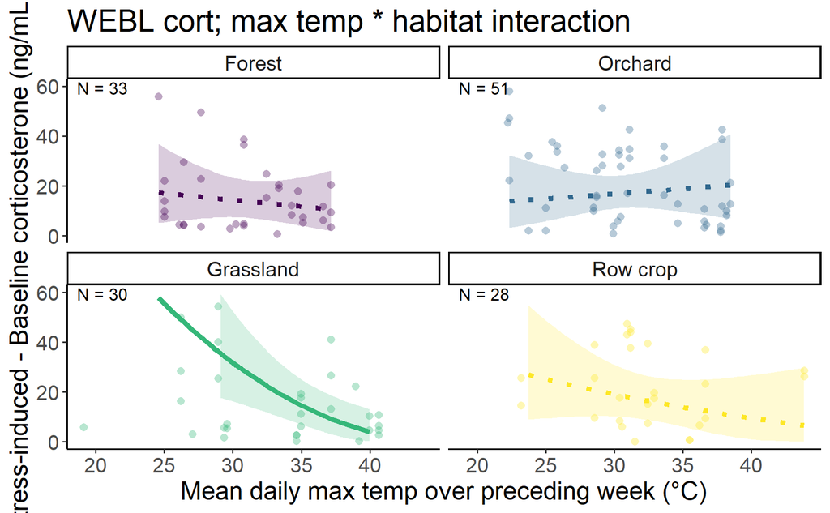

```r
samp <- abs_lintemp@frame %>% group_by(habitat) %>% summarize(count = n())
# samp %>% gt() %>% gtsave("figures/ss_webl_abs.html")


dat_text_webl <- data.frame(
  label = paste("N =",samp$count),
  group   = factor(c("Forest","Orchard","Grassland","Row crop"))
)

data_webl = dplyr::filter(g,Species == "WEBL",!is.na(meanmaxtempI),!is.na(meanmintempI)) %>%
  mutate(across(c(gweight,meanmaxtempI,meanmintempI,juliandate,brood_size,age),
                ~ scale(.x)[,1],
                .names = "{.col}_scaled"),
         meanmaxtempI_scaled_sq = meanmaxtempI_scaled * meanmaxtempI_scaled)


mean_temp_webl <- mean(data_webl %>% pull(meanmaxtempI))
sd_temp_webl <- sd(data_webl %>% pull(meanmaxtempI))


temp_trans_webl <- trans_new("temp_trans_webl",
                             transform = function(x){(x * sd_temp_webl) + mean_temp_webl},
                             inverse = function(x){x})

(fig4_webl <- ggpredict(prior_model,terms = c("meanmaxtempI_scaled [all]","habitat"),bias_correction = TRUE) %>%
    plot(line_size = 1.5,alpha = .2,show_data = TRUE,limit_range = TRUE) +
    aes(linetype = .data[["group"]]) +
    theme_classic() +
    facet_wrap(~ group, ncol = 2) +
    xlab("Mean daily max temp over preceding week (\u00b0C)") +
    ylab("Stress-induced - Baseline corticosterone (ng/mL)") +
    scale_fill_viridis(discrete = TRUE) +
    scale_color_viridis(discrete = TRUE) +
    theme(text = element_text(size = 16)) +
    labs(title = "WEBL cort; max temp * habitat interaction") +
    scale_x_continuous(trans = temp_trans_webl,
                       breaks = c((20-mean_temp_webl)/sd_temp_webl,
                                  (25-mean_temp_webl)/sd_temp_webl,
                                  (30-mean_temp_webl)/sd_temp_webl,
                                  (35-mean_temp_webl)/sd_temp_webl,
                                  (40-mean_temp_webl)/sd_temp_webl),
                       # breaks = c(20,30,40,50),
                       # labels = c("20","30","40","50"),
                       # limits = c((15-mean(g$meanmaxtempI,na.rm = TRUE))/sd(g$meanmaxtempI,na.rm = TRUE),
                       #            (55-mean(g$meanmaxtempI,na.rm = TRUE))/sd(g$meanmaxtempI,na.rm = TRUE))
                       # limits = c(18,5)
    ) +
    scale_linetype_manual(values = c("Forest" = "dotted","Orchard" = "dotted","Grassland" = "solid","Row crop" = "dotted")) +
    ylim(0,60) +
    geom_text(data = dat_text_webl, mapping = aes(x = -Inf, y = Inf,label = label),hjust = -.2, vjust = 1.2,inherit.aes = FALSE) +
    theme(legend.position = "none")
)
```

```
G3;Model has sqrt-transformed response. Back-transforming predictions to original response scale. Standard
  errors are still on the transformed scale.
gG3;Data points may overlap. Use the `jitter` argument to add some amount of random variation to the
  location of data points and avoid overplotting.
gScale for colour is already present.
```

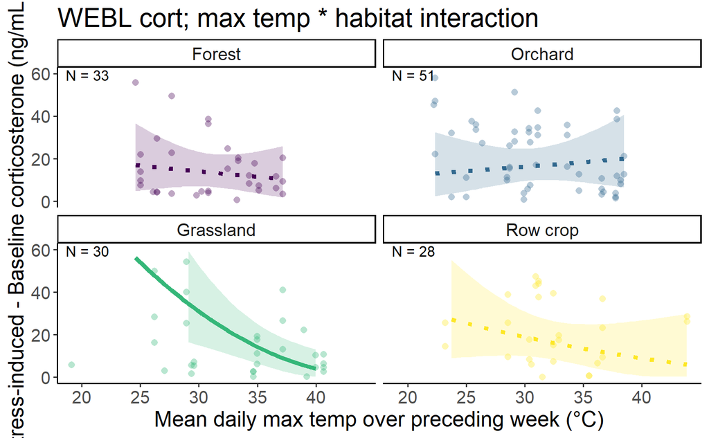

```r
(fig4_webl <- ggpredict(abs_lintemp,terms = c("meanmaxtempI_scaled [all]","habitat"),bias_correction = TRUE) %>%
    plot(line_size = 1.5,alpha = .2,show_data = TRUE,limit_range = TRUE) +
    aes(linetype = .data[["group"]]) +
    theme_classic() +
    facet_wrap(~ group, ncol = 2) +
    xlab("Mean daily max temp over preceding week (\u00b0C)") +
    ylab("Stress-induced - Baseline corticosterone (ng/mL)") +
    scale_fill_viridis(discrete = TRUE) +
    scale_color_viridis(discrete = TRUE) +
    theme(text = element_text(size = 16)) +
    labs(title = "WEBL cort; max temp * habitat interaction") +
    scale_x_continuous(trans = temp_trans_webl,
                       breaks = c((20-mean_temp_webl)/sd_temp_webl,
                                  (25-mean_temp_webl)/sd_temp_webl,
                                  (30-mean_temp_webl)/sd_temp_webl,
                                  (35-mean_temp_webl)/sd_temp_webl,
                                  (40-mean_temp_webl)/sd_temp_webl),
                       # breaks = c(20,30,40,50),
                       # labels = c("20","30","40","50"),
                       # limits = c((15-mean(g$meanmaxtempI,na.rm = TRUE))/sd(g$meanmaxtempI,na.rm = TRUE),
                       #            (55-mean(g$meanmaxtempI,na.rm = TRUE))/sd(g$meanmaxtempI,na.rm = TRUE))
                       # limits = c(18,5)
    ) +
    scale_linetype_manual(values = c("Forest" = "dotted","Orchard" = "dotted","Grassland" = "solid","Row crop" = "dotted")) +
    ylim(0,60) +
    geom_text(data = dat_text_webl, mapping = aes(x = -Inf, y = Inf,label = label),hjust = -.2, vjust = 1.2,inherit.aes = FALSE) +
    theme(legend.position = "none")
)
```

##### Visualize interaction

```
G3;Model has sqrt-transformed response. Back-transforming predictions to original response scale. Standard
  errors are still on the transformed scale.
gG3;Data points may overlap. Use the `jitter` argument to add some amount of random variation to the
  location of data points and avoid overplotting.
g
```

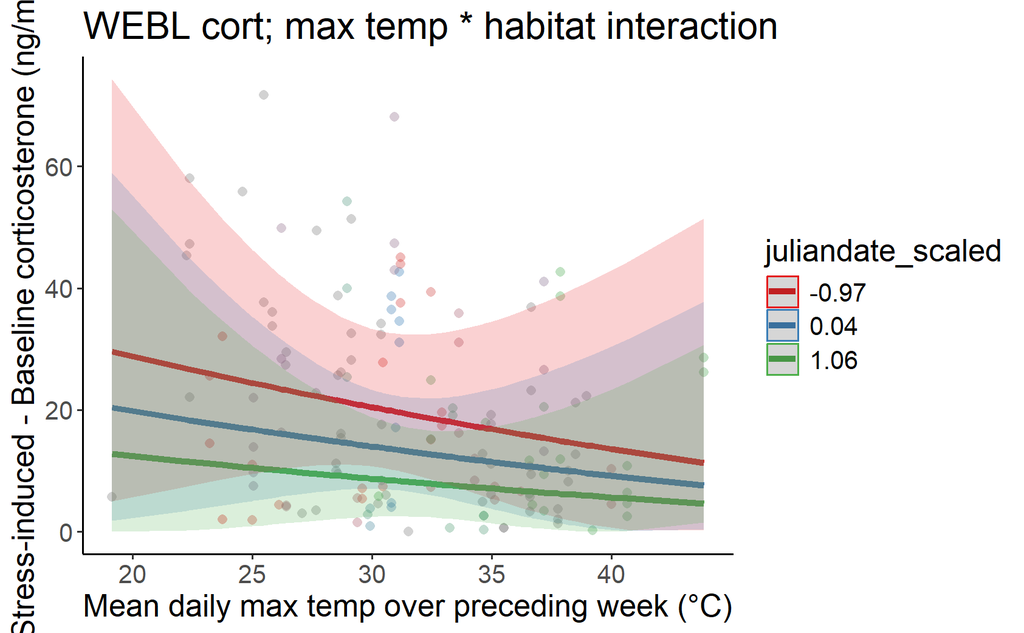

```r
(fig4_webl <- ggpredict(abs_lintemp,terms = c("meanmaxtempI_scaled [all]","juliandate_scaled"),bias_correction = TRUE) %>%
    plot(line_size = 1.5,alpha = .2,show_data = TRUE,limit_range = TRUE) +
    # aes(linetype = .data[["group"]]) +
    theme_classic() +
    # facet_wrap(~ group, ncol = 2) +
    xlab("Mean daily max temp over preceding week (\u00b0C)") +
    ylab("Stress-induced - Baseline corticosterone (ng/mL)") +
    # scale_fill_viridis(discrete = TRUE) +
    # scale_color_viridis(discrete = TRUE) +
    theme(text = element_text(size = 16)) +
    labs(title = "WEBL cort; max temp * habitat interaction") +
    scale_x_continuous(trans = temp_trans_webl,
                       breaks = c((20-mean_temp_webl)/sd_temp_webl,
                                  (25-mean_temp_webl)/sd_temp_webl,
                                  (30-mean_temp_webl)/sd_temp_webl,
                                  (35-mean_temp_webl)/sd_temp_webl,
                                  (40-mean_temp_webl)/sd_temp_webl),
                       # breaks = c(20,30,40,50),
                       # labels = c("20","30","40","50"),
                       # limits = c((15-mean(g$meanmaxtempI,na.rm = TRUE))/sd(g$meanmaxtempI,na.rm = TRUE),
                       #            (55-mean(g$meanmaxtempI,na.rm = TRUE))/sd(g$meanmaxtempI,na.rm = TRUE))
                       # limits = c(18,5)
    ) # +
    # scale_linetype_manual(values = c("Forest" = "dotted","Orchard" = "dotted","Grassland" = "solid","Row crop" = "dotted")) +
    # ylim(0,60) +
    # geom_text(data = dat_text_webl, mapping = aes(x = -Inf, y = Inf,label = label),hjust = -.2, vjust = 1.2,inherit.aes = FALSE) +
    # theme(legend.position = "none")
)
```

No interaction!

#### TRES

```r
prior_model <- lmerTest::lmer(sqrt(abs_change_cort) ~ meanmaxtempI_scaled * habitat + meanmintempI_scaled * habitat + age_scaled + juliandate_scaled + year_fct + (1|attempt_id),data = dplyr::filter(g,Species == "TRES",!is.na(meanmaxtempI),!is.na(meanmintempI)) %>%
                                mutate(across(c(gweight,meanmaxtempI,meanmintempI,juliandate,brood_size,age),
                                              ~ scale(.x)[,1],
                                              .names = "{.col}_scaled"),
                                       meanmaxtempI_scaled_sq = meanmaxtempI_scaled * meanmaxtempI_scaled))

abs_lintemp <- lmerTest::lmer(sqrt(abs_change_cort) ~ meanmaxtempI_scaled * habitat + meanmintempI_scaled * habitat + age_scaled + meanmaxtempI_scaled * juliandate_scaled + year_fct + (1|attempt_id),data = dplyr::filter(g,Species == "TRES",!is.na(meanmaxtempI),!is.na(meanmintempI)) %>%
                                mutate(across(c(gweight,meanmaxtempI,meanmintempI,juliandate,brood_size,age),
                                              ~ scale(.x)[,1],
                                              .names = "{.col}_scaled"),
                                       meanmaxtempI_scaled_sq = meanmaxtempI_scaled * meanmaxtempI_scaled))

abs_lintemp_addmax <- lmerTest::lmer(sqrt(abs_change_cort) ~ meanmaxtempI_scaled + meanmintempI_scaled * habitat + age_scaled + meanmaxtempI_scaled * juliandate_scaled + year_fct + (1|attempt_id),data = dplyr::filter(g,Species == "TRES",!is.na(meanmaxtempI),!is.na(meanmintempI)) %>%
                                       mutate(across(c(gweight,meanmaxtempI,meanmintempI,juliandate,brood_size,age),
                                                     ~ scale(.x)[,1],
                                                     .names = "{.col}_scaled"),
                                              meanmaxtempI_scaled_sq = meanmaxtempI_scaled * meanmaxtempI_scaled))

prior_model_addmin <- lmerTest::lmer(sqrt(abs_change_cort) ~ meanmaxtempI_scaled * habitat + meanmintempI_scaled + age_scaled + juliandate_scaled + year_fct + (1|attempt_id),data = dplyr::filter(g,Species == "TRES",!is.na(meanmaxtempI),!is.na(meanmintempI)) %>%
                                       mutate(across(c(gweight,meanmaxtempI,meanmintempI,juliandate,brood_size,age),
                                                     ~ scale(.x)[,1],
                                                     .names = "{.col}_scaled"),
                                              meanmaxtempI_scaled_sq = meanmaxtempI_scaled * meanmaxtempI_scaled))

abs_lintemp_addmin <- lmerTest::lmer(sqrt(abs_change_cort) ~ meanmaxtempI_scaled * habitat + meanmintempI_scaled + age_scaled + meanmaxtempI_scaled * juliandate_scaled + year_fct + (1|attempt_id),data = dplyr::filter(g,Species == "TRES",!is.na(meanmaxtempI),!is.na(meanmintempI)) %>%
                                       mutate(across(c(gweight,meanmaxtempI,meanmintempI,juliandate,brood_size,age),
                                                     ~ scale(.x)[,1],
                                                     .names = "{.col}_scaled"),
                                              meanmaxtempI_scaled_sq = meanmaxtempI_scaled * meanmaxtempI_scaled))

abs_lintemp_noint <- lmerTest::lmer(sqrt(abs_change_cort) ~ meanmaxtempI_scaled + meanmintempI_scaled + habitat + age_scaled + meanmaxtempI_scaled * juliandate_scaled + year_fct + (1|attempt_id),data = dplyr::filter(g,Species == "TRES",!is.na(meanmaxtempI),!is.na(meanmintempI)) %>%
                                      mutate(across(c(gweight,meanmaxtempI,meanmintempI,juliandate,brood_size,age),
                                                    ~ scale(.x)[,1],
                                                    .names = "{.col}_scaled"),
                                             meanmaxtempI_scaled_sq = meanmaxtempI_scaled * meanmaxtempI_scaled))

c1 <- anova(abs_lintemp,abs_lintemp_addmin,abs_lintemp_noint) %>% tibble() %>% mutate(Model = c("no interaction","single interaction","both interacting"),.before = npar)
```

```
G3;refitting model(s) with ML (instead of REML)
g
```

```r
c2 <- anova(abs_lintemp,abs_lintemp_addmax,abs_lintemp_noint) %>% tibble() %>% mutate(Model = c("no interaction","single interaction","both interacting"),.before = npar)
```

```
G3;refitting model(s) with ML (instead of REML)
g
```

```r
(int_tab_abs_tres <- bind_rows(c1,c2) %>%
    as.tibble() %>%
    mutate(across(where(is.numeric),~round(.x,digits = 3)),
           P = `Pr(>Chisq)`) %>%
    dplyr::select(Model,AIC,Chisq,P) %>%
    mutate(max_or_min = c(rep("Max temp",times = 3),rep("Min temp",times = 3)),
           across(c(AIC,Chisq), ~ round(.x, digits = 2)),
           P = if_else(P < 0.001,"<0.001",as.character(P))) %>%
    group_by(max_or_min) %>% gt())
```

| Model | AIC | Chisq | P |
| --- | --- | --- | --- |
| Max temp |  |  |  |
| no interaction | 348.25 | NA | NA |
| single interaction | 344.98 | 9.27 | 0.026 |
| both interacting | 344.87 | 6.12 | 0.106 |
| Min temp |  |  |  |
| no interaction | 348.25 | NA | NA |
| single interaction | 352.86 | 1.39 | 0.708 |
| both interacting | 344.87 | 13.99 | 0.003 |

```r
# gtsave(int_tab_abs_tres,"figures/int_tab_abs_tres.html")

abs_tres <- abs_lintemp

summary(abs_lintemp)
```

```
Linear mixed model fit by REML. t-tests use Satterthwaite's method ['lmerModLmerTest']
Formula: sqrt(abs_change_cort) ~ meanmaxtempI_scaled * habitat + meanmintempI_scaled *
    habitat + age_scaled + meanmaxtempI_scaled * juliandate_scaled +      year_fct + (1 | attempt_id)
   Data: dplyr::filter(g, Species == "TRES", !is.na(meanmaxtempI), !is.na(meanmintempI)) %>%
    mutate(across(c(gweight, meanmaxtempI, meanmintempI, juliandate,
        brood_size, age), ~scale(.x)[, 1], .names = "{.col}_scaled"),
        meanmaxtempI_scaled_sq = meanmaxtempI_scaled * meanmaxtempI_scaled)

REML criterion at convergence: 299.7

Scaled residuals:
     Min       1Q   Median       3Q      Max
-2.19919 -0.44841  0.07252  0.45926  2.13480

Random effects:
 Groups     Name        Variance Std.Dev.
 attempt_id (Intercept) 0.7929   0.8904
 Residual               2.9315   1.7121
Number of obs: 80, groups:  attempt_id, 38

Fixed effects:
                                      Estimate Std. Error       df t value Pr(>|t|)
(Intercept)                            5.14205    1.79977 27.02612   2.857  0.00813 **
meanmaxtempI_scaled                   -0.01625    1.21203 19.61723  -0.013  0.98944
habitatOrchard                        -1.89050    2.02542 25.12134  -0.933  0.35950
habitatGrassland                      -0.19533    1.74994 27.21020  -0.112  0.91194
habitatRow crop                        0.28297    1.85504 27.65110   0.153  0.87987
meanmintempI_scaled                    0.47867    1.20222 26.60680   0.398  0.69369
age_scaled                             0.44394    0.39511 28.97532   1.124  0.27042
juliandate_scaled                     -0.09183    0.33727 18.35065  -0.272  0.78844
year_fct2023                           0.84558    0.67917 18.74338   1.245  0.22847
meanmaxtempI_scaled:habitatOrchard    -3.78807    1.99799 18.26731  -1.896  0.07390 .
meanmaxtempI_scaled:habitatGrassland   1.96710    1.52975 18.89012   1.286  0.21402
meanmaxtempI_scaled:habitatRow crop    0.67682    1.49758 18.33562   0.452  0.65661
habitatOrchard:meanmintempI_scaled    -3.00167    1.65631 24.25576  -1.812  0.08234 .
habitatGrassland:meanmintempI_scaled  -0.85229    1.23591 26.93705  -0.690  0.49634
habitatRow crop:meanmintempI_scaled   -0.37606    1.51061 24.60833  -0.249  0.80547
meanmaxtempI_scaled:juliandate_scaled -0.53143    0.45066 22.32272  -1.179  0.25072
---
Signif. codes:  0 '***' 0.001 '**' 0.01 '*' 0.05 '.' 0.1 ' ' 1
```

```
G3;
Correlation matrix not shown by default, as p = 16 > 12.
Use print(x, correlation=TRUE)  or
    vcov(x)        if you need it

g
```

```r
anova(abs_lintemp,prior_model)
```

```
G3;refitting model(s) with ML (instead of REML)
g
```

```
Data: dplyr::filter(g, Species == "TRES", !is.na(meanmaxtempI), !is.na(meanmintempI)) %>%  ...
Models:
prior_model: sqrt(abs_change_cort) ~ meanmaxtempI_scaled * habitat + meanmintempI_scaled * habitat + age_scaled + juliandate_scaled + year_fct + (1 | attempt_id)
abs_lintemp: sqrt(abs_change_cort) ~ meanmaxtempI_scaled * habitat + meanmintempI_scaled * habitat + age_scaled + meanmaxtempI_scaled * juliandate_scaled + year_fct + (1 | attempt_id)
            npar    AIC    BIC  logLik deviance  Chisq Df Pr(>Chisq)
prior_model   17 345.00 385.50 -155.50   311.00
abs_lintemp   18 344.87 387.74 -154.43   308.87 2.1336  1     0.1441
```

```r
summary(abs_lintemp_addmin)
```

```
Linear mixed model fit by REML. t-tests use Satterthwaite's method ['lmerModLmerTest']
Formula: sqrt(abs_change_cort) ~ meanmaxtempI_scaled * habitat + meanmintempI_scaled +
    age_scaled + meanmaxtempI_scaled * juliandate_scaled + year_fct +      (1 | attempt_id)
   Data: dplyr::filter(g, Species == "TRES", !is.na(meanmaxtempI), !is.na(meanmintempI)) %>%
    mutate(across(c(gweight, meanmaxtempI, meanmintempI, juliandate,
        brood_size, age), ~scale(.x)[, 1], .names = "{.col}_scaled"),
        meanmaxtempI_scaled_sq = meanmaxtempI_scaled * meanmaxtempI_scaled)

REML criterion at convergence: 310.2

Scaled residuals:
     Min       1Q   Median       3Q      Max
-2.09654 -0.48543  0.08953  0.46443  2.22980

Random effects:
 Groups     Name        Variance Std.Dev.
 attempt_id (Intercept) 0.8858   0.9412
 Residual               2.9298   1.7117
Number of obs: 80, groups:  attempt_id, 38

Fixed effects:
                                      Estimate Std. Error       df t value Pr(>|t|)
(Intercept)                            5.99460    1.57700 22.35444   3.801 0.000957 ***
meanmaxtempI_scaled                    0.35195    1.11446 21.41316   0.316 0.755212
habitatOrchard                        -1.71160    1.80530 22.95784  -0.948 0.352954
habitatGrassland                      -0.91998    1.55794 22.42793  -0.591 0.560754
habitatRow crop                        0.02921    1.53576 20.72112   0.019 0.985006
meanmintempI_scaled                   -0.43406    0.43055 22.04115  -1.008 0.324317
age_scaled                             0.48376    0.39069 31.12896   1.238 0.224894
juliandate_scaled                     -0.18439    0.33876 20.74336  -0.544 0.592024
year_fct2023                           0.50831    0.62180 19.32949   0.817 0.423612
meanmaxtempI_scaled:habitatOrchard    -2.32710    1.68775 21.64473  -1.379 0.182036
meanmaxtempI_scaled:habitatGrassland   1.82192    1.32864 19.51747   1.371 0.185853
meanmaxtempI_scaled:habitatRow crop    0.69536    1.39341 19.87978   0.499 0.623231
meanmaxtempI_scaled:juliandate_scaled -0.65039    0.44274 25.97160  -1.469 0.153834
---
Signif. codes:  0 '***' 0.001 '**' 0.01 '*' 0.05 '.' 0.1 ' ' 1
```

```
G3;
Correlation matrix not shown by default, as p = 13 > 12.
Use print(x, correlation=TRUE)  or
    vcov(x)        if you need it

g
```

```r
anova(abs_lintemp_addmin,prior_model_addmin)
```

```
G3;refitting model(s) with ML (instead of REML)
g
```

```
Data: dplyr::filter(g, Species == "TRES", !is.na(meanmaxtempI), !is.na(meanmintempI)) %>%  ...
Models:
prior_model_addmin: sqrt(abs_change_cort) ~ meanmaxtempI_scaled * habitat + meanmintempI_scaled + age_scaled + juliandate_scaled + year_fct + (1 | attempt_id)
abs_lintemp_addmin: sqrt(abs_change_cort) ~ meanmaxtempI_scaled * habitat + meanmintempI_scaled + age_scaled + meanmaxtempI_scaled * juliandate_scaled + year_fct + (1 | attempt_id)
                   npar    AIC    BIC  logLik deviance  Chisq Df Pr(>Chisq)
prior_model_addmin   14 346.03 379.38 -159.01   318.03
abs_lintemp_addmin   15 344.98 380.71 -157.49   314.98 3.0471  1    0.08088 .
---
Signif. codes:  0 '***' 0.001 '**' 0.01 '*' 0.05 '.' 0.1 ' ' 1
```

```r
(tresabstrendmax_prior <- emtrends(prior_model,specs = ~ habitat, var = c("meanmaxtempI_scaled")) %>% test() %>%
    mutate(across(where(is.numeric), ~ round(.x, digits = 3)),
           df = round(df),
           p.value = if_else(p.value == 0.000,"<0.001",as.character(p.value))) %>%
    rename(Habitat = "habitat", `Max temp trend` = "meanmaxtempI_scaled.trend",Df = "df", `T-ratio` = "t.ratio", P = "p.value") %>%
    gt())
```

| Habitat | Max temp trend | SE | Df | T-ratio | P |
| --- | --- | --- | --- | --- | --- |
| Forest | 0.231 | 1.209 | 22 | 0.191 | 0.85 |
| Orchard | -3.633 | 1.664 | 17 | -2.184 | 0.043 |
| Grassland | 1.445 | 0.821 | 41 | 1.760 | 0.086 |
| Row crop | 0.170 | 0.779 | 20 | 0.218 | 0.829 |

```r
(tresabstrendmax <- emtrends(prior_model_addmin,specs = ~ habitat, var = c("meanmaxtempI_scaled")) %>% test() %>%
    mutate(across(where(is.numeric), ~ round(.x, digits = 3)),
           df = round(df),
           p.value = if_else(p.value == 0.000,"<0.001",as.character(p.value))) %>%
    rename(Habitat = "habitat", `Max temp trend` = "meanmaxtempI_scaled.trend",Df = "df", `T-ratio` = "t.ratio", P = "p.value") %>%
    gt())
```

| Habitat | Max temp trend | SE | Df | T-ratio | P |
| --- | --- | --- | --- | --- | --- |
| Forest | 0.746 | 1.114 | 25 | 0.670 | 0.509 |
| Orchard | -1.544 | 1.359 | 23 | -1.136 | 0.268 |
| Grassland | 1.645 | 0.748 | 44 | 2.200 | 0.033 |
| Row crop | 0.329 | 0.680 | 29 | 0.484 | 0.632 |

```r
(tresabstrendmax <- emtrends(abs_lintemp_addmin,specs = ~ habitat, var = c("meanmaxtempI_scaled")) %>% test() %>%
    mutate(across(where(is.numeric), ~ round(.x, digits = 3)),
           df = round(df),
           p.value = if_else(p.value == 0.000,"<0.001",as.character(p.value))) %>%
    rename(Habitat = "habitat", `Max temp trend` = "meanmaxtempI_scaled.trend",Df = "df", `T-ratio` = "t.ratio", P = "p.value") %>%
    gt())
```

| Habitat | Max temp trend | SE | Df | T-ratio | P |
| --- | --- | --- | --- | --- | --- |
| Forest | 0.157 | 1.165 | 21 | 0.135 | 0.894 |
| Orchard | -2.170 | 1.405 | 21 | -1.545 | 0.137 |
| Grassland | 1.979 | 0.768 | 32 | 2.577 | 0.015 |
| Row crop | 0.853 | 0.756 | 24 | 1.127 | 0.271 |

There are differences between the final outcome of these two analyses, but those are mostly because of the different structure of the most supported model. The direction of the estimated trends are the same.

```r
samp <- abs_lintemp@frame %>% group_by(habitat) %>% summarize(count = n())
# samp %>% gt() %>% gtsave("figures/ss_tres_abs.html")


dat_text_tres <- data.frame(
  label = paste("N =",samp$count),
  group   = factor(c("Forest","Orchard","Grassland","Row crop"))
)



summary(abs_lintemp)
```

```
Linear mixed model fit by REML. t-tests use Satterthwaite's method ['lmerModLmerTest']
Formula: sqrt(abs_change_cort) ~ meanmaxtempI_scaled * habitat + meanmintempI_scaled *
    habitat + age_scaled + meanmaxtempI_scaled * juliandate_scaled +      year_fct + (1 | attempt_id)
   Data: dplyr::filter(g, Species == "TRES", !is.na(meanmaxtempI), !is.na(meanmintempI)) %>%
    mutate(across(c(gweight, meanmaxtempI, meanmintempI, juliandate,
        brood_size, age), ~scale(.x)[, 1], .names = "{.col}_scaled"),
        meanmaxtempI_scaled_sq = meanmaxtempI_scaled * meanmaxtempI_scaled)

REML criterion at convergence: 299.7

Scaled residuals:
     Min       1Q   Median       3Q      Max
-2.19919 -0.44841  0.07252  0.45926  2.13480

Random effects:
 Groups     Name        Variance Std.Dev.
 attempt_id (Intercept) 0.7929   0.8904
 Residual               2.9315   1.7121
Number of obs: 80, groups:  attempt_id, 38

Fixed effects:
                                      Estimate Std. Error       df t value Pr(>|t|)
(Intercept)                            5.14205    1.79977 27.02612   2.857  0.00813 **
meanmaxtempI_scaled                   -0.01625    1.21203 19.61723  -0.013  0.98944
habitatOrchard                        -1.89050    2.02542 25.12134  -0.933  0.35950
habitatGrassland                      -0.19533    1.74994 27.21020  -0.112  0.91194
habitatRow crop                        0.28297    1.85504 27.65110   0.153  0.87987
meanmintempI_scaled                    0.47867    1.20222 26.60680   0.398  0.69369
age_scaled                             0.44394    0.39511 28.97532   1.124  0.27042
juliandate_scaled                     -0.09183    0.33727 18.35065  -0.272  0.78844
year_fct2023                           0.84558    0.67917 18.74338   1.245  0.22847
meanmaxtempI_scaled:habitatOrchard    -3.78807    1.99799 18.26731  -1.896  0.07390 .
meanmaxtempI_scaled:habitatGrassland   1.96710    1.52975 18.89012   1.286  0.21402
meanmaxtempI_scaled:habitatRow crop    0.67682    1.49758 18.33562   0.452  0.65661
habitatOrchard:meanmintempI_scaled    -3.00167    1.65631 24.25576  -1.812  0.08234 .
habitatGrassland:meanmintempI_scaled  -0.85229    1.23591 26.93705  -0.690  0.49634
habitatRow crop:meanmintempI_scaled   -0.37606    1.51061 24.60833  -0.249  0.80547
meanmaxtempI_scaled:juliandate_scaled -0.53143    0.45066 22.32272  -1.179  0.25072
---
Signif. codes:  0 '***' 0.001 '**' 0.01 '*' 0.05 '.' 0.1 ' ' 1
```

```
G3;
Correlation matrix not shown by default, as p = 16 > 12.
Use print(x, correlation=TRUE)  or
    vcov(x)        if you need it

g
```

```r
check_collinearity(abs_lintemp_noint)
```

```
# Check for Multicollinearity

Low Correlation

                                  Term  VIF   VIF 95% CI Increased SE Tolerance Tolerance 95% CI
                   meanmaxtempI_scaled 3.14 [2.35, 4.38]         1.77      0.32     [0.23, 0.42]
                   meanmintempI_scaled 1.88 [1.49, 2.57]         1.37      0.53     [0.39, 0.67]
                               habitat 2.05 [1.61, 2.81]         1.43      0.49     [0.36, 0.62]
                            age_scaled 1.28 [1.10, 1.79]         1.13      0.78     [0.56, 0.91]
                     juliandate_scaled 2.02 [1.58, 2.77]         1.42      0.50     [0.36, 0.63]
                              year_fct 1.49 [1.23, 2.03]         1.22      0.67     [0.49, 0.81]
 meanmaxtempI_scaled:juliandate_scaled 1.32 [1.13, 1.83]         1.15      0.76     [0.55, 0.89]
```

```
G3;Model has sqrt-transformed response. Back-transforming predictions to original response scale. Standard
  errors are still on the transformed scale.
gG3;Data points may overlap. Use the `jitter` argument to add some amount of random variation to the
  location of data points and avoid overplotting.
gScale for colour is already present.
```

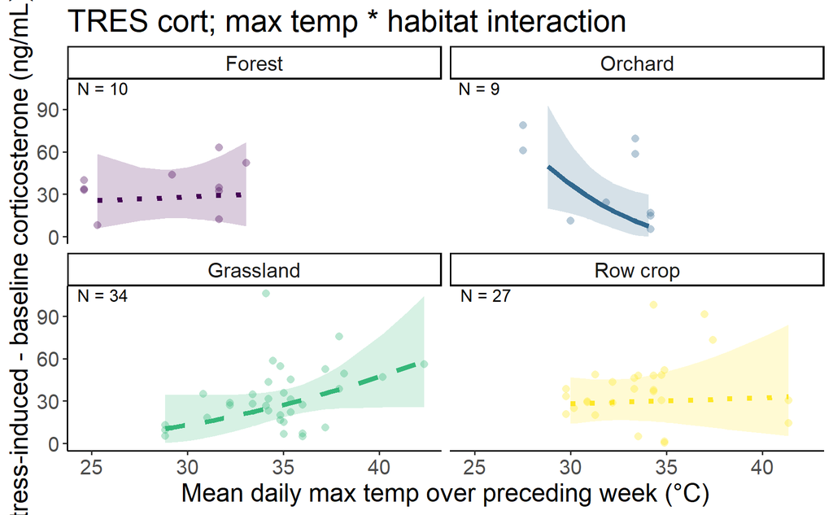

```r
data_tres = dplyr::filter(g,Species == "TRES",!is.na(meanmaxtempI),!is.na(meanmintempI)) %>%
  mutate(across(c(gweight,meanmaxtempI,meanmintempI,juliandate,brood_size,age),
                ~ scale(.x)[,1],
                .names = "{.col}_scaled"),
         meanmaxtempI_scaled_sq = meanmaxtempI_scaled * meanmaxtempI_scaled)


mean_temp_tres <- mean(data_tres %>% pull(meanmaxtempI))
sd_temp_tres <- sd(data_tres %>% pull(meanmaxtempI))


temp_trans_tres <- trans_new("temp_trans_tres",
                             transform = function(x){(x * sd_temp_tres) + mean_temp_tres},
                             inverse = function(x){x})

(fig4_tres <- ggpredict(prior_model,terms = c("meanmaxtempI_scaled [all]","habitat"),bias_correction = TRUE) %>%
    plot(line_size = 1.5,alpha = .2,show_data = TRUE,limit_range = TRUE) +
    aes(linetype = .data[["group"]]) +
    theme_classic() +
    facet_wrap(~ group, ncol = 2) +
    xlab("Mean daily max temp over preceding week (\u00b0C)") +
    ylab("Stress-induced - baseline corticosterone (ng/mL)") +
    scale_fill_viridis(discrete = TRUE) +
    scale_color_viridis(discrete = TRUE) +
    theme(text = element_text(size = 16)) +
    labs(title = "TRES cort; max temp * habitat interaction") +
    scale_x_continuous(trans = temp_trans_tres,
                       breaks = c((20-mean_temp_tres)/sd_temp_tres,
                                  (25-mean_temp_tres)/sd_temp_tres,
                                  (30-mean_temp_tres)/sd_temp_tres,
                                  (35-mean_temp_tres)/sd_temp_tres,
                                  (40-mean_temp_tres)/sd_temp_tres),
                       # breaks = c(20,30,40,50),
                       # labels = c("20","30","40","50"),
                       # limits = c((15-mean(g$meanmaxtempI,na.rm = TRUE))/sd(g$meanmaxtempI,na.rm = TRUE),
                       #            (55-mean(g$meanmaxtempI,na.rm = TRUE))/sd(g$meanmaxtempI,na.rm = TRUE))
                       # limits = c(18,5)
    ) +
    scale_linetype_manual(values = c("Forest" = "dotted","Orchard" = "solid","Grassland" = "dashed","Row crop" = "dotted")) +
    #ylim(-5,5) +
    geom_text(data = dat_text_tres, mapping = aes(x = -Inf, y = Inf,label = label),hjust = -.2, vjust = 1.2,inherit.aes = FALSE) +
    theme(legend.position = "none")
)
```

```
G3;Model has sqrt-transformed response. Back-transforming predictions to original response scale. Standard
  errors are still on the transformed scale.
gG3;Data points may overlap. Use the `jitter` argument to add some amount of random variation to the
  location of data points and avoid overplotting.
gScale for colour is already present.
```

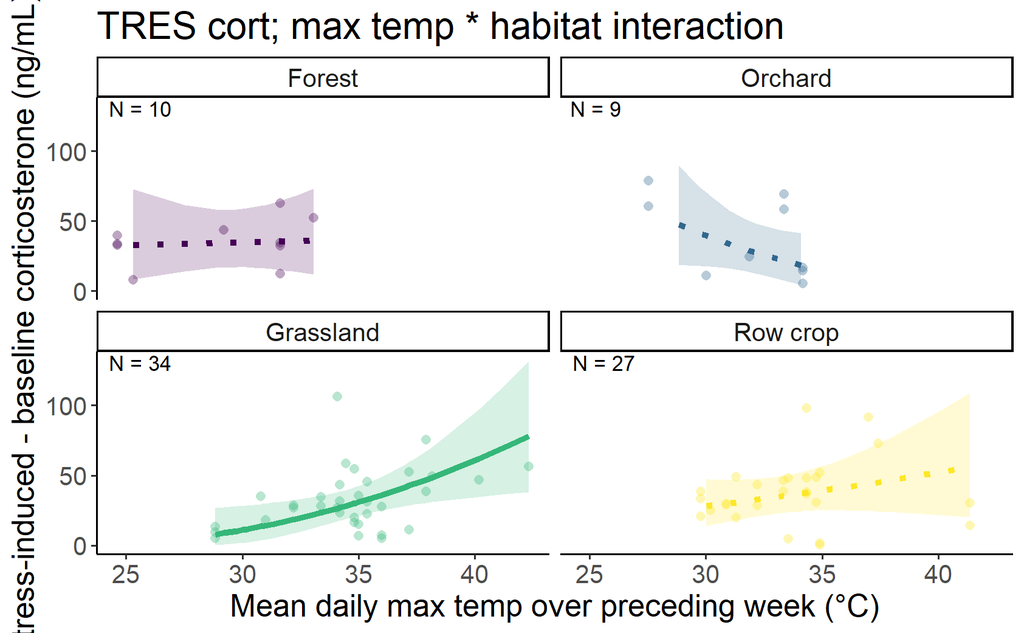

```r
(fig4_tres <- ggpredict(abs_lintemp_addmin,terms = c("meanmaxtempI_scaled [all]","habitat"),bias_correction = TRUE) %>%
    plot(line_size = 1.5,alpha = .2,show_data = TRUE,limit_range = TRUE) +
    aes(linetype = .data[["group"]]) +
    theme_classic() +
    facet_wrap(~ group, ncol = 2) +
    xlab("Mean daily max temp over preceding week (\u00b0C)") +
    ylab("Stress-induced - baseline corticosterone (ng/mL)") +
    scale_fill_viridis(discrete = TRUE) +
    scale_color_viridis(discrete = TRUE) +
    theme(text = element_text(size = 16)) +
    labs(title = "TRES cort; max temp * habitat interaction") +
    scale_x_continuous(trans = temp_trans_tres,
                       breaks = c((20-mean_temp_tres)/sd_temp_tres,
                                  (25-mean_temp_tres)/sd_temp_tres,
                                  (30-mean_temp_tres)/sd_temp_tres,
                                  (35-mean_temp_tres)/sd_temp_tres,
                                  (40-mean_temp_tres)/sd_temp_tres),
                       # breaks = c(20,30,40,50),
                       # labels = c("20","30","40","50"),
                       # limits = c((15-mean(g$meanmaxtempI,na.rm = TRUE))/sd(g$meanmaxtempI,na.rm = TRUE),
                       #            (55-mean(g$meanmaxtempI,na.rm = TRUE))/sd(g$meanmaxtempI,na.rm = TRUE))
                       # limits = c(18,5)
    ) +
    scale_linetype_manual(values = c("Forest" = "dotted","Orchard" = "dotted","Grassland" = "solid","Row crop" = "dotted")) +
    #ylim(-5,5) +
    geom_text(data = dat_text_tres, mapping = aes(x = -Inf, y = Inf,label = label),hjust = -.2, vjust = 1.2,inherit.aes = FALSE) +
    theme(legend.position = "none")
)
```

Honestly the results here seem easier to explain.

```
G3;Model has sqrt-transformed response. Back-transforming predictions to original response scale. Standard
  errors are still on the transformed scale.
gG3;Data points may overlap. Use the `jitter` argument to add some amount of random variation to the
  location of data points and avoid overplotting.
g
```

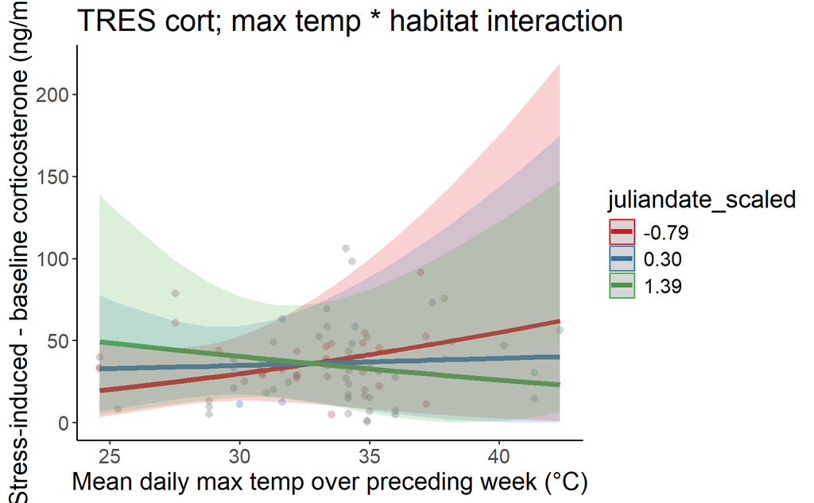

```r
(fig4_tres <- ggpredict(abs_lintemp_addmin,terms = c("meanmaxtempI_scaled [all]","juliandate_scaled"),bias_correction = TRUE) %>%
    plot(line_size = 1.5,alpha = .2,show_data = TRUE,limit_range = TRUE) +
    # aes(linetype = .data[["group"]]) +
    theme_classic() +
    # facet_wrap(~ group, ncol = 2) +
    xlab("Mean daily max temp over preceding week (\u00b0C)") +
    ylab("Stress-induced - baseline corticosterone (ng/mL)") +
    # scale_fill_viridis(discrete = TRUE) +
    # scale_color_viridis(discrete = TRUE) +
    theme(text = element_text(size = 16)) +
    labs(title = "TRES cort; max temp * habitat interaction") +
    scale_x_continuous(trans = temp_trans_tres,
                       breaks = c((20-mean_temp_tres)/sd_temp_tres,
                                  (25-mean_temp_tres)/sd_temp_tres,
                                  (30-mean_temp_tres)/sd_temp_tres,
                                  (35-mean_temp_tres)/sd_temp_tres,
                                  (40-mean_temp_tres)/sd_temp_tres),
                       # breaks = c(20,30,40,50),
                       # labels = c("20","30","40","50"),
                       # limits = c((15-mean(g$meanmaxtempI,na.rm = TRUE))/sd(g$meanmaxtempI,na.rm = TRUE),
                       #            (55-mean(g$meanmaxtempI,na.rm = TRUE))/sd(g$meanmaxtempI,na.rm = TRUE))
                       # limits = c(18,5)
    ) # +
    # scale_linetype_manual(values = c("Forest" = "dotted","Orchard" = "dotted","Grassland" = "solid","Row crop" = "dotted")) +
    #ylim(-5,5) +
    # geom_text(data = dat_text_tres, mapping = aes(x = -Inf, y = Inf,label = label),hjust = -.2, vjust = 1.2,inherit.aes = FALSE) +
    # theme(legend.position = "none")
)
```

Interaciton is not significant.

### s2 cort by prior week temp

#### WEBL

```r
prior_model <- lmerTest::lmer(sqrt(cort_s2) ~ meanmaxtempI_scaled * habitat + meanmintempI_scaled * habitat + age_scaled + juliandate_scaled + year_fct + (1|attempt_id),data = dplyr::filter(g,Species == "WEBL",!is.na(meanmaxtempI),!is.na(meanmintempI)) %>%
                               mutate(across(c(gweight,meanmaxtempI,meanmintempI,juliandate,brood_size,age),
                                             ~ scale(.x)[,1],
                                             .names = "{.col}_scaled"),
                                      meanmaxtempI_scaled_sq = meanmaxtempI_scaled * meanmaxtempI_scaled))

s2_lintemp <- lmerTest::lmer(sqrt(cort_s2) ~ meanmaxtempI_scaled * habitat + meanmintempI_scaled * habitat + age_scaled + meanmaxtempI_scaled * juliandate_scaled + year_fct + (1|attempt_id),data = dplyr::filter(g,Species == "WEBL",!is.na(meanmaxtempI),!is.na(meanmintempI)) %>%
                               mutate(across(c(gweight,meanmaxtempI,meanmintempI,juliandate,brood_size,age),
                                             ~ scale(.x)[,1],
                                             .names = "{.col}_scaled"),
                                      meanmaxtempI_scaled_sq = meanmaxtempI_scaled * meanmaxtempI_scaled))

s2_lintemp_addmax <- lmerTest::lmer(sqrt(cort_s2) ~ meanmaxtempI_scaled + meanmintempI_scaled * habitat + age_scaled + meanmaxtempI_scaled * juliandate_scaled + year_fct + (1|attempt_id),data = dplyr::filter(g,Species == "WEBL",!is.na(meanmaxtempI),!is.na(meanmintempI)) %>%
                                      mutate(across(c(gweight,meanmaxtempI,meanmintempI,juliandate,brood_size,age),
                                                    ~ scale(.x)[,1],
                                                    .names = "{.col}_scaled"),
                                             meanmaxtempI_scaled_sq = meanmaxtempI_scaled * meanmaxtempI_scaled))

s2_lintemp_addmin <- lmerTest::lmer(sqrt(cort_s2) ~ meanmaxtempI_scaled * habitat + meanmintempI_scaled + age_scaled + meanmaxtempI_scaled * juliandate_scaled + year_fct + (1|attempt_id),data = dplyr::filter(g,Species == "WEBL",!is.na(meanmaxtempI),!is.na(meanmintempI)) %>%
                                      mutate(across(c(gweight,meanmaxtempI,meanmintempI,juliandate,brood_size,age),
                                                    ~ scale(.x)[,1],
                                                    .names = "{.col}_scaled"),
                                             meanmaxtempI_scaled_sq = meanmaxtempI_scaled * meanmaxtempI_scaled))

s2_lintemp_noint <- lmerTest::lmer(sqrt(cort_s2) ~ meanmaxtempI_scaled + meanmintempI_scaled + habitat + age_scaled + meanmaxtempI_scaled * juliandate_scaled + year_fct + (1|attempt_id),data = dplyr::filter(g,Species == "WEBL",!is.na(meanmaxtempI),!is.na(meanmintempI)) %>%
                                     mutate(across(c(gweight,meanmaxtempI,meanmintempI,juliandate,brood_size,age),
                                                   ~ scale(.x)[,1],
                                                   .names = "{.col}_scaled"),
                                            meanmaxtempI_scaled_sq = meanmaxtempI_scaled * meanmaxtempI_scaled))

c1 <- anova(s2_lintemp,s2_lintemp_addmin,s2_lintemp_noint) %>% tibble() %>% mutate(Model = c("no interaction","single interaction","both interacting"),.before = npar)
```

```
G3;refitting model(s) with ML (instead of REML)
g
```

```r
c2 <- anova(s2_lintemp,s2_lintemp_addmax,s2_lintemp_noint) %>% tibble() %>% mutate(Model = c("no interaction","single interaction","both interacting"),.before = npar)
```

```
G3;refitting model(s) with ML (instead of REML)
g
```

```r
(int_tab_s2_webl <- bind_rows(c1,c2) %>%
    as.tibble() %>%
    mutate(across(where(is.numeric),~round(.x,digits = 3)),
           P = `Pr(>Chisq)`) %>%
    dplyr::select(Model,AIC,Chisq,P) %>%
    mutate(max_or_min = c(rep("Max temp",times = 3),rep("Min temp",times = 3)),
           across(c(AIC,Chisq), ~ round(.x, digits = 2)),
           P = if_else(P < 0.001,"<0.001",as.character(P))) %>%
    group_by(max_or_min) %>% gt())
```

| Model | AIC | Chisq | P |
| --- | --- | --- | --- |
| Max temp |  |  |  |
| no interaction | 592.84 | NA | NA |
| single interaction | 597.97 | 0.87 | 0.833 |
| both interacting | 593.90 | 10.06 | 0.018 |
| Min temp |  |  |  |
| no interaction | 592.84 | NA | NA |
| single interaction | 592.99 | 5.84 | 0.12 |
| both interacting | 593.90 | 5.09 | 0.165 |

```r
# gtsave(int_tab_s2_webl,"figures/int_tab_s2_webl.html")

s2_webl <- s2_lintemp

summary(s2_lintemp)
```

```
Linear mixed model fit by REML. t-tests use Satterthwaite's method ['lmerModLmerTest']
Formula: sqrt(cort_s2) ~ meanmaxtempI_scaled * habitat + meanmintempI_scaled *
    habitat + age_scaled + meanmaxtempI_scaled * juliandate_scaled +      year_fct + (1 | attempt_id)
   Data: dplyr::filter(g, Species == "WEBL", !is.na(meanmaxtempI), !is.na(meanmintempI)) %>%
    mutate(across(c(gweight, meanmaxtempI, meanmintempI, juliandate,
        brood_size, age), ~scale(.x)[, 1], .names = "{.col}_scaled"),
        meanmaxtempI_scaled_sq = meanmaxtempI_scaled * meanmaxtempI_scaled)

REML criterion at convergence: 563.7

Scaled residuals:
     Min       1Q   Median       3Q      Max
-2.64592 -0.58267 -0.02042  0.51184  2.70175

Random effects:
 Groups     Name        Variance Std.Dev.
 attempt_id (Intercept) 1.594    1.262
 Residual               1.267    1.125
Number of obs: 162, groups:  attempt_id, 53

Fixed effects:
                                        Estimate Std. Error         df t value Pr(>|t|)
(Intercept)                             4.220563   0.483795  32.693862   8.724 4.76e-10 ***
meanmaxtempI_scaled                     0.007393   0.520432  88.164464   0.014   0.9887
habitatOrchard                          0.409246   0.585320  34.688866   0.699   0.4891
habitatGrassland                        1.380649   0.740916  46.868992   1.863   0.0687 .
habitatRow crop                         0.764003   0.628623  31.519275   1.215   0.2333
meanmintempI_scaled                     0.745083   0.553575  69.603719   1.346   0.1827
age_scaled                              0.062971   0.127024 144.907848   0.496   0.6208
juliandate_scaled                      -0.673819   0.297905  44.999509  -2.262   0.0286 *
year_fct2023                            0.179402   0.486398  37.022495   0.369   0.7143
meanmaxtempI_scaled:habitatOrchard      0.144410   0.666448  92.906813   0.217   0.8289
meanmaxtempI_scaled:habitatGrassland   -1.067611   0.671934 110.394335  -1.589   0.1150
meanmaxtempI_scaled:habitatRow crop    -0.317599   0.695187  78.614991  -0.457   0.6490
habitatOrchard:meanmintempI_scaled     -0.708787   0.687253  64.737712  -1.031   0.3062
habitatGrassland:meanmintempI_scaled    1.803171   0.907735 109.273257   1.986   0.0495 *
habitatRow crop:meanmintempI_scaled    -0.422513   0.688256  55.364439  -0.614   0.5418
meanmaxtempI_scaled:juliandate_scaled   0.170025   0.174477  97.343425   0.974   0.3322
---
Signif. codes:  0 '***' 0.001 '**' 0.01 '*' 0.05 '.' 0.1 ' ' 1
```

```
G3;
Correlation matrix not shown by default, as p = 16 > 12.
Use print(x, correlation=TRUE)  or
    vcov(x)        if you need it

g
```

```r
anova(s2_lintemp,prior_model)
```

```
G3;refitting model(s) with ML (instead of REML)
g
```

```
Data: dplyr::filter(g, Species == "WEBL", !is.na(meanmaxtempI), !is.na(meanmintempI)) %>%  ...
Models:
prior_model: sqrt(cort_s2) ~ meanmaxtempI_scaled * habitat + meanmintempI_scaled * habitat + age_scaled + juliandate_scaled + year_fct + (1 | attempt_id)
s2_lintemp: sqrt(cort_s2) ~ meanmaxtempI_scaled * habitat + meanmintempI_scaled * habitat + age_scaled + meanmaxtempI_scaled * juliandate_scaled + year_fct + (1 | attempt_id)
            npar    AIC    BIC  logLik deviance  Chisq Df Pr(>Chisq)
prior_model   17 593.03 645.52 -279.52   559.03
s2_lintemp    18 593.90 649.48 -278.95   557.90 1.1301  1     0.2878
```

Same model, interaction is not significant, does not add to fit

```r
(webls2trendmax_prior <- emtrends(prior_model,specs = ~ habitat, var = c("meanmaxtempI_scaled")) %>% test() %>%
    mutate(across(where(is.numeric), ~ round(.x, digits = 3)),
           df = round(df),
           p.value = if_else(p.value == 0.000,"<0.001",as.character(p.value))) %>%
    rename(Habitat = "habitat", `Max temp trend` = "meanmaxtempI_scaled.trend",Df = "df", `T-ratio` = "t.ratio", P = "p.value") %>%
    gt())
```

| Habitat | Max temp trend | SE | Df | T-ratio | P |
| --- | --- | --- | --- | --- | --- |
| Forest | 0.002 | 0.530 | 97 | 0.003 | 0.997 |
| Orchard | 0.099 | 0.457 | 129 | 0.217 | 0.829 |
| Grassland | -1.125 | 0.436 | 146 | -2.582 | 0.011 |
| Row crop | -0.215 | 0.450 | 86 | -0.479 | 0.633 |

```r
(webls2trendmax <- emtrends(s2_lintemp,specs = ~ habitat, var = c("meanmaxtempI_scaled")) %>% test() %>%
    mutate(across(where(is.numeric), ~ round(.x, digits = 3)),
           df = round(df),
           p.value = if_else(p.value == 0.000,"<0.001",as.character(p.value))) %>%
    rename(Habitat = "habitat", `Max temp trend` = "meanmaxtempI_scaled.trend",Df = "df", `T-ratio` = "t.ratio", P = "p.value") %>%
    gt())
```

| Habitat | Max temp trend | SE | Df | T-ratio | P |
| --- | --- | --- | --- | --- | --- |
| Forest | 0.018 | 0.530 | 97 | 0.034 | 0.973 |
| Orchard | 0.163 | 0.462 | 124 | 0.352 | 0.725 |
| Grassland | -1.049 | 0.443 | 146 | -2.369 | 0.019 |
| Row crop | -0.299 | 0.459 | 80 | -0.653 | 0.516 |

Same direction and significance of trends

```
G3;Model has sqrt-transformed response. Back-transforming predictions to original response scale. Standard
  errors are still on the transformed scale.
gG3;Data points may overlap. Use the `jitter` argument to add some amount of random variation to the
  location of data points and avoid overplotting.
gScale for colour is already present.
```

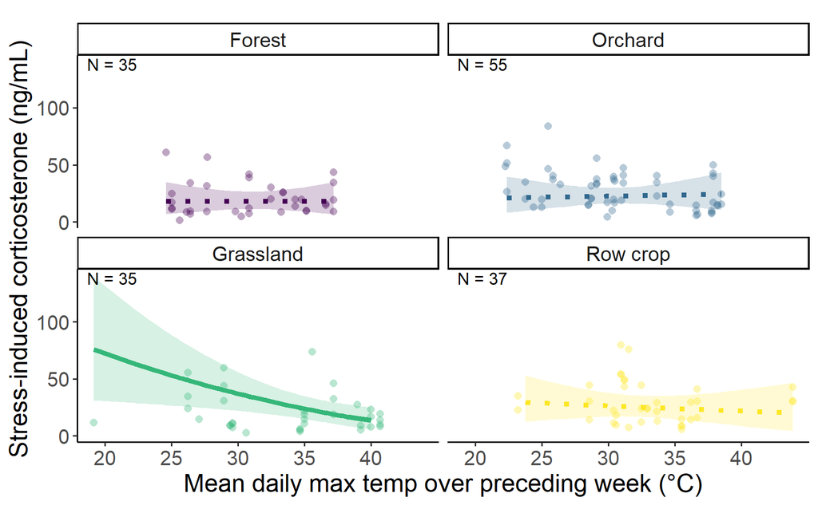

```r
samp_s2_webl <- s2_lintemp@frame %>% group_by(habitat) %>% summarize(count = n())
# samp_s2_webl %>% gt() %>% gtsave("figures/ss_webl_s2.html")


dat_text_s2_webl <- data.frame(
  label = paste("N =",samp_s2_webl$count),
  group   = factor(c("Forest","Orchard","Grassland","Row crop"))
)





data_s2_webl = dplyr::filter(g,Species == "WEBL",!is.na(meanmaxtempI),!is.na(meanmintempI)) %>%
  mutate(across(c(gweight,meanmaxtempI,meanmintempI,juliandate,brood_size,age),
                ~ scale(.x)[,1],
                .names = "{.col}_scaled"),
         meanmaxtempI_scaled_sq = meanmaxtempI_scaled * meanmaxtempI_scaled)


mean_temp_s2_webl <- mean(data_s2_webl %>% pull(meanmaxtempI))
sd_temp_s2_webl <- sd(data_s2_webl %>% pull(meanmaxtempI))


temp_trans_s2_webl <- trans_new("temp_trans_s2_webl",
                                transform = function(x){(x * sd_temp_s2_webl) + mean_temp_s2_webl},
                                inverse = function(x){x})

(fig_webl_s2 <- ggpredict(prior_model,terms = c("meanmaxtempI_scaled [all]","habitat"),bias_correction = TRUE) %>%
    plot(line_size = 1.5,alpha = .2,show_data = TRUE,limit_range = TRUE) +
    aes(linetype = .data[["group"]]) +
    theme_classic() +
    facet_wrap(~ group, ncol = 2) +
    xlab("Mean daily max temp over preceding week (\u00b0C)") +
    ylab("Stress-induced corticosterone (ng/mL)") +
    scale_fill_viridis(discrete = TRUE) +
    scale_color_viridis(discrete = TRUE) +
    theme(text = element_text(size = 16)) +
    labs(title = element_blank()) +
    scale_x_continuous(trans = temp_trans_s2_webl,
                       breaks = c((20-mean_temp_s2_webl)/sd_temp_s2_webl,
                                  (25-mean_temp_s2_webl)/sd_temp_s2_webl,
                                  (30-mean_temp_s2_webl)/sd_temp_s2_webl,
                                  (35-mean_temp_s2_webl)/sd_temp_s2_webl,
                                  (40-mean_temp_s2_webl)/sd_temp_s2_webl),
                       # breaks = c(20,30,40,50),
                       # labels = c("20","30","40","50"),
                       # limits = c((15-mean(g$meanmaxtempI,na.rm = TRUE))/sd(g$meanmaxtempI,na.rm = TRUE),
                       #            (55-mean(g$meanmaxtempI,na.rm = TRUE))/sd(g$meanmaxtempI,na.rm = TRUE))
                       # limits = c(18,5)
    ) +
    scale_linetype_manual(values = c("dotted","dotted","solid","dotted")) +
    #ylim(-5,5) +
    geom_text(data = dat_text_s2_webl, mapping = aes(x = -Inf, y = Inf,label = label),hjust = -.2, vjust = 1.2,inherit.aes = FALSE) +
    theme(legend.position = "none")
)
```

```
G3;Model has sqrt-transformed response. Back-transforming predictions to original response scale. Standard
  errors are still on the transformed scale.
gG3;Data points may overlap. Use the `jitter` argument to add some amount of random variation to the
  location of data points and avoid overplotting.
gScale for colour is already present.
```

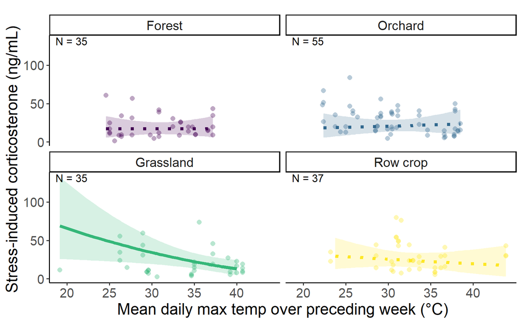

```r
(fig_webl_s2 <- ggpredict(s2_lintemp,terms = c("meanmaxtempI_scaled [all]","habitat"),bias_correction = TRUE) %>%
    plot(line_size = 1.5,alpha = .2,show_data = TRUE,limit_range = TRUE) +
    aes(linetype = .data[["group"]]) +
    theme_classic() +
    facet_wrap(~ group, ncol = 2) +
    xlab("Mean daily max temp over preceding week (\u00b0C)") +
    ylab("Stress-induced corticosterone (ng/mL)") +
    scale_fill_viridis(discrete = TRUE) +
    scale_color_viridis(discrete = TRUE) +
    theme(text = element_text(size = 16)) +
    labs(title = element_blank()) +
    scale_x_continuous(trans = temp_trans_s2_webl,
                       breaks = c((20-mean_temp_s2_webl)/sd_temp_s2_webl,
                                  (25-mean_temp_s2_webl)/sd_temp_s2_webl,
                                  (30-mean_temp_s2_webl)/sd_temp_s2_webl,
                                  (35-mean_temp_s2_webl)/sd_temp_s2_webl,
                                  (40-mean_temp_s2_webl)/sd_temp_s2_webl),
                       # breaks = c(20,30,40,50),
                       # labels = c("20","30","40","50"),
                       # limits = c((15-mean(g$meanmaxtempI,na.rm = TRUE))/sd(g$meanmaxtempI,na.rm = TRUE),
                       #            (55-mean(g$meanmaxtempI,na.rm = TRUE))/sd(g$meanmaxtempI,na.rm = TRUE))
                       # limits = c(18,5)
    ) +
    scale_linetype_manual(values = c("dotted","dotted","solid","dotted")) +
    #ylim(-5,5) +
    geom_text(data = dat_text_s2_webl, mapping = aes(x = -Inf, y = Inf,label = label),hjust = -.2, vjust = 1.2,inherit.aes = FALSE) +
    theme(legend.position = "none")
)
```

```
G3;Model has sqrt-transformed response. Back-transforming predictions to original response scale. Standard
  errors are still on the transformed scale.
gG3;Data points may overlap. Use the `jitter` argument to add some amount of random variation to the
  location of data points and avoid overplotting.
g
```

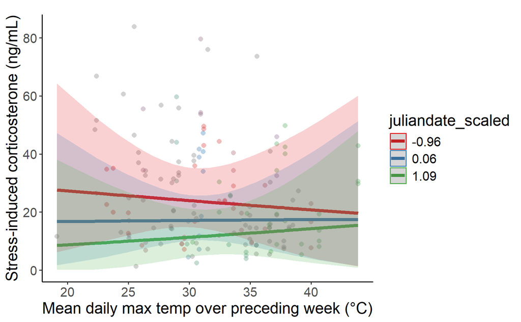

```r
(fig_webl_s2 <- ggpredict(s2_lintemp,terms = c("meanmaxtempI_scaled [all]","juliandate_scaled"),bias_correction = TRUE) %>%
    plot(line_size = 1.5,alpha = .2,show_data = TRUE,limit_range = TRUE) +
    # aes(linetype = .data[["group"]]) +
    theme_classic() +
    # facet_wrap(~ group, ncol = 2) +
    xlab("Mean daily max temp over preceding week (\u00b0C)") +
    ylab("Stress-induced corticosterone (ng/mL)") +
    # scale_fill_viridis(discrete = TRUE) +
    # scale_color_viridis(discrete = TRUE) +
    theme(text = element_text(size = 16)) +
    labs(title = element_blank()) +
    scale_x_continuous(trans = temp_trans_s2_webl,
                       breaks = c((20-mean_temp_s2_webl)/sd_temp_s2_webl,
                                  (25-mean_temp_s2_webl)/sd_temp_s2_webl,
                                  (30-mean_temp_s2_webl)/sd_temp_s2_webl,
                                  (35-mean_temp_s2_webl)/sd_temp_s2_webl,
                                  (40-mean_temp_s2_webl)/sd_temp_s2_webl),
                       # breaks = c(20,30,40,50),
                       # labels = c("20","30","40","50"),
                       # limits = c((15-mean(g$meanmaxtempI,na.rm = TRUE))/sd(g$meanmaxtempI,na.rm = TRUE),
                       #            (55-mean(g$meanmaxtempI,na.rm = TRUE))/sd(g$meanmaxtempI,na.rm = TRUE))
                       # limits = c(18,5)
    ) # +
    # scale_linetype_manual(values = c("dotted","dotted","solid","dotted")) +
    # #ylim(-5,5) +
    # geom_text(data = dat_text_s2_webl, mapping = aes(x = -Inf, y = Inf,label = label),hjust = -.2, vjust = 1.2,inherit.aes = FALSE) +
    # theme(legend.position = "none")
)
```

No interaction

#### TRES

```r
prior_model <- lmerTest::lmer(sqrt(cort_s2) ~ meanmaxtempI_scaled * habitat + meanmintempI_scaled + age_scaled + juliandate_scaled + year_fct + (1|attempt_id),data = dplyr::filter(g,Species == "TRES",!is.na(meanmaxtempI),!is.na(meanmintempI)) %>%
                                      mutate(across(c(gweight,meanmaxtempI,meanmintempI,juliandate,brood_size,age),
                                                    ~ scale(.x)[,1],
                                                    .names = "{.col}_scaled"),
                                             meanmaxtempI_scaled_sq = meanmaxtempI_scaled * meanmaxtempI_scaled))

s2_lintemp <- lmerTest::lmer(sqrt(cort_s2) ~ meanmaxtempI_scaled * habitat + meanmintempI_scaled * habitat + age_scaled + meanmaxtempI_scaled * juliandate_scaled + year_fct + (1|attempt_id),data = dplyr::filter(g,Species == "TRES",!is.na(meanmaxtempI),!is.na(meanmintempI)) %>%
                               mutate(across(c(gweight,meanmaxtempI,meanmintempI,juliandate,brood_size,age),
                                             ~ scale(.x)[,1],
                                             .names = "{.col}_scaled"),
                                      meanmaxtempI_scaled_sq = meanmaxtempI_scaled * meanmaxtempI_scaled))

s2_lintemp_addmax <- lmerTest::lmer(sqrt(cort_s2) ~ meanmaxtempI_scaled + meanmintempI_scaled * habitat + age_scaled + meanmaxtempI_scaled * juliandate_scaled + year_fct + (1|attempt_id),data = dplyr::filter(g,Species == "TRES",!is.na(meanmaxtempI),!is.na(meanmintempI)) %>%
                                      mutate(across(c(gweight,meanmaxtempI,meanmintempI,juliandate,brood_size,age),
                                                    ~ scale(.x)[,1],
                                                    .names = "{.col}_scaled"),
                                             meanmaxtempI_scaled_sq = meanmaxtempI_scaled * meanmaxtempI_scaled))

s2_lintemp_addmin <- lmerTest::lmer(sqrt(cort_s2) ~ meanmaxtempI_scaled * habitat + meanmintempI_scaled + age_scaled + meanmaxtempI_scaled * juliandate_scaled + year_fct + (1|attempt_id),data = dplyr::filter(g,Species == "TRES",!is.na(meanmaxtempI),!is.na(meanmintempI)) %>%
                                      mutate(across(c(gweight,meanmaxtempI,meanmintempI,juliandate,brood_size,age),
                                                    ~ scale(.x)[,1],
                                                    .names = "{.col}_scaled"),
                                             meanmaxtempI_scaled_sq = meanmaxtempI_scaled * meanmaxtempI_scaled))

s2_lintemp_noint <- lmerTest::lmer(sqrt(cort_s2) ~ meanmaxtempI_scaled + meanmintempI_scaled + habitat + age_scaled + meanmaxtempI_scaled * juliandate_scaled + year_fct + (1|attempt_id),data = dplyr::filter(g,Species == "TRES",!is.na(meanmaxtempI),!is.na(meanmintempI)) %>%
                                     mutate(across(c(gweight,meanmaxtempI,meanmintempI,juliandate,brood_size,age),
                                                   ~ scale(.x)[,1],
                                                   .names = "{.col}_scaled"),
                                            meanmaxtempI_scaled_sq = meanmaxtempI_scaled * meanmaxtempI_scaled))

c1 <- anova(s2_lintemp,s2_lintemp_addmin,s2_lintemp_noint) %>% tibble() %>% mutate(Model = c("no interaction","single interaction","both interacting"),.before = npar)
```

```
G3;refitting model(s) with ML (instead of REML)
g
```

```r
c2 <- anova(s2_lintemp,s2_lintemp_addmax,s2_lintemp_noint) %>% tibble() %>% mutate(Model = c("no interaction","single interaction","both interacting"),.before = npar)
```

```
G3;refitting model(s) with ML (instead of REML)
g
```

```r
(int_tab_s2_tres <- bind_rows(c1,c2) %>%
    as.tibble() %>%
    mutate(across(where(is.numeric),~round(.x,digits = 3)),
           P = `Pr(>Chisq)`) %>%
    dplyr::select(Model,AIC,Chisq,P) %>%
    mutate(max_or_min = c(rep("Max temp",times = 3),rep("Min temp",times = 3)),
           across(c(AIC,Chisq), ~ round(.x, digits = 2)),
           P = if_else(P < 0.001,"<0.001",as.character(P))) %>%
    group_by(max_or_min) %>% gt())
```

| Model | AIC | Chisq | P |
| --- | --- | --- | --- |
| Max temp |  |  |  |
| no interaction | 351.88 | NA | NA |
| single interaction | 347.64 | 10.24 | 0.017 |
| both interacting | 349.88 | 3.76 | 0.289 |
| Min temp |  |  |  |
| no interaction | 351.88 | NA | NA |
| single interaction | 356.22 | 1.66 | 0.646 |
| both interacting | 349.88 | 12.34 | 0.006 |

```r
# gtsave(int_tab_s2_tres,"figures/int_tab_s2_tres.html")

s2_tres <- s2_lintemp_addmin

summary(s2_lintemp_addmin)
```

```
Linear mixed model fit by REML. t-tests use Satterthwaite's method ['lmerModLmerTest']
Formula: sqrt(cort_s2) ~ meanmaxtempI_scaled * habitat + meanmintempI_scaled +
    age_scaled + meanmaxtempI_scaled * juliandate_scaled + year_fct +      (1 | attempt_id)
   Data: dplyr::filter(g, Species == "TRES", !is.na(meanmaxtempI), !is.na(meanmintempI)) %>%
    mutate(across(c(gweight, meanmaxtempI, meanmintempI, juliandate,
        brood_size, age), ~scale(.x)[, 1], .names = "{.col}_scaled"),
        meanmaxtempI_scaled_sq = meanmaxtempI_scaled * meanmaxtempI_scaled)

REML criterion at convergence: 318.1

Scaled residuals:
     Min       1Q   Median       3Q      Max
-1.98523 -0.52482  0.05419  0.48390  2.78941

Random effects:
 Groups     Name        Variance Std.Dev.
 attempt_id (Intercept) 0.4418   0.6646
 Residual               2.4431   1.5630
Number of obs: 86, groups:  attempt_id, 38

Fixed effects:
                                      Estimate Std. Error       df t value Pr(>|t|)
(Intercept)                            5.78734    1.10137 24.86882   5.255 1.96e-05 ***
meanmaxtempI_scaled                   -0.13856    0.79749 25.14618  -0.174   0.8635
habitatOrchard                        -0.67812    1.35152 23.36877  -0.502   0.6205
habitatGrassland                      -0.40767    1.11531 23.25685  -0.366   0.7180
habitatRow crop                        0.68003    1.10839 21.39809   0.614   0.5460
meanmintempI_scaled                   -0.28743    0.34734 19.64917  -0.828   0.4179
age_scaled                             0.58570    0.29573 39.72161   1.981   0.0546 .
juliandate_scaled                     -0.07137    0.26435 20.42010  -0.270   0.7899
year_fct2023                           0.39649    0.50323 17.74065   0.788   0.4412
meanmaxtempI_scaled:habitatOrchard    -1.54121    1.34328 23.59248  -1.147   0.2627
meanmaxtempI_scaled:habitatGrassland   1.96599    1.02449 21.47017   1.919   0.0684 .
meanmaxtempI_scaled:habitatRow crop    0.90468    1.08505 22.09866   0.834   0.4133
meanmaxtempI_scaled:juliandate_scaled -0.47650    0.36444 24.82763  -1.307   0.2030
---
Signif. codes:  0 '***' 0.001 '**' 0.01 '*' 0.05 '.' 0.1 ' ' 1
```

```
G3;
Correlation matrix not shown by default, as p = 13 > 12.
Use print(x, correlation=TRUE)  or
    vcov(x)        if you need it

g
```

```r
anova(s2_lintemp_addmin,prior_model)
```

```
G3;refitting model(s) with ML (instead of REML)
g
```

```
Data: dplyr::filter(g, Species == "TRES", !is.na(meanmaxtempI), !is.na(meanmintempI)) %>%  ...
Models:
prior_model: sqrt(cort_s2) ~ meanmaxtempI_scaled * habitat + meanmintempI_scaled + age_scaled + juliandate_scaled + year_fct + (1 | attempt_id)
s2_lintemp_addmin: sqrt(cort_s2) ~ meanmaxtempI_scaled * habitat + meanmintempI_scaled + age_scaled + meanmaxtempI_scaled * juliandate_scaled + year_fct + (1 | attempt_id)
                  npar    AIC    BIC  logLik deviance  Chisq Df Pr(>Chisq)
prior_model         14 348.00 382.37 -160.00   320.00
s2_lintemp_addmin   15 347.64 384.46 -158.82   317.64 2.3636  1     0.1242
```

Interaction is not significant, does not increase fit, does not change most parsimonious model

```r
(tress2trendmax_prior <- emtrends(prior_model,specs = ~ habitat, var = c("meanmaxtempI_scaled")) %>% test() %>%
    mutate(across(where(is.numeric), ~ round(.x, digits = 3)),
           df = round(df),
           p.value = if_else(p.value == 0.000,"<0.001",as.character(p.value))) %>%
    rename(Habitat = "habitat", `Max temp trend` = "meanmaxtempI_scaled.trend",Df = "df", `T-ratio` = "t.ratio", P = "p.value") %>%
    gt())
```

| Habitat | Max temp trend | SE | Df | T-ratio | P |
| --- | --- | --- | --- | --- | --- |
| Forest | 0.146 | 0.787 | 30 | 0.185 | 0.854 |
| Orchard | -1.377 | 1.125 | 25 | -1.223 | 0.233 |
| Grassland | 1.462 | 0.627 | 46 | 2.333 | 0.024 |
| Row crop | 0.239 | 0.563 | 31 | 0.425 | 0.674 |

```r
(tress2trendmax <- emtrends(s2_lintemp_addmin,specs = ~ habitat, var = c("meanmaxtempI_scaled")) %>% test() %>%
    mutate(across(where(is.numeric), ~ round(.x, digits = 3)),
           df = round(df),
           p.value = if_else(p.value == 0.000,"<0.001",as.character(p.value))) %>%
    rename(Habitat = "habitat", `Max temp trend` = "meanmaxtempI_scaled.trend",Df = "df", `T-ratio` = "t.ratio", P = "p.value") %>%
    gt())
```

| Habitat | Max temp trend | SE | Df | T-ratio | P |
| --- | --- | --- | --- | --- | --- |
| Forest | -0.271 | 0.845 | 26 | -0.321 | 0.751 |
| Orchard | -1.812 | 1.165 | 23 | -1.556 | 0.133 |
| Grassland | 1.695 | 0.643 | 34 | 2.636 | 0.013 |
| Row crop | 0.634 | 0.632 | 26 | 1.002 | 0.326 |

```
G3;Model has sqrt-transformed response. Back-transforming predictions to original response scale. Standard
  errors are still on the transformed scale.
gG3;Data points may overlap. Use the `jitter` argument to add some amount of random variation to the
  location of data points and avoid overplotting.
gScale for colour is already present.
```

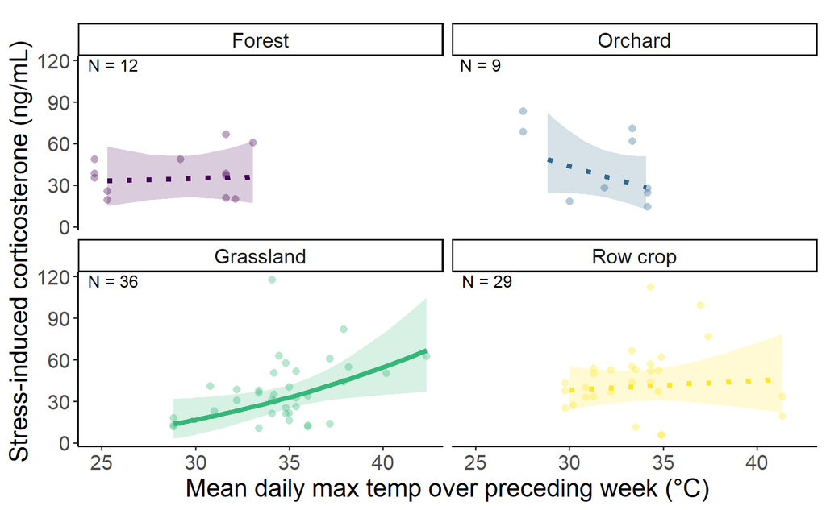

```r
samp_s2_tres <- s2_lintemp_addmin@frame %>% group_by(habitat) %>% summarize(count = n())
# samp %>% gt() %>% gtsave("figures/ss_tres_s2.html")


dat_text_s2_tres <- data.frame(
  label = paste("N =",samp_s2_tres$count),
  group   = factor(c("Forest","Orchard","Grassland","Row crop"))
)


data_s2_tres = dplyr::filter(g,Species == "TRES",!is.na(meanmaxtempI),!is.na(meanmintempI)) %>%
  mutate(across(c(gweight,meanmaxtempI,meanmintempI,juliandate,brood_size,age),
                ~ scale(.x)[,1],
                .names = "{.col}_scaled"),
         meanmaxtempI_scaled_sq = meanmaxtempI_scaled * meanmaxtempI_scaled)


mean_temp_s2_tres <- mean(data_s2_tres %>% pull(meanmaxtempI))
sd_temp_s2_tres <- sd(data_s2_tres %>% pull(meanmaxtempI))


temp_trans_s2_tres <- trans_new("temp_trans_s2_tres",
                                transform = function(x){(x * sd_temp_s2_tres) + mean_temp_s2_tres},
                                inverse = function(x){x})

(fig_tres_s2 <- ggpredict(prior_model,terms = c("meanmaxtempI_scaled [all]","habitat"),bias_correction = TRUE) %>%
    plot(line_size = 1.5,alpha = .2,show_data = TRUE,limit_range = TRUE) +
    aes(linetype = .data[["group"]]) +
    theme_classic() +
    facet_wrap(~ group, ncol = 2) +
    xlab("Mean daily max temp over preceding week (\u00b0C)") +
    ylab("Stress-induced corticosterone (ng/mL)") +
    scale_fill_viridis(discrete = TRUE) +
    scale_color_viridis(discrete = TRUE) +
    theme(text = element_text(size = 16)) +
    labs(title = element_blank()) +
    scale_x_continuous(trans = temp_trans_s2_tres,
                       breaks = c((20-mean_temp_s2_tres)/sd_temp_s2_tres,
                                  (25-mean_temp_s2_tres)/sd_temp_s2_tres,
                                  (30-mean_temp_s2_tres)/sd_temp_s2_tres,
                                  (35-mean_temp_s2_tres)/sd_temp_s2_tres,
                                  (40-mean_temp_s2_tres)/sd_temp_s2_tres),
                       # breaks = c(20,30,40,50),
                       # labels = c("20","30","40","50"),
                       # limits = c((15-mean(g$meanmaxtempI,na.rm = TRUE))/sd(g$meanmaxtempI,na.rm = TRUE),
                       #            (55-mean(g$meanmaxtempI,na.rm = TRUE))/sd(g$meanmaxtempI,na.rm = TRUE))
                       # limits = c(18,5)
    ) +
    scale_linetype_manual(values = c("dotted","dotted","solid","dotted")) +
    #ylim(-5,5) +
    geom_text(data = dat_text_s2_tres, mapping = aes(x = -Inf, y = Inf,label = label),hjust = -.2, vjust = 1.2,inherit.aes = FALSE) +
    theme(legend.position = "none")
)
```

```
G3;Model has sqrt-transformed response. Back-transforming predictions to original response scale. Standard
  errors are still on the transformed scale.
gG3;Data points may overlap. Use the `jitter` argument to add some amount of random variation to the
  location of data points and avoid overplotting.
gScale for colour is already present.
```

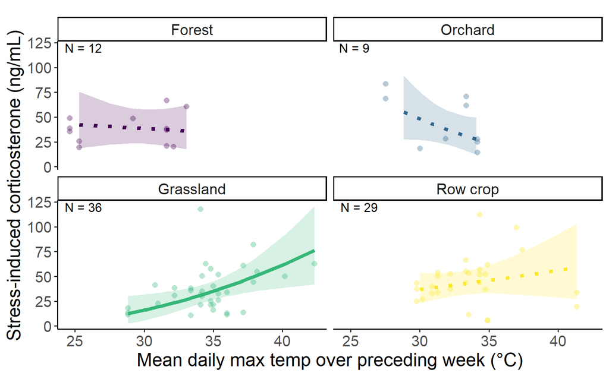

```r
(fig_tres_s2 <- ggpredict(s2_lintemp_addmin,terms = c("meanmaxtempI_scaled [all]","habitat"),bias_correction = TRUE) %>%
    plot(line_size = 1.5,alpha = .2,show_data = TRUE,limit_range = TRUE) +
    aes(linetype = .data[["group"]]) +
    theme_classic() +
    facet_wrap(~ group, ncol = 2) +
    xlab("Mean daily max temp over preceding week (\u00b0C)") +
    ylab("Stress-induced corticosterone (ng/mL)") +
    scale_fill_viridis(discrete = TRUE) +
    scale_color_viridis(discrete = TRUE) +
    theme(text = element_text(size = 16)) +
    labs(title = element_blank()) +
    scale_x_continuous(trans = temp_trans_s2_tres,
                       breaks = c((20-mean_temp_s2_tres)/sd_temp_s2_tres,
                                  (25-mean_temp_s2_tres)/sd_temp_s2_tres,
                                  (30-mean_temp_s2_tres)/sd_temp_s2_tres,
                                  (35-mean_temp_s2_tres)/sd_temp_s2_tres,
                                  (40-mean_temp_s2_tres)/sd_temp_s2_tres),
                       # breaks = c(20,30,40,50),
                       # labels = c("20","30","40","50"),
                       # limits = c((15-mean(g$meanmaxtempI,na.rm = TRUE))/sd(g$meanmaxtempI,na.rm = TRUE),
                       #            (55-mean(g$meanmaxtempI,na.rm = TRUE))/sd(g$meanmaxtempI,na.rm = TRUE))
                       # limits = c(18,5)
    ) +
    scale_linetype_manual(values = c("dotted","dotted","solid","dotted")) +
    #ylim(-5,5) +
    geom_text(data = dat_text_s2_tres, mapping = aes(x = -Inf, y = Inf,label = label),hjust = -.2, vjust = 1.2,inherit.aes = FALSE) +
    theme(legend.position = "none")
)
```

```
G3;Model has sqrt-transformed response. Back-transforming predictions to original response scale. Standard
  errors are still on the transformed scale.
gG3;Data points may overlap. Use the `jitter` argument to add some amount of random variation to the
  location of data points and avoid overplotting.
g
```

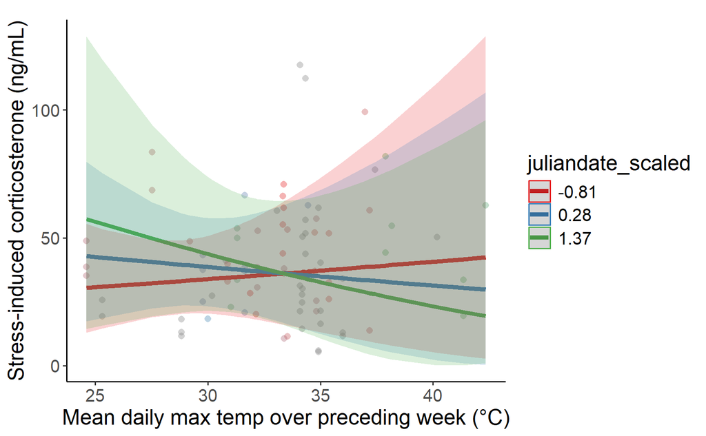

```r
(fig_tres_s2 <- ggpredict(s2_lintemp_addmin,terms = c("meanmaxtempI_scaled [all]","juliandate_scaled"),bias_correction = TRUE) %>%
    plot(line_size = 1.5,alpha = .2,show_data = TRUE,limit_range = TRUE) +
    # aes(linetype = .data[["group"]]) +
    theme_classic() +
    # facet_wrap(~ group, ncol = 2) +
    xlab("Mean daily max temp over preceding week (\u00b0C)") +
    ylab("Stress-induced corticosterone (ng/mL)") +
    # scale_fill_viridis(discrete = TRUE) +
    # scale_color_viridis(discrete = TRUE) +
    theme(text = element_text(size = 16)) +
    labs(title = element_blank()) +
    scale_x_continuous(trans = temp_trans_s2_tres,
                       breaks = c((20-mean_temp_s2_tres)/sd_temp_s2_tres,
                                  (25-mean_temp_s2_tres)/sd_temp_s2_tres,
                                  (30-mean_temp_s2_tres)/sd_temp_s2_tres,
                                  (35-mean_temp_s2_tres)/sd_temp_s2_tres,
                                  (40-mean_temp_s2_tres)/sd_temp_s2_tres),
                       # breaks = c(20,30,40,50),
                       # labels = c("20","30","40","50"),
                       # limits = c((15-mean(g$meanmaxtempI,na.rm = TRUE))/sd(g$meanmaxtempI,na.rm = TRUE),
                       #            (55-mean(g$meanmaxtempI,na.rm = TRUE))/sd(g$meanmaxtempI,na.rm = TRUE))
                       # limits = c(18,5)
    ) # +
    # scale_linetype_manual(values = c("dotted","dotted","solid","dotted")) +
    #ylim(-5,5) +
    # geom_text(data = dat_text_s2_tres, mapping = aes(x = -Inf, y = Inf,label = label),hjust = -.2, vjust = 1.2,inherit.aes = FALSE) +
    # theme(legend.position = "none")
)
```

Interaction is not significant.

### Baseline cort by prior day temp

#### WEBL

```r
prior_model <- lmerTest::lmer(sqrt(cort_s1) ~ maxt_prior_scaled + mint_prior_scaled * habitat + age_scaled + juliandate_scaled + year_fct + (1|attempt_id),data = dplyr::filter(g,Species == "WEBL",!is.na(maxt_prior),!is.na(mint_prior)) %>%
                                      mutate(across(c(gweight,maxt_prior,mint_prior,juliandate,brood_size,age),
                                                    ~ scale(.x)[,1],
                                                    .names = "{.col}_scaled"),
                                             maxt_prior_scaled_sq = maxt_prior_scaled * maxt_prior_scaled))

s1_lintemp <- lmerTest::lmer(sqrt(cort_s1) ~ maxt_prior_scaled * habitat + mint_prior_scaled * habitat + age_scaled + maxt_prior_scaled * juliandate_scaled + year_fct + (1|attempt_id),data = dplyr::filter(g,Species == "WEBL",!is.na(maxt_prior),!is.na(mint_prior)) %>%
                               mutate(across(c(gweight,maxt_prior,mint_prior,juliandate,brood_size,age),
                                             ~ scale(.x)[,1],
                                             .names = "{.col}_scaled"),
                                      maxt_prior_scaled_sq = maxt_prior_scaled * maxt_prior_scaled))

s1_lintemp_addmax <- lmerTest::lmer(sqrt(cort_s1) ~ maxt_prior_scaled + mint_prior_scaled * habitat + age_scaled + maxt_prior_scaled * juliandate_scaled + year_fct + (1|attempt_id),data = dplyr::filter(g,Species == "WEBL",!is.na(maxt_prior),!is.na(mint_prior)) %>%
                                      mutate(across(c(gweight,maxt_prior,mint_prior,juliandate,brood_size,age),
                                                    ~ scale(.x)[,1],
                                                    .names = "{.col}_scaled"),
                                             maxt_prior_scaled_sq = maxt_prior_scaled * maxt_prior_scaled))

s1_lintemp_addmin <- lmerTest::lmer(sqrt(cort_s1) ~ maxt_prior_scaled * habitat + mint_prior_scaled + age_scaled + maxt_prior_scaled * juliandate_scaled + year_fct + (1|attempt_id),data = dplyr::filter(g,Species == "WEBL",!is.na(maxt_prior),!is.na(mint_prior)) %>%
                                      mutate(across(c(gweight,maxt_prior,mint_prior,juliandate,brood_size,age),
                                                    ~ scale(.x)[,1],
                                                    .names = "{.col}_scaled"),
                                             maxt_prior_scaled_sq = maxt_prior_scaled * maxt_prior_scaled))

s1_lintemp_noint <- lmerTest::lmer(sqrt(cort_s1) ~ maxt_prior_scaled + mint_prior_scaled + habitat + age_scaled + maxt_prior_scaled * juliandate_scaled + year_fct + (1|attempt_id),data = dplyr::filter(g,Species == "WEBL",!is.na(maxt_prior),!is.na(mint_prior)) %>%
                                     mutate(across(c(gweight,maxt_prior,mint_prior,juliandate,brood_size,age),
                                                   ~ scale(.x)[,1],
                                                   .names = "{.col}_scaled"),
                                            maxt_prior_scaled_sq = maxt_prior_scaled * maxt_prior_scaled))

c1 <- anova(s1_lintemp,s1_lintemp_addmin,s1_lintemp_noint) %>% tibble() %>% mutate(Model = c("no interaction","single interaction","both interacting"),.before = npar)
```

```
G3;refitting model(s) with ML (instead of REML)
g
```

```r
c2 <- anova(s1_lintemp,s1_lintemp_addmax,s1_lintemp_noint) %>% tibble() %>% mutate(Model = c("no interaction","single interaction","both interacting"),.before = npar)
```

```
G3;refitting model(s) with ML (instead of REML)
g
```

```r
(int_tab_s1_priordayt_webl <- bind_rows(c1,c2) %>%
    as.tibble() %>%
    mutate(across(where(is.numeric),~round(.x,digits = 3)),
           P = `Pr(>Chisq)`) %>%
    dplyr::select(Model,AIC,Chisq,P) %>%
    mutate(max_or_min = c(rep("Max temp",times = 3),rep("Min temp",times = 3)),
           across(c(AIC,Chisq), ~ round(.x, digits = 2)),
           P = if_else(P < 0.001,"<0.001",as.character(P))) %>%
    group_by(max_or_min) %>% gt())
```

| Model | AIC | Chisq | P |
| --- | --- | --- | --- |
| Max temp |  |  |  |
| no interaction | 279.73 | NA | NA |
| single interaction | 281.37 | 4.36 | 0.225 |
| both interacting | 282.57 | 4.80 | 0.187 |
| Min temp |  |  |  |
| no interaction | 279.73 | NA | NA |
| single interaction | 278.44 | 7.29 | 0.063 |
| both interacting | 282.57 | 1.86 | 0.601 |

```r
# gtsave(int_tab_s1_priordayt_webl,"figures/int_tab_s1_priordayt_webl.html")

s1_prior_day_webl <- s1_lintemp_addmax

summary(s1_lintemp_addmax)
```

```
Linear mixed model fit by REML. t-tests use Satterthwaite's method ['lmerModLmerTest']
Formula: sqrt(cort_s1) ~ maxt_prior_scaled + mint_prior_scaled * habitat +
    age_scaled + maxt_prior_scaled * juliandate_scaled + year_fct +      (1 | attempt_id)
   Data: dplyr::filter(g, Species == "WEBL", !is.na(maxt_prior), !is.na(mint_prior)) %>%
    mutate(across(c(gweight, maxt_prior, mint_prior, juliandate,
        brood_size, age), ~scale(.x)[, 1], .names = "{.col}_scaled"),
        maxt_prior_scaled_sq = maxt_prior_scaled * maxt_prior_scaled)

REML criterion at convergence: 288.3

Scaled residuals:
    Min      1Q  Median      3Q     Max
-3.0129 -0.5704 -0.0164  0.5512  4.3501

Random effects:
 Groups     Name        Variance Std.Dev.
 attempt_id (Intercept) 0.08812  0.2969
 Residual               0.20387  0.4515
Number of obs: 175, groups:  attempt_id, 52

Fixed effects:
                                     Estimate Std. Error        df t value Pr(>|t|)
(Intercept)                           2.22601    0.12439  36.02964  17.895  < 2e-16 ***
maxt_prior_scaled                     0.07803    0.07177  94.29648   1.087  0.27969
mint_prior_scaled                     0.03307    0.09797 155.61091   0.338  0.73613
habitatOrchard                       -0.10195    0.15115  36.13959  -0.674  0.50429
habitatGrassland                     -0.23365    0.20911  42.86609  -1.117  0.27006
habitatRow crop                       0.09300    0.17300  35.16866   0.538  0.59425
age_scaled                            0.11270    0.04559 160.15909   2.472  0.01448 *
juliandate_scaled                    -0.19849    0.07310  55.19382  -2.715  0.00882 **
year_fct2023                          0.08222    0.13816  44.71265   0.595  0.55478
mint_prior_scaled:habitatOrchard      0.06630    0.11713 122.97420   0.566  0.57241
mint_prior_scaled:habitatGrassland   -0.55730    0.24521 153.06224  -2.273  0.02443 *
mint_prior_scaled:habitatRow crop    -0.02963    0.14540  79.21061  -0.204  0.83906
maxt_prior_scaled:juliandate_scaled   0.03343    0.05458  99.34196   0.612  0.54165
---
Signif. codes:  0 '***' 0.001 '**' 0.01 '*' 0.05 '.' 0.1 ' ' 1
```

```
G3;
Correlation matrix not shown by default, as p = 13 > 12.
Use print(x, correlation=TRUE)  or
    vcov(x)        if you need it

g
```

```r
anova(s1_lintemp_addmax,prior_model)
```

```
G3;refitting model(s) with ML (instead of REML)
g
```

```
Data: dplyr::filter(g, Species == "WEBL", !is.na(maxt_prior), !is.na(mint_prior)) %>%  ...
Models:
prior_model: sqrt(cort_s1) ~ maxt_prior_scaled + mint_prior_scaled * habitat + age_scaled + juliandate_scaled + year_fct + (1 | attempt_id)
s1_lintemp_addmax: sqrt(cort_s1) ~ maxt_prior_scaled + mint_prior_scaled * habitat + age_scaled + maxt_prior_scaled * juliandate_scaled + year_fct + (1 | attempt_id)
                  npar    AIC    BIC  logLik deviance  Chisq Df Pr(>Chisq)
prior_model         14 277.02 321.33 -124.51   249.02
s1_lintemp_addmax   15 278.44 325.91 -124.22   248.44 0.5816  1     0.4457
```

Interaction not significant, does not add to fit, does not change most parsimonious model

```r
(webls1_priordayt_trendmax_prior <- emtrends(prior_model,specs = ~ habitat, var = c("maxt_prior_scaled")) %>% test() %>%
    mutate(across(where(is.numeric), ~ round(.x, digits = 3)),
           df = round(df),
           p.value = if_else(p.value == 0.000,"<0.001",as.character(p.value))) %>%
    rename(Habitat = "habitat", `Max temp trend` = "maxt_prior_scaled.trend",Df = "df", `T-ratio` = "t.ratio", P = "p.value") %>%
    gt())
```

| Habitat | Max temp trend | SE | Df | T-ratio | P |
| --- | --- | --- | --- | --- | --- |
| Forest | 0.062 | 0.068 | 101 | 0.912 | 0.364 |
| Orchard | 0.062 | 0.068 | 101 | 0.912 | 0.364 |
| Grassland | 0.062 | 0.068 | 101 | 0.912 | 0.364 |
| Row crop | 0.062 | 0.068 | 101 | 0.912 | 0.364 |

```r
(webls1_priordayt_trendmax <- emtrends(s1_lintemp_addmax,specs = ~ habitat, var = c("maxt_prior_scaled")) %>% test() %>%
    mutate(across(where(is.numeric), ~ round(.x, digits = 3)),
           df = round(df),
           p.value = if_else(p.value == 0.000,"<0.001",as.character(p.value))) %>%
    rename(Habitat = "habitat", `Max temp trend` = "maxt_prior_scaled.trend",Df = "df", `T-ratio` = "t.ratio", P = "p.value") %>%
    gt())
```

| Habitat | Max temp trend | SE | Df | T-ratio | P |
| --- | --- | --- | --- | --- | --- |
| Forest | 0.079 | 0.074 | 103 | 1.076 | 0.284 |
| Orchard | 0.079 | 0.074 | 103 | 1.076 | 0.284 |
| Grassland | 0.079 | 0.074 | 103 | 1.076 | 0.284 |
| Row crop | 0.079 | 0.074 | 103 | 1.076 | 0.284 |

No change in trend or significance

```
G3;Model has sqrt-transformed response. Back-transforming predictions to original response scale. Standard
  errors are still on the transformed scale.
gG3;Data points may overlap. Use the `jitter` argument to add some amount of random variation to the
  location of data points and avoid overplotting.
gScale for colour is already present.
```

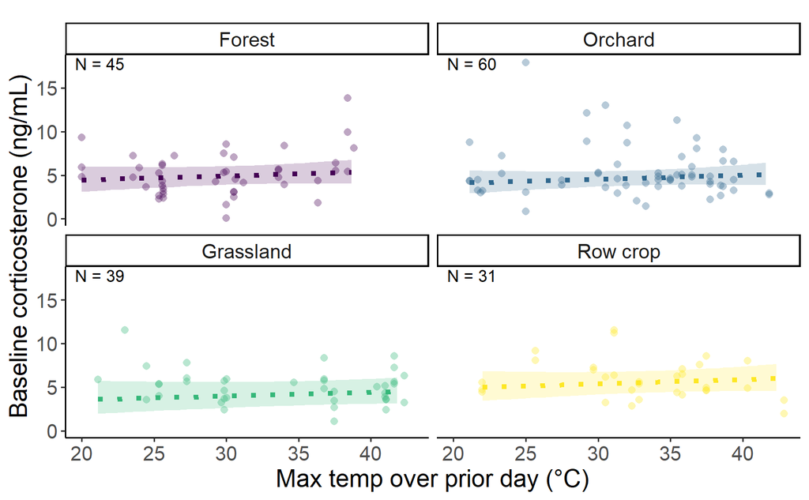

```r
samp_s1_priordayt_webl <- s1_lintemp_addmax@frame %>% group_by(habitat) %>% summarize(count = n())
# samp_s1_priordayt_webl %>% gt() %>% gtsave("figures/ss_webl_s1_priordayt_.html")


dat_text_s1_priordayt_webl <- data.frame(
  label = paste("N =",samp_s1_priordayt_webl$count),
  group   = factor(c("Forest","Orchard","Grassland","Row crop"))
)





data_s1_priordayt_webl = dplyr::filter(g,Species == "WEBL",!is.na(maxt_prior),!is.na(mint_prior)) %>%
  mutate(across(c(gweight,maxt_prior,mint_prior,juliandate,brood_size,age),
                ~ scale(.x)[,1],
                .names = "{.col}_scaled"),
         maxt_prior_scaled_sq = maxt_prior_scaled * maxt_prior_scaled)


mean_temp_s1_priordayt_webl <- mean(data_s1_priordayt_webl %>% pull(maxt_prior))
sd_temp_s1_priordayt_webl <- sd(data_s1_priordayt_webl %>% pull(maxt_prior))


temp_trans_s1_priordayt_webl <- trans_new("temp_trans_s1_priordayt_webl",
                                transform = function(x){(x * sd_temp_s1_priordayt_webl) + mean_temp_s1_priordayt_webl},
                                inverse = function(x){x})

(figs2_priordayt_webl <- ggpredict(prior_model,terms = c("maxt_prior_scaled [all]","habitat"),bias_correction = TRUE) %>%
    plot(line_size = 1.5,alpha = .2,show_data = TRUE,limit_range = TRUE) +
    aes(linetype = .data[["group"]]) +
    theme_classic() +
    facet_wrap(~ group, ncol = 2) +
    xlab("Max temp over prior day (\u00b0C)") +
    ylab("Baseline corticosterone (ng/mL)") +
    scale_fill_viridis(discrete = TRUE) +
    scale_color_viridis(discrete = TRUE) +
    theme(text = element_text(size = 16)) +
    labs(title = element_blank()) +
    scale_x_continuous(trans = temp_trans_s1_priordayt_webl,
                       breaks = c((20-mean_temp_s1_priordayt_webl)/sd_temp_s1_priordayt_webl,
                                  (25-mean_temp_s1_priordayt_webl)/sd_temp_s1_priordayt_webl,
                                  (30-mean_temp_s1_priordayt_webl)/sd_temp_s1_priordayt_webl,
                                  (35-mean_temp_s1_priordayt_webl)/sd_temp_s1_priordayt_webl,
                                  (40-mean_temp_s1_priordayt_webl)/sd_temp_s1_priordayt_webl),
                       # breaks = c(20,30,40,50),
                       # labels = c("20","30","40","50"),
                       # limits = c((15-mean(g$meanmaxtempI,na.rm = TRUE))/sd(g$meanmaxtempI,na.rm = TRUE),
                       #            (55-mean(g$meanmaxtempI,na.rm = TRUE))/sd(g$meanmaxtempI,na.rm = TRUE))
                       # limits = c(18,5)
    ) +
    scale_linetype_manual(values = c("dotted","dotted","dotted","dotted")) +
    #ylim(-5,5) +
    geom_text(data = dat_text_s1_priordayt_webl, mapping = aes(x = -Inf, y = Inf,label = label),hjust = -.2, vjust = 1.2,inherit.aes = FALSE) +
    theme(legend.position = "none")
)
```

```
G3;Model has sqrt-transformed response. Back-transforming predictions to original response scale. Standard
  errors are still on the transformed scale.
gG3;Data points may overlap. Use the `jitter` argument to add some amount of random variation to the
  location of data points and avoid overplotting.
gScale for colour is already present.
```

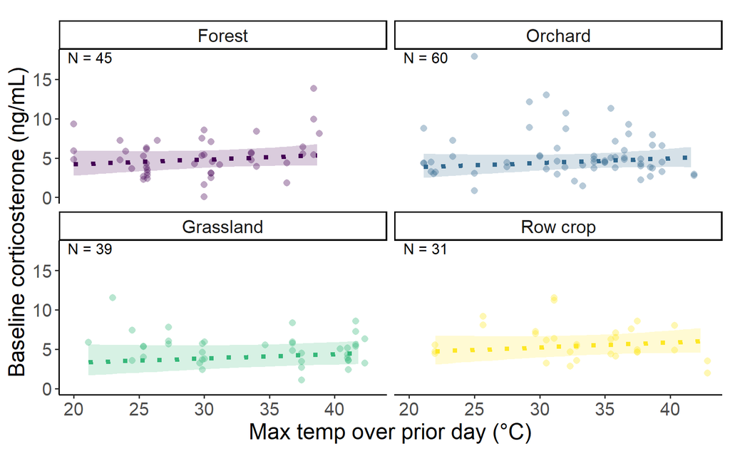

```r
(figs2_priordayt_webl <- ggpredict(s1_lintemp_addmax,terms = c("maxt_prior_scaled [all]","habitat"),bias_correction = TRUE) %>%
    plot(line_size = 1.5,alpha = .2,show_data = TRUE,limit_range = TRUE) +
    aes(linetype = .data[["group"]]) +
    theme_classic() +
    facet_wrap(~ group, ncol = 2) +
    xlab("Max temp over prior day (\u00b0C)") +
    ylab("Baseline corticosterone (ng/mL)") +
    scale_fill_viridis(discrete = TRUE) +
    scale_color_viridis(discrete = TRUE) +
    theme(text = element_text(size = 16)) +
    labs(title = element_blank()) +
    scale_x_continuous(trans = temp_trans_s1_priordayt_webl,
                       breaks = c((20-mean_temp_s1_priordayt_webl)/sd_temp_s1_priordayt_webl,
                                  (25-mean_temp_s1_priordayt_webl)/sd_temp_s1_priordayt_webl,
                                  (30-mean_temp_s1_priordayt_webl)/sd_temp_s1_priordayt_webl,
                                  (35-mean_temp_s1_priordayt_webl)/sd_temp_s1_priordayt_webl,
                                  (40-mean_temp_s1_priordayt_webl)/sd_temp_s1_priordayt_webl),
                       # breaks = c(20,30,40,50),
                       # labels = c("20","30","40","50"),
                       # limits = c((15-mean(g$meanmaxtempI,na.rm = TRUE))/sd(g$meanmaxtempI,na.rm = TRUE),
                       #            (55-mean(g$meanmaxtempI,na.rm = TRUE))/sd(g$meanmaxtempI,na.rm = TRUE))
                       # limits = c(18,5)
    ) +
    scale_linetype_manual(values = c("dotted","dotted","dotted","dotted")) +
    #ylim(-5,5) +
    geom_text(data = dat_text_s1_priordayt_webl, mapping = aes(x = -Inf, y = Inf,label = label),hjust = -.2, vjust = 1.2,inherit.aes = FALSE) +
    theme(legend.position = "none")
)
```

```
G3;Model has sqrt-transformed response. Back-transforming predictions to original response scale. Standard
  errors are still on the transformed scale.
gG3;Data points may overlap. Use the `jitter` argument to add some amount of random variation to the
  location of data points and avoid overplotting.
g
```

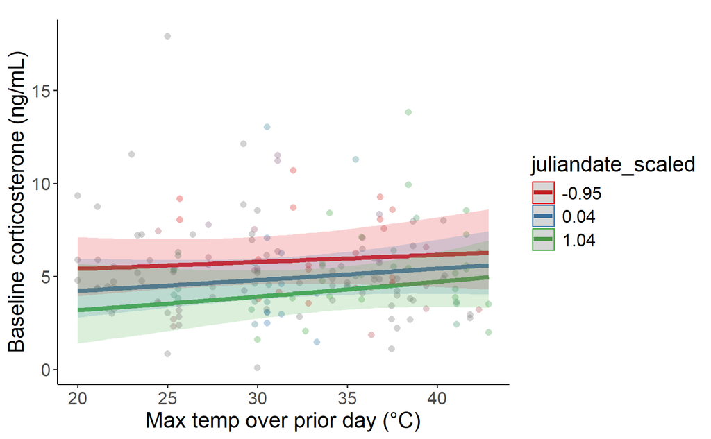

```r
(figs2_priordayt_webl <- ggpredict(s1_lintemp_addmax,terms = c("maxt_prior_scaled [all]","juliandate_scaled"),bias_correction = TRUE) %>%
    plot(line_size = 1.5,alpha = .2,show_data = TRUE,limit_range = TRUE) +
    # aes(linetype = .data[["group"]]) +
    theme_classic() +
    # facet_wrap(~ group, ncol = 2) +
    xlab("Max temp over prior day (\u00b0C)") +
    ylab("Baseline corticosterone (ng/mL)") +
    # scale_fill_viridis(discrete = TRUE) +
    # scale_color_viridis(discrete = TRUE) +
    theme(text = element_text(size = 16)) +
    labs(title = element_blank()) +
    scale_x_continuous(trans = temp_trans_s1_priordayt_webl,
                       breaks = c((20-mean_temp_s1_priordayt_webl)/sd_temp_s1_priordayt_webl,
                                  (25-mean_temp_s1_priordayt_webl)/sd_temp_s1_priordayt_webl,
                                  (30-mean_temp_s1_priordayt_webl)/sd_temp_s1_priordayt_webl,
                                  (35-mean_temp_s1_priordayt_webl)/sd_temp_s1_priordayt_webl,
                                  (40-mean_temp_s1_priordayt_webl)/sd_temp_s1_priordayt_webl),
                       # breaks = c(20,30,40,50),
                       # labels = c("20","30","40","50"),
                       # limits = c((15-mean(g$meanmaxtempI,na.rm = TRUE))/sd(g$meanmaxtempI,na.rm = TRUE),
                       #            (55-mean(g$meanmaxtempI,na.rm = TRUE))/sd(g$meanmaxtempI,na.rm = TRUE))
                       # limits = c(18,5)
    ) # +
    # scale_linetype_manual(values = c("dotted","dotted","dotted","dotted")) +
    # #ylim(-5,5) +
    # geom_text(data = dat_text_s1_priordayt_webl, mapping = aes(x = -Inf, y = Inf,label = label),hjust = -.2, vjust = 1.2,inherit.aes = FALSE) +
    # theme(legend.position = "none")
)
```

Interaction not significant

#### TRES

```r
prior_model <- lmerTest::lmer(sqrt(cort_s1) ~ maxt_prior_scaled + mint_prior_scaled * habitat + age_scaled + juliandate_scaled + year_fct + (1|attempt_id),data = dplyr::filter(g,Species == "TRES",!is.na(maxt_prior),!is.na(mint_prior)) %>%
                                      mutate(across(c(gweight,maxt_prior,mint_prior,juliandate,brood_size,age),
                                                    ~ scale(.x)[,1],
                                                    .names = "{.col}_scaled"),
                                             maxt_prior_scaled_sq = maxt_prior_scaled * maxt_prior_scaled))
```

```
G3;boundary (singular) fit: see help('isSingular')
g
```

```r
s1_lintemp <- lmerTest::lmer(sqrt(cort_s1) ~ maxt_prior_scaled * habitat + mint_prior_scaled * habitat + age_scaled + maxt_prior_scaled * juliandate_scaled + year_fct + (1|attempt_id),data = dplyr::filter(g,Species == "TRES",!is.na(maxt_prior),!is.na(mint_prior)) %>%
                               mutate(across(c(gweight,maxt_prior,mint_prior,juliandate,brood_size,age),
                                             ~ scale(.x)[,1],
                                             .names = "{.col}_scaled"),
                                      maxt_prior_scaled_sq = maxt_prior_scaled * maxt_prior_scaled))

s1_lintemp_addmax <- lmerTest::lmer(sqrt(cort_s1) ~ maxt_prior_scaled + mint_prior_scaled * habitat + age_scaled + maxt_prior_scaled * juliandate_scaled + year_fct + (1|attempt_id),data = dplyr::filter(g,Species == "TRES",!is.na(maxt_prior),!is.na(mint_prior)) %>%
                                      mutate(across(c(gweight,maxt_prior,mint_prior,juliandate,brood_size,age),
                                                    ~ scale(.x)[,1],
                                                    .names = "{.col}_scaled"),
                                             maxt_prior_scaled_sq = maxt_prior_scaled * maxt_prior_scaled))

s1_lintemp_addmin <- lmerTest::lmer(sqrt(cort_s1) ~ maxt_prior_scaled * habitat + mint_prior_scaled + age_scaled + maxt_prior_scaled * juliandate_scaled + year_fct + (1|attempt_id),data = dplyr::filter(g,Species == "TRES",!is.na(maxt_prior),!is.na(mint_prior)) %>%
                                      mutate(across(c(gweight,maxt_prior,mint_prior,juliandate,brood_size,age),
                                                    ~ scale(.x)[,1],
                                                    .names = "{.col}_scaled"),
                                             maxt_prior_scaled_sq = maxt_prior_scaled * maxt_prior_scaled))

s1_lintemp_noint <- lmerTest::lmer(sqrt(cort_s1) ~ maxt_prior_scaled + mint_prior_scaled + habitat + age_scaled + maxt_prior_scaled * juliandate_scaled + year_fct + (1|attempt_id),data = dplyr::filter(g,Species == "TRES",!is.na(maxt_prior),!is.na(mint_prior)) %>%
                                     mutate(across(c(gweight,maxt_prior,mint_prior,juliandate,brood_size,age),
                                                   ~ scale(.x)[,1],
                                                   .names = "{.col}_scaled"),
                                            maxt_prior_scaled_sq = maxt_prior_scaled * maxt_prior_scaled))

c1 <- anova(s1_lintemp,s1_lintemp_addmin,s1_lintemp_noint) %>% tibble() %>% mutate(Model = c("no interaction","single interaction","both interacting"),.before = npar)
```

```
G3;refitting model(s) with ML (instead of REML)
g
```

```r
c2 <- anova(s1_lintemp,s1_lintemp_addmax,s1_lintemp_noint) %>% tibble() %>% mutate(Model = c("no interaction","single interaction","both interacting"),.before = npar)
```

```
G3;refitting model(s) with ML (instead of REML)
g
```

```r
(int_tab_s1_priordayt_tres <- bind_rows(c1,c2) %>%
    as.tibble() %>%
    mutate(across(where(is.numeric),~round(.x,digits = 3)),
           P = `Pr(>Chisq)`) %>%
    dplyr::select(Model,AIC,Chisq,P) %>%
    mutate(max_or_min = c(rep("Max temp",times = 3),rep("Min temp",times = 3)),
           across(c(AIC,Chisq), ~ round(.x, digits = 2)),
           P = if_else(P < 0.001,"<0.001",as.character(P))) %>%
    group_by(max_or_min) %>% gt())
```

| Model | AIC | Chisq | P |
| --- | --- | --- | --- |
| Max temp |  |  |  |
| no interaction | 189.89 | NA | NA |
| single interaction | 190.17 | 5.72 | 0.126 |
| both interacting | 189.77 | 6.40 | 0.094 |
| Min temp |  |  |  |
| no interaction | 189.89 | NA | NA |
| single interaction | 185.92 | 9.97 | 0.019 |
| both interacting | 189.77 | 2.15 | 0.542 |

```r
# gtsave(int_tab_s1_priordayt_tres,"figures/int_tab_s1_priordayt_tres.html")

check_collinearity(s1_lintemp_noint)
```

```
# Check for Multicollinearity

Low Correlation

                                Term  VIF   VIF 95% CI Increased SE Tolerance Tolerance 95% CI
                   maxt_prior_scaled 2.32 [1.83, 3.10]         1.52      0.43     [0.32, 0.55]
                   mint_prior_scaled 1.90 [1.53, 2.52]         1.38      0.53     [0.40, 0.65]
                             habitat 1.56 [1.29, 2.06]         1.25      0.64     [0.49, 0.77]
                          age_scaled 1.23 [1.08, 1.67]         1.11      0.81     [0.60, 0.93]
                   juliandate_scaled 1.59 [1.32, 2.10]         1.26      0.63     [0.48, 0.76]
                            year_fct 1.62 [1.33, 2.14]         1.27      0.62     [0.47, 0.75]
 maxt_prior_scaled:juliandate_scaled 1.15 [1.03, 1.65]         1.07      0.87     [0.61, 0.97]
```

```r
s1_prior_day_tres <- s1_lintemp_addmin

summary(s1_lintemp_addmin)
```

```
Linear mixed model fit by REML. t-tests use Satterthwaite's method ['lmerModLmerTest']
Formula: sqrt(cort_s1) ~ maxt_prior_scaled * habitat + mint_prior_scaled +
    age_scaled + maxt_prior_scaled * juliandate_scaled + year_fct +      (1 | attempt_id)
   Data: dplyr::filter(g, Species == "TRES", !is.na(maxt_prior), !is.na(mint_prior)) %>%
    mutate(across(c(gweight, maxt_prior, mint_prior, juliandate,
        brood_size, age), ~scale(.x)[, 1], .names = "{.col}_scaled"),
        maxt_prior_scaled_sq = maxt_prior_scaled * maxt_prior_scaled)

REML criterion at convergence: 194.3

Scaled residuals:
     Min       1Q   Median       3Q      Max
-1.95603 -0.69922 -0.09299  0.70588  2.36506

Random effects:
 Groups     Name        Variance Std.Dev.
 attempt_id (Intercept) 0.03196  0.1788
 Residual               0.28304  0.5320
Number of obs: 105, groups:  attempt_id, 41

Fixed effects:
                                    Estimate Std. Error       df t value Pr(>|t|)
(Intercept)                          2.48060    0.30066 30.44917   8.251 2.93e-09 ***
maxt_prior_scaled                    0.05863    0.24476 37.84554   0.240   0.8120
habitatOrchard                      -0.23382    0.35398 30.80768  -0.661   0.5138
habitatGrassland                    -0.25410    0.30456 29.21192  -0.834   0.4109
habitatRow crop                     -0.01501    0.29775 27.70750  -0.050   0.9602
mint_prior_scaled                   -0.19970    0.09690 37.72912  -2.061   0.0463 *
age_scaled                          -0.01096    0.07646 73.69638  -0.143   0.8864
juliandate_scaled                    0.05832    0.07459 30.28372   0.782   0.4404
year_fct2023                         0.15856    0.16182 28.01251   0.980   0.3356
maxt_prior_scaled:habitatOrchard    -0.46424    0.33822 21.16964  -1.373   0.1842
maxt_prior_scaled:habitatGrassland   0.09143    0.25821 32.90547   0.354   0.7255
maxt_prior_scaled:habitatRow crop    0.12844    0.25019 31.95274   0.513   0.6112
maxt_prior_scaled:juliandate_scaled  0.09507    0.08499 40.51060   1.119   0.2699
---
Signif. codes:  0 '***' 0.001 '**' 0.01 '*' 0.05 '.' 0.1 ' ' 1
```

```
G3;
Correlation matrix not shown by default, as p = 13 > 12.
Use print(x, correlation=TRUE)  or
    vcov(x)        if you need it

g
```

```r
anova(s1_lintemp_addmax,prior_model)
```

```
G3;refitting model(s) with ML (instead of REML)
gG2;H2;Warningh in optwrap(optimizer, devfun, x@theta, lower = x@lower, calc.derivs = TRUE,  :
  convergence code 3 from bobyqa: bobyqa -- a trust region step failed to reduce qg
```

```
Data: dplyr::filter(g, Species == "TRES", !is.na(maxt_prior), !is.na(mint_prior)) %>%  ...
Models:
prior_model: sqrt(cort_s1) ~ maxt_prior_scaled + mint_prior_scaled * habitat + age_scaled + juliandate_scaled + year_fct + (1 | attempt_id)
s1_lintemp_addmax: sqrt(cort_s1) ~ maxt_prior_scaled + mint_prior_scaled * habitat + age_scaled + maxt_prior_scaled * juliandate_scaled + year_fct + (1 | attempt_id)
                  npar    AIC    BIC  logLik deviance Chisq Df Pr(>Chisq)
prior_model         14 184.90 222.05 -78.448   156.90
s1_lintemp_addmax   15 185.92 225.72 -77.958   155.92 0.981  1     0.3219
```

So this more clearly favors addmax. I’m going to change the manuscript to reflect this.

Interaction is not significant, does not increase fit.

```r
(tress1_priordayt_trendmax_prior <- emtrends(prior_model,specs = ~ habitat, var = c("maxt_prior_scaled")) %>% test() %>%
    mutate(across(where(is.numeric), ~ round(.x, digits = 3)),
           df = round(df),
           p.value = if_else(p.value == 0.000,"<0.001",as.character(p.value))) %>%
    rename(Habitat = "habitat", `Max temp trend` = "maxt_prior_scaled.trend",Df = "df", `T-ratio` = "t.ratio", P = "p.value") %>%
    gt())
```

| Habitat | Max temp trend | SE | Df | T-ratio | P |
| --- | --- | --- | --- | --- | --- |
| Forest | 0.196 | 0.094 | 50 | 2.08 | 0.043 |
| Orchard | 0.196 | 0.094 | 50 | 2.08 | 0.043 |
| Grassland | 0.196 | 0.094 | 50 | 2.08 | 0.043 |
| Row crop | 0.196 | 0.094 | 50 | 2.08 | 0.043 |

```r
(tress1_priordayt_trendmax <- emtrends(s1_lintemp_addmax,specs = ~ habitat, var = c("maxt_prior_scaled")) %>% test() %>%
    mutate(across(where(is.numeric), ~ round(.x, digits = 3)),
           df = round(df),
           p.value = if_else(p.value == 0.000,"<0.001",as.character(p.value))) %>%
    rename(Habitat = "habitat", `Max temp trend` = "maxt_prior_scaled.trend",Df = "df", `T-ratio` = "t.ratio", P = "p.value") %>%
    gt())
```

| Habitat | Max temp trend | SE | Df | T-ratio | P |
| --- | --- | --- | --- | --- | --- |
| Forest | 0.195 | 0.095 | 50 | 2.049 | 0.046 |
| Orchard | 0.195 | 0.095 | 50 | 2.049 | 0.046 |
| Grassland | 0.195 | 0.095 | 50 | 2.049 | 0.046 |
| Row crop | 0.195 | 0.095 | 50 | 2.049 | 0.046 |

[output not shown]

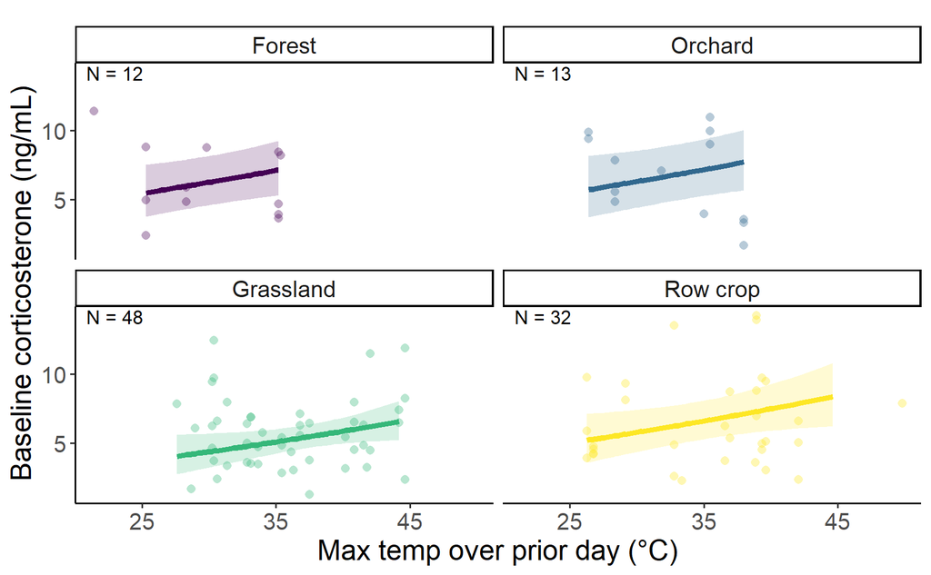

```r
samp_s1_priordayt_tres <- s1_lintemp_addmax@frame %>% group_by(habitat) %>% summarize(count = n())
# samp_s1_priordayt_tres %>% gt() %>% gtsave("figures/ss_tres_s1_priordayt_.html")


dat_text_s1_priordayt_tres <- data.frame(
  label = paste("N =",samp_s1_priordayt_tres$count),
  group   = factor(c("Forest","Orchard","Grassland","Row crop"))
)





data_s1_priordayt_tres = dplyr::filter(g,Species == "TRES",!is.na(maxt_prior),!is.na(mint_prior)) %>%
  mutate(across(c(gweight,maxt_prior,mint_prior,juliandate,brood_size,age),
                ~ scale(.x)[,1],
                .names = "{.col}_scaled"),
         maxt_prior_scaled_sq = maxt_prior_scaled * maxt_prior_scaled)


mean_temp_s1_priordayt_tres <- mean(data_s1_priordayt_tres %>% pull(maxt_prior))
sd_temp_s1_priordayt_tres <- sd(data_s1_priordayt_tres %>% pull(maxt_prior))


temp_trans_s1_priordayt_tres <- trans_new("temp_trans_s1_priordayt_tres",
                                          transform = function(x){(x * sd_temp_s1_priordayt_tres) + mean_temp_s1_priordayt_tres},
                                          inverse = function(x){x})

(figs2_priordayt_tres <- ggpredict(prior_model,terms = c("maxt_prior_scaled [all]","habitat"),bias_correction = TRUE) %>%
    plot(line_size = 1.5,alpha = .2,show_data = TRUE,limit_range = TRUE) +
    aes(linetype = .data[["group"]]) +
    theme_classic() +
    facet_wrap(~ group, ncol = 2) +
    xlab("Max temp over prior day (\u00b0C)") +
    ylab("Baseline corticosterone (ng/mL)") +
    scale_fill_viridis(discrete = TRUE) +
    scale_color_viridis(discrete = TRUE) +
    theme(text = element_text(size = 16)) +
    labs(title = element_blank()) +
    scale_x_continuous(trans = temp_trans_s1_priordayt_tres,
                       breaks = c((25-mean_temp_s1_priordayt_tres)/sd_temp_s1_priordayt_tres,
                                  (35-mean_temp_s1_priordayt_tres)/sd_temp_s1_priordayt_tres,
                                  (45-mean_temp_s1_priordayt_tres)/sd_temp_s1_priordayt_tres,
                                  (55-mean_temp_s1_priordayt_tres)/sd_temp_s1_priordayt_tres,
                                  (65-mean_temp_s1_priordayt_tres)/sd_temp_s1_priordayt_tres),
                       # breaks = c(20,30,40,50),
                       # labels = c("20","30","40","50"),
                       # limits = c((15-mean(g$meanmaxtempI,na.rm = TRUE))/sd(g$meanmaxtempI,na.rm = TRUE),
                       #            (55-mean(g$meanmaxtempI,na.rm = TRUE))/sd(g$meanmaxtempI,na.rm = TRUE))
                       # limits = c(18,5)
    ) +
    scale_linetype_manual(values = c("solid","solid","solid","solid")) +
    #ylim(-5,5) +
    geom_text(data = dat_text_s1_priordayt_tres, mapping = aes(x = -Inf, y = Inf,label = label),hjust = -.2, vjust = 1.2,inherit.aes = FALSE) +
    theme(legend.position = "none")
)
```